# Supporting Information 3

Daniel Y.M. Nakamura, Ward C. Wheeler, Taran Grant

2025-09-14

Phylogenetic analyses of extant taxa have relied mostly on DNA sequences. The proportion of phenomic characters relative to molecular characters has been reduced with the advent of massive parallel DNA sequencing. However, phenomic evidence enables sampling taxa without molecular data (such as fossils). Here we examine the impact of phenomic evidence on phylogenetic analyses dominated by DNA sequences. We answer five questions using 57 empirical data sets (22 with morphology-only taxa). First, are topologies impacted by the addition of phenomic evidence in TE trees relative to MOL trees? Second, are distances between MOL and TE topologies associated with the proportion of phenomic characters? Third, is the addition of phenomic evidence equally impactful on ML and MP topologies? Fourth, how do bootstrap values of shared clades differ between MOL and TE trees? Fifth, can we retrodict the occurrence (i.e. monophyly) of TE groups based on bootstrap values of MOL clades? These questions were assessed with and without fossils.

# Q1. Are topologies impacted by the addition of phenomic evidence?

Dataset with MOL-TE topological distances were calculated in script 1.

```r
# Load data
df <- read.csv("Dataset_R_q123_08-25.csv")

print("EXTANT: Number of datasets (extant) impacted by the addition of phenomic evidence")
```

```
## [1] "EXTANT: Number of datasets (extant) impacted by the addition of phenomic evidence"
```

```r
df_extant <- df %>% filter(grepl("Extant", Type)) # keep only extant datasets
print("MP MOL vs MP TE (number)")
```

```
## [1] "MP MOL vs MP TE (number)"
```

```r
sum(df_extant$MP_MOLvsTE_NormalizedRF > 0)
```

```
## [1] 50
```

```r
print("MP MOL vs MP TE (proportion)")
```

```
## [1] "MP MOL vs MP TE (proportion)"
```

```r
sum(df_extant$MP_MOLvsTE_NormalizedRF > 0) / nrow(df_extant)
```

```
## [1] 0.877193
```

```r
print("ML MOL vs ML TE ASC (number)")
```

```
## [1] "ML MOL vs ML TE ASC (number)"
```

```r
sum(df_extant$ML_MOLvsTEASC_NormalizedRF > 0)
```

```
## [1] 50
```

```r
print("ML MOL vs ML TE ASC (proportion)")
```

```
## [1] "ML MOL vs ML TE ASC (proportion)"
```

```r
sum(df_extant$ML_MOLvsTEASC_NormalizedRF > 0) / nrow(df_extant)
```

```
## [1] 0.877193
```

```r
print("ML MOL vs ML TE noASC")
```

```
## [1] "ML MOL vs ML TE noASC"
```

```r
sum(df_extant$ML_MOLvsTEnoASC_NormalizedRF > 0)
```

```
## [1] 49
```

```r
print("ML MOL vs ML TE noASC (proportion)")
```

```
## [1] "ML MOL vs ML TE noASC (proportion)"
```

```r
sum(df_extant$ML_MOLvsTEnoASC_NormalizedRF > 0) / nrow(df_extant)
```

```
## [1] 0.8596491
```

```r
print("EXTINCT: Number of datasets (extinct) impacted by the addition of phenomic evidence")
```

```
## [1] "EXTINCT: Number of datasets (extinct) impacted by the addition of phenomic evidence"
```

```r
df_extinct <- df %>% filter(grepl("Extinct", Type)) # keep only extant datasets
print("MP MOL vs MP TE (number)")
```

```
## [1] "MP MOL vs MP TE (number)"
```

```r
sum(df_extinct$MP_MOLvsTE_NormalizedRF > 0)
```

```
## [1] 21
```

```r
print("MP MOL vs MP TE (proportion)")
```

```
## [1] "MP MOL vs MP TE (proportion)"
```

```r
sum(df_extinct$MP_MOLvsTE_NormalizedRF > 0) / nrow(df_extinct)
```

```
## [1] 0.9545455
```

```r
print("ML MOL vs ML TE ASC (number)")
```

```
## [1] "ML MOL vs ML TE ASC (number)"
```

```r
sum(df_extinct$ML_MOLvsTEASC_NormalizedRF > 0)
```

```
## [1] 18
```

```r
print("ML MOL vs ML TE ASC (proportion)")
```

```
## [1] "ML MOL vs ML TE ASC (proportion)"
```

```r
sum(df_extinct$ML_MOLvsTEASC_NormalizedRF > 0) / nrow(df_extinct)
```

```
## [1] 0.8181818
```

```r
print("ML MOL vs ML TE noASC")
```

```
## [1] "ML MOL vs ML TE noASC"
```

```r
sum(df_extinct$ML_MOLvsTEnoASC_NormalizedRF > 0)
```

```
## [1] 18
```

```r
print("ML MOL vs ML TE noASC (proportion)")
```

```
## [1] "ML MOL vs ML TE noASC (proportion)"
```

```r
sum(df_extinct$ML_MOLvsTEnoASC_NormalizedRF > 0) / nrow(df_extinct)
```

```
## [1] 0.8181818
```

```r
print("EXTANT: Number of datasets (extant keeping the same datasets from extinct) impacted by the addition of phenomic evidence")
```

```
## [1] "EXTANT: Number of datasets (extant keeping the same datasets from extinct) impacted by the addition of phenomic evidence"
```

```r
df_filtered <- df[df$Dataset %in% df_extinct$Dataset, ]
df_filtered <- df_filtered %>% filter(grepl("Extant", Type)) # keep only extant datasets
print("MP MOL vs MP TE (number)")
```

```
## [1] "MP MOL vs MP TE (number)"
```

```r
sum(df_filtered$MP_MOLvsTE_NormalizedRF > 0)
```

```
## [1] 20
```

```r
print("MP MOL vs MP TE (proportion)")
```

```
## [1] "MP MOL vs MP TE (proportion)"
```

```r
sum(df_filtered$MP_MOLvsTE_NormalizedRF > 0) / nrow(df_filtered)
```

```
## [1] 0.9090909
```

```r
print("ML MOL vs ML TE ASC (number)")
```

```
## [1] "ML MOL vs ML TE ASC (number)"
```

```r
sum(df_filtered$ML_MOLvsTEASC_NormalizedRF > 0)
```

```
## [1] 20
```

```r
print("ML MOL vs ML TE ASC (proportion)")
```

```
## [1] "ML MOL vs ML TE ASC (proportion)"
```

```r
sum(df_filtered$ML_MOLvsTEASC_NormalizedRF > 0) / nrow(df_filtered)
```

```
## [1] 0.9090909
```

```r
print("ML MOL vs ML TE noASC")
```

```
## [1] "ML MOL vs ML TE noASC"
```

```r
sum(df_filtered$ML_MOLvsTEnoASC_NormalizedRF > 0)
```

```
## [1] 20
```

```r
print("ML MOL vs ML TE noASC (proportion)")
```

```
## [1] "ML MOL vs ML TE noASC (proportion)"
```

```r
sum(df_filtered$ML_MOLvsTEnoASC_NormalizedRF > 0) / nrow(df_filtered)
```

```
## [1] 0.9090909
```

## Q1.1 Data exploration

### Q1.1.1 Extant (Table 1)

Considering extant taxa (n = 57; see Table 1):

```r
print("1.a MP MOL vs MP TE")
```

```
## [1] "1.a MP MOL vs MP TE"
```

```r
print("No. shared clades")
```

```
## [1] "No. shared clades"
```

```r
mean(df_extant$MP_MOLvsTE_nSharedClades)
```

```
## [1] 44.84211
```

```r
sd(df_extant$MP_MOLvsTE_nSharedClades)
```

```
## [1] 52.64768
```

```r
range(df_extant$MP_MOLvsTE_nSharedClades)
```

```
## [1]   6 254
```

```r
print("No. unique MOL clades")
```

```
## [1] "No. unique MOL clades"
```

```r
mean(df_extant$MP_nUniqueCladesMOL)
```

```
## [1] 5.666667
```

```r
sd(df_extant$MP_nUniqueCladesMOL)
```

```
## [1] 6.415198
```

```r
range(df_extant$MP_nUniqueCladesMOL)
```

```
## [1]  0 24
```

```r
print("No. unique TE clades")
```

```
## [1] "No. unique TE clades"
```

```r
mean(df_extant$MP_nUniqueCladesTE)
```

```
## [1] 7.122807
```

```r
sd(df_extant$MP_nUniqueCladesTE)
```

```
## [1] 8.697434
```

```r
range(df_extant$MP_nUniqueCladesTE)
```

```
## [1]  0 37
```

```r
print("RF")
```

```
## [1] "RF"
```

```r
mean(df_extant$MP_MOLvsTE_NormalizedRF)
```

```
## [1] 0.1635157
```

```r
sd(df_extant$MP_MOLvsTE_NormalizedRF)
```

```
## [1] 0.1499367
```

```r
range(df_extant$MP_MOLvsTE_NormalizedRF)
```

```
## [1] 0.0000000 0.6666667
```

```r
print("CID")
```

```
## [1] "CID"
```

```r
mean(df_extant$MP_MOLvsTE_NormalizedCID)
```

```
## [1] 0.1464907
```

```r
sd(df_extant$MP_MOLvsTE_NormalizedCID)
```

```
## [1] 0.1351113
```

```r
range(df_extant$MP_MOLvsTE_NormalizedCID)
```

```
## [1] 0.0000000 0.7269341
```

```r
print("Mean SPR")
```

```
## [1] "Mean SPR"
```

```r
mean(as.numeric(df_extant$MP_MOLvsTE_NormalizedMeanSPR))
```

```
## [1] 0.1129238
```

```r
sd(as.numeric(df_extant$MP_MOLvsTE_NormalizedMeanSPR))
```

```
## [1] 0.08132133
```

```r
range(as.numeric(df_extant$MP_MOLvsTE_NormalizedMeanSPR))
```

```
## [1] 0.0000000 0.3739288
```

```r
print("Min SPR")
```

```
## [1] "Min SPR"
```

```r
mean(as.numeric(df_extant$MP_MOLvsTE_NormalizedMinSPR))
```

```
## [1] 0.07707913
```

```r
sd(as.numeric(df_extant$MP_MOLvsTE_NormalizedMinSPR))
```

```
## [1] 0.07804406
```

```r
range(as.numeric(df_extant$MP_MOLvsTE_NormalizedMinSPR))
```

```
## [1] 0.0000000 0.3739288
```

```r
print("Resolution MOL")
```

```
## [1] "Resolution MOL"
```

```r
mean(as.numeric(df_extant$MP_nPolytomiesMOL))
```

```
## [1] 3
```

```r
sd(as.numeric(df_extant$MP_nPolytomiesMOL))
```

```
## [1] 5.365232
```

```r
range(as.numeric(df_extant$MP_nPolytomiesMOL))
```

```
## [1]  0 31
```

```r
print("Resolution TE")
```

```
## [1] "Resolution TE"
```

```r
mean(as.numeric(df_extant$MP_nPolytomiesTE))
```

```
## [1] 2.614035
```

```r
sd(as.numeric(df_extant$MP_nPolytomiesTE))
```

```
## [1] 4.566002
```

```r
range(as.numeric(df_extant$MP_nPolytomiesTE))
```

```
## [1]  0 30
```

```r
cat("\n1.b ML MOL vs ML TE MKv")
```

```
##
## 1.b ML MOL vs ML TE MKv
```

```r
print("No. shared clades")
```

```
## [1] "No. shared clades"
```

```r
mean(df_extant$ML_MOLvsTEASC_nSharedClades)
```

```
## [1] 48.59649
```

```r
sd(df_extant$ML_MOLvsTEASC_nSharedClades)
```

```
## [1] 57.00121
```

```r
range(df_extant$ML_MOLvsTEASC_nSharedClades)
```

```
## [1]   3 296
```

```r
print("No. unique MOL clades")
```

```
## [1] "No. unique MOL clades"
```

```r
mean(df_extant$ML_MOLvsTEASC_nUniqueCladesMOL)
```

```
## [1] 8.280702
```

```r
sd(df_extant$ML_MOLvsTEASC_nUniqueCladesMOL)
```

```
## [1] 10.0796
```

```r
range(df_extant$ML_MOLvsTEASC_nUniqueCladesMOL)
```

```
## [1]  0 48
```

```r
print("No. unique TE clades")
```

```
## [1] "No. unique TE clades"
```

```r
mean(df_extant$ML_MOLvsTEASC_nUniqueCladesTEASC)
```

```
## [1] 8.280702
```

```r
sd(df_extant$ML_MOLvsTEASC_nUniqueCladesTEASC)
```

```
## [1] 10.0796
```

```r
range(df_extant$ML_MOLvsTEASC_nUniqueCladesTEASC)
```

```
## [1]  0 48
```

```r
print("RF")
```

```
## [1] "RF"
```

```r
mean(df_extant$ML_MOLvsTEASC_NormalizedRF)
```

```
## [1] 0.1575237
```

```r
sd(df_extant$ML_MOLvsTEASC_NormalizedRF)
```

```
## [1] 0.1525213
```

```r
range(df_extant$ML_MOLvsTEASC_NormalizedRF)
```

```
## [1] 0.0000000 0.8333333
```

```r
print("CID")
```

```
## [1] "CID"
```

```r
mean(df_extant$ML_MOLvsTEASC_NormalizedCID)
```

```
## [1] 0.1085543
```

```r
sd(df_extant$ML_MOLvsTEASC_NormalizedCID)
```

```
## [1] 0.1031619
```

```r
range(df_extant$ML_MOLvsTEASC_NormalizedCID)
```

```
## [1] 0.0000000 0.6194234
```

```r
print("SPR")
```

```
## [1] "SPR"
```

```r
mean(as.numeric(df_extant$ML_MOLvsTEASC_NormalizedMeanSPR))
```

```
## [1] 0.1078196
```

```r
sd(as.numeric(df_extant$ML_MOLvsTEASC_NormalizedMeanSPR))
```

```
## [1] 0.08249941
```

```r
range(as.numeric(df_extant$ML_MOLvsTEASC_NormalizedMeanSPR))
```

```
## [1] 0.0000000 0.3739288
```

```r
cat("\n1.c MLmol_MLteNoAsc")
```

```
##
## 1.c MLmol_MLteNoAsc
```

```r
print("No. shared clades")
```

```
## [1] "No. shared clades"
```

```r
mean(df_extant$ML_MOLvsTEnoASC_nSharedClades)
```

```
## [1] 48.36842
```

```r
sd(df_extant$ML_MOLvsTEnoASC_nSharedClades)
```

```
## [1] 56.54664
```

```r
range(df_extant$ML_MOLvsTEnoASC_nSharedClades)
```

```
## [1]   3 296
```

```r
print("No. unique MOL clades")
```

```
## [1] "No. unique MOL clades"
```

```r
mean(df_extant$ML_MOLvsTEnoASC_nUniqueCladesMOL)
```

```
## [1] 8.421053
```

```r
sd(df_extant$ML_MOLvsTEnoASC_nUniqueCladesMOL)
```

```
## [1] 11.04528
```

```r
range(df_extant$ML_MOLvsTEnoASC_nUniqueCladesMOL)
```

```
## [1]  0 54
```

```r
print("No. unique TE clades")
```

```
## [1] "No. unique TE clades"
```

```r
mean(df_extant$ML_MOLvsTEnoASC_nUniqueCladesTEnoASC)
```

```
## [1] 8.421053
```

```r
sd(df_extant$ML_MOLvsTEnoASC_nUniqueCladesTEnoASC)
```

```
## [1] 11.04528
```

```r
range(df_extant$ML_MOLvsTEnoASC_nUniqueCladesTEnoASC)
```

```
## [1]  0 54
```

```r
print("RF")
```

```
## [1] "RF"
```

```r
mean(df_extant$ML_MOLvsTEnoASC_NormalizedRF)
```

```
## [1] 0.1533111
```

```r
sd(df_extant$ML_MOLvsTEnoASC_NormalizedRF)
```

```
## [1] 0.1556072
```

```r
range(df_extant$ML_MOLvsTEnoASC_NormalizedRF)
```

```
## [1] 0.0000000 0.8333333
```

```r
print("CID")
```

```
## [1] "CID"
```

```r
mean(df_extant$ML_MOLvsTEnoASC_NormalizedCID)
```

```
## [1] 0.1060566
```

```r
sd(df_extant$ML_MOLvsTEnoASC_NormalizedCID)
```

```
## [1] 0.106644
```

```r
range(df_extant$ML_MOLvsTEnoASC_NormalizedCID)
```

```
## [1] 0.0000000 0.6504732
```

```r
print("SPR")
```

```
## [1] "SPR"
```

```r
mean(as.numeric(df_extant$ML_MOLvsTEnoASC_NormalizedMeanSPR))
```

```
## [1] 0.1052421
```

```r
sd(as.numeric(df_extant$ML_MOLvsTEnoASC_NormalizedMeanSPR))
```

```
## [1] 0.08998568
```

```r
range(as.numeric(df_extant$ML_MOLvsTEnoASC_NormalizedMeanSPR))
```

```
## [1] 0.000000 0.467411
```

### Q1.1.2 Extant + Extinct (Table 1)

```r
print("1.a MP MOL vs MP TE")
```

```
## [1] "1.a MP MOL vs MP TE"
```

```r
print("No. shared clades")
```

```
## [1] "No. shared clades"
```

```r
mean(df_extinct$MP_MOLvsTE_nSharedClades)
```

```
## [1] 34.5
```

```r
sd(df_extinct$MP_MOLvsTE_nSharedClades)
```

```
## [1] 42.09824
```

```r
range(df_extinct$MP_MOLvsTE_nSharedClades)
```

```
## [1]   2 188
```

```r
print("No. unique MOL clades")
```

```
## [1] "No. unique MOL clades"
```

```r
mean(df_extinct$MP_nUniqueCladesMOL)
```

```
## [1] 14.77273
```

```r
sd(df_extinct$MP_nUniqueCladesMOL)
```

```
## [1] 15.56838
```

```r
range(df_extinct$MP_nUniqueCladesMOL)
```

```
## [1]  0 56
```

```r
print("No. unique TE clades")
```

```
## [1] "No. unique TE clades"
```

```r
mean(df_extinct$MP_nUniqueCladesTE)
```

```
## [1] 4.227273
```

```r
sd(df_extinct$MP_nUniqueCladesTE)
```

```
## [1] 6.589543
```

```r
range(df_extinct$MP_nUniqueCladesTE)
```

```
## [1]  0 28
```

```r
print("RF")
```

```
## [1] "RF"
```

```r
mean(df_extinct$MP_MOLvsTE_NormalizedRF)
```

```
## [1] 0.3023861
```

```r
sd(df_extinct$MP_MOLvsTE_NormalizedRF)
```

```
## [1] 0.2882222
```

```r
range(df_extinct$MP_MOLvsTE_NormalizedRF)
```

```
## [1] 0 1
```

```r
print("CID")
```

```
## [1] "CID"
```

```r
mean(df_extinct$MP_MOLvsTE_NormalizedCID)
```

```
## [1] 0.3059918
```

```r
sd(df_extinct$MP_MOLvsTE_NormalizedCID)
```

```
## [1] 0.2901222
```

```r
range(df_extinct$MP_MOLvsTE_NormalizedCID)
```

```
## [1] 0 1
```

```r
print("Mean SPR")
```

```
## [1] "Mean SPR"
```

```r
mean(as.numeric(df_extinct$MP_MOLvsTE_NormalizedMeanSPR))
```

```
## [1] 0.1001774
```

```r
sd(as.numeric(df_extinct$MP_MOLvsTE_NormalizedMeanSPR))
```

```
## [1] 0.07991712
```

```r
range(as.numeric(df_extinct$MP_MOLvsTE_NormalizedMeanSPR))
```

```
## [1] 0.0000000 0.3293895
```

```r
print("Min SPR")
```

```
## [1] "Min SPR"
```

```r
mean(as.numeric(df_extinct$MP_MOLvsTE_NormalizedMinSPR))
```

```
## [1] 0.07986902
```

```r
sd(as.numeric(df_extinct$MP_MOLvsTE_NormalizedMinSPR))
```

```
## [1] 0.07714903
```

```r
range(as.numeric(df_extinct$MP_MOLvsTE_NormalizedMinSPR))
```

```
## [1] 0.0000000 0.3217293
```

```r
print("Resolution MOL")
```

```
## [1] "Resolution MOL"
```

```r
mean(as.numeric(df_extinct$MP_nPolytomiesMOL))
```

```
## [1] 1.5
```

```r
sd(as.numeric(df_extinct$MP_nPolytomiesMOL))
```

```
## [1] 2.558832
```

```r
range(as.numeric(df_extinct$MP_nPolytomiesMOL))
```

```
## [1]  0 11
```

```r
print("Resolution TE")
```

```
## [1] "Resolution TE"
```

```r
mean(as.numeric(df_extinct$MP_nPolytomiesTE))
```

```
## [1] 3.818182
```

```r
sd(as.numeric(df_extinct$MP_nPolytomiesTE))
```

```
## [1] 3.049377
```

```r
range(as.numeric(df_extinct$MP_nPolytomiesTE))
```

```
## [1]  0 11
```

```r
cat("\n1.b ML MOL vs ML TE MKv")
```

```
##
## 1.b ML MOL vs ML TE MKv
```

```r
print("No. shared clades")
```

```
## [1] "No. shared clades"
```

```r
mean(df_extinct$ML_MOLvsTEASC_nSharedClades)
```

```
## [1] 44.27273
```

```r
sd(df_extinct$ML_MOLvsTEASC_nSharedClades)
```

```
## [1] 51.8268
```

```r
range(df_extinct$ML_MOLvsTEASC_nSharedClades)
```

```
## [1]   6 254
```

```r
print("No. unique MOL clades")
```

```
## [1] "No. unique MOL clades"
```

```r
mean(df_extinct$ML_MOLvsTEASC_nUniqueCladesMOL)
```

```
## [1] 7.954545
```

```r
sd(df_extinct$ML_MOLvsTEASC_nUniqueCladesMOL)
```

```
## [1] 9.291457
```

```r
range(df_extinct$ML_MOLvsTEASC_nUniqueCladesMOL)
```

```
## [1]  0 36
```

```r
print("No. unique TE clades")
```

```
## [1] "No. unique TE clades"
```

```r
mean(df_extinct$ML_MOLvsTEASC_nUniqueCladesTEASC)
```

```
## [1] 8.272727
```

```r
sd(df_extinct$ML_MOLvsTEASC_nUniqueCladesTEASC)
```

```
## [1] 9.452547
```

```r
range(df_extinct$ML_MOLvsTEASC_nUniqueCladesTEASC)
```

```
## [1]  0 37
```

```r
print("RF")
```

```
## [1] "RF"
```

```r
mean(df_extinct$ML_MOLvsTEASC_NormalizedRF)
```

```
## [1] 0.1551199
```

```r
sd(df_extinct$ML_MOLvsTEASC_NormalizedRF)
```

```
## [1] 0.1601393
```

```r
range(df_extinct$ML_MOLvsTEASC_NormalizedRF)
```

```
## [1] 0.000 0.625
```

```r
print("CID")
```

```
## [1] "CID"
```

```r
mean(df_extinct$ML_MOLvsTEASC_NormalizedCID)
```

```
## [1] 0.1040198
```

```r
sd(df_extinct$ML_MOLvsTEASC_NormalizedCID)
```

```
## [1] 0.09278641
```

```r
range(df_extinct$ML_MOLvsTEASC_NormalizedCID)
```

```
## [1] 0.0000000 0.2943385
```

```r
print("SPR")
```

```
## [1] "SPR"
```

```r
mean(as.numeric(df_extinct$ML_MOLvsTEASC_NormalizedMeanSPR))
```

```
## [1] 0.1041103
```

```r
sd(as.numeric(df_extinct$ML_MOLvsTEASC_NormalizedMeanSPR))
```

```
## [1] 0.08862956
```

```r
range(as.numeric(df_extinct$ML_MOLvsTEASC_NormalizedMeanSPR))
```

```
## [1] 0.0000000 0.2949185
```

```r
cat("\n1.c MLmol_MLteNoAsc")
```

```
##
## 1.c MLmol_MLteNoAsc
```

```r
print("No. shared clades")
```

```
## [1] "No. shared clades"
```

```r
mean(df_extinct$ML_MOLvsTEnoASC_nSharedClades)
```

```
## [1] 44.72727
```

```r
sd(df_extinct$ML_MOLvsTEnoASC_nSharedClades)
```

```
## [1] 52.00291
```

```r
range(df_extinct$ML_MOLvsTEnoASC_nSharedClades)
```

```
## [1]   6 254
```

```r
print("No. unique MOL clades")
```

```
## [1] "No. unique MOL clades"
```

```r
mean(df_extinct$ML_MOLvsTEnoASC_nUniqueCladesMOL)
```

```
## [1] 7.5
```

```r
sd(df_extinct$ML_MOLvsTEnoASC_nUniqueCladesMOL)
```

```
## [1] 9.059328
```

```r
range(df_extinct$ML_MOLvsTEnoASC_nUniqueCladesMOL)
```

```
## [1]  0 35
```

```r
print("No. unique TE clades")
```

```
## [1] "No. unique TE clades"
```

```r
mean(df_extinct$ML_MOLvsTEnoASC_nUniqueCladesTEnoASC)
```

```
## [1] 7.772727
```

```r
sd(df_extinct$ML_MOLvsTEnoASC_nUniqueCladesTEnoASC)
```

```
## [1] 9.19074
```

```r
range(df_extinct$ML_MOLvsTEnoASC_nUniqueCladesTEnoASC)
```

```
## [1]  0 36
```

```r
print("RF")
```

```
## [1] "RF"
```

```r
mean(df_extinct$ML_MOLvsTEnoASC_NormalizedRF)
```

```
## [1] 0.1499259
```

```r
sd(df_extinct$ML_MOLvsTEnoASC_NormalizedRF)
```

```
## [1] 0.1545081
```

```r
range(df_extinct$ML_MOLvsTEnoASC_NormalizedRF)
```

```
## [1] 0.0 0.6
```

```r
print("CID")
```

```
## [1] "CID"
```

```r
mean(df_extinct$ML_MOLvsTEnoASC_NormalizedCID)
```

```
## [1] 0.1019502
```

```r
sd(df_extinct$ML_MOLvsTEnoASC_NormalizedCID)
```

```
## [1] 0.09132746
```

```r
range(df_extinct$ML_MOLvsTEnoASC_NormalizedCID)
```

```
## [1] 0.0000000 0.2915632
```

```r
print("SPR")
```

```
## [1] "SPR"
```

```r
mean(as.numeric(df_extinct$ML_MOLvsTEnoASC_NormalizedMeanSPR))
```

```
## [1] 0.1030257
```

```r
sd(as.numeric(df_extinct$ML_MOLvsTEnoASC_NormalizedMeanSPR))
```

```
## [1] 0.09188593
```

```r
range(as.numeric(df_extinct$ML_MOLvsTEnoASC_NormalizedMeanSPR))
```

```
## [1] 0.0000000 0.3217293
```

### Q1.1.3 Reduced (Table S10)

Considering only extant taxa in datasets where extinct taxa are available (n = 22):

```r
print("1.a MP MOL vs MP TE")
```

```
## [1] "1.a MP MOL vs MP TE"
```

```r
print("No. shared clades")
```

```
## [1] "No. shared clades"
```

```r
mean(df_filtered$MP_MOLvsTE_nSharedClades)
```

```
## [1] 42.31818
```

```r
sd(df_filtered$MP_MOLvsTE_nSharedClades)
```

```
## [1] 48.31975
```

```r
range(df_filtered$MP_MOLvsTE_nSharedClades)
```

```
## [1]   7 234
```

```r
print("No. unique MOL clades")
```

```
## [1] "No. unique MOL clades"
```

```r
mean(df_filtered$MP_nUniqueCladesMOL)
```

```
## [1] 6.954545
```

```r
sd(df_filtered$MP_nUniqueCladesMOL)
```

```
## [1] 7.033778
```

```r
range(df_filtered$MP_nUniqueCladesMOL)
```

```
## [1]  0 24
```

```r
print("No. unique TE clades")
```

```
## [1] "No. unique TE clades"
```

```r
mean(df_filtered$MP_nUniqueCladesTE)
```

```
## [1] 7.090909
```

```r
sd(df_filtered$MP_nUniqueCladesTE)
```

```
## [1] 7.782209
```

```r
range(df_filtered$MP_nUniqueCladesTE)
```

```
## [1]  0 23
```

```r
print("RF")
```

```
## [1] "RF"
```

```r
mean(df_filtered$MP_MOLvsTE_NormalizedRF)
```

```
## [1] 0.1681103
```

```r
sd(df_filtered$MP_MOLvsTE_NormalizedRF)
```

```
## [1] 0.1473089
```

```r
range(df_filtered$MP_MOLvsTE_NormalizedRF)
```

```
## [1] 0.0000000 0.5897436
```

```r
print("CID")
```

```
## [1] "CID"
```

```r
mean(df_filtered$MP_MOLvsTE_NormalizedCID)
```

```
## [1] 0.1394909
```

```r
sd(df_filtered$MP_MOLvsTE_NormalizedCID)
```

```
## [1] 0.1138829
```

```r
range(df_filtered$MP_MOLvsTE_NormalizedCID)
```

```
## [1] 0.0000000 0.3906157
```

```r
print("Mean SPR")
```

```
## [1] "Mean SPR"
```

```r
mean(as.numeric(df_filtered$MP_MOLvsTE_NormalizedMeanSPR))
```

```
## [1] 0.1225725
```

```r
sd(as.numeric(df_filtered$MP_MOLvsTE_NormalizedMeanSPR))
```

```
## [1] 0.08621348
```

```r
range(as.numeric(df_filtered$MP_MOLvsTE_NormalizedMeanSPR))
```

```
## [1] 0.0000000 0.3217293
```

```r
print("Min SPR")
```

```
## [1] "Min SPR"
```

```r
mean(as.numeric(df_filtered$MP_MOLvsTE_NormalizedMinSPR))
```

```
## [1] 0.09125174
```

```r
sd(as.numeric(df_filtered$MP_MOLvsTE_NormalizedMinSPR))
```

```
## [1] 0.07863722
```

```r
range(as.numeric(df_filtered$MP_MOLvsTE_NormalizedMinSPR))
```

```
## [1] 0.0000000 0.3217293
```

```r
print("Resolution MOL")
```

```
## [1] "Resolution MOL"
```

```r
mean(as.numeric(df_filtered$MP_nPolytomiesMOL))
```

```
## [1] 1.5
```

```r
sd(as.numeric(df_filtered$MP_nPolytomiesMOL))
```

```
## [1] 2.558832
```

```r
range(as.numeric(df_filtered$MP_nPolytomiesMOL))
```

```
## [1]  0 11
```

```r
print("Resolution TE")
```

```
## [1] "Resolution TE"
```

```r
mean(as.numeric(df_filtered$MP_nPolytomiesTE))
```

```
## [1] 1.863636
```

```r
sd(as.numeric(df_filtered$MP_nPolytomiesTE))
```

```
## [1] 2.315485
```

```r
range(as.numeric(df_filtered$MP_nPolytomiesTE))
```

```
## [1]  0 10
```

```r
cat("\n1.b ML MOL vs ML TE MKv")
```

```
##
## 1.b ML MOL vs ML TE MKv
```

```r
print("No. shared clades")
```

```
## [1] "No. shared clades"
```

```r
mean(df_filtered$ML_MOLvsTEASC_nSharedClades)
```

```
## [1] 44.68182
```

```r
sd(df_filtered$ML_MOLvsTEASC_nSharedClades)
```

```
## [1] 51.41001
```

```r
range(df_filtered$ML_MOLvsTEASC_nSharedClades)
```

```
## [1]   6 254
```

```r
print("No. unique MOL clades")
```

```
## [1] "No. unique MOL clades"
```

```r
mean(df_filtered$ML_MOLvsTEASC_nUniqueCladesMOL)
```

```
## [1] 7.545455
```

```r
sd(df_filtered$ML_MOLvsTEASC_nUniqueCladesMOL)
```

```
## [1] 8.835681
```

```r
range(df_filtered$ML_MOLvsTEASC_nUniqueCladesMOL)
```

```
## [1]  0 35
```

```r
print("No. unique TE clades")
```

```
## [1] "No. unique TE clades"
```

```r
mean(df_filtered$ML_MOLvsTEASC_nUniqueCladesTEASC)
```

```
## [1] 7.545455
```

```r
sd(df_filtered$ML_MOLvsTEASC_nUniqueCladesTEASC)
```

```
## [1] 8.835681
```

```r
range(df_filtered$ML_MOLvsTEASC_nUniqueCladesTEASC)
```

```
## [1]  0 35
```

```r
print("RF")
```

```
## [1] "RF"
```

```r
mean(df_filtered$ML_MOLvsTEASC_NormalizedRF)
```

```
## [1] 0.1510914
```

```r
sd(df_filtered$ML_MOLvsTEASC_NormalizedRF)
```

```
## [1] 0.1374262
```

```r
range(df_filtered$ML_MOLvsTEASC_NormalizedRF)
```

```
## [1] 0.00 0.55
```

```r
print("CID")
```

```
## [1] "CID"
```

```r
mean(df_filtered$ML_MOLvsTEASC_NormalizedCID)
```

```
## [1] 0.1022893
```

```r
sd(df_filtered$ML_MOLvsTEASC_NormalizedCID)
```

```
## [1] 0.07993351
```

```r
range(df_filtered$ML_MOLvsTEASC_NormalizedCID)
```

```
## [1] 0.0000000 0.2715666
```

```r
print("SPR")
```

```
## [1] "SPR"
```

```r
mean(as.numeric(df_filtered$ML_MOLvsTEASC_NormalizedMeanSPR))
```

```
## [1] 0.1082313
```

```r
sd(as.numeric(df_filtered$ML_MOLvsTEASC_NormalizedMeanSPR))
```

```
## [1] 0.08235931
```

```r
range(as.numeric(df_filtered$ML_MOLvsTEASC_NormalizedMeanSPR))
```

```
## [1] 0.0000000 0.3217293
```

```r
cat("\n1.c MLmol_MLteNoAsc")
```

```
##
## 1.c MLmol_MLteNoAsc
```

```r
print("No. shared clades")
```

```
## [1] "No. shared clades"
```

```r
mean(df_filtered$ML_MOLvsTEnoASC_nSharedClades)
```

```
## [1] 44.90909
```

```r
sd(df_filtered$ML_MOLvsTEnoASC_nSharedClades)
```

```
## [1] 51.34469
```

```r
range(df_filtered$ML_MOLvsTEnoASC_nSharedClades)
```

```
## [1]   6 252
```

```r
print("No. unique MOL clades")
```

```
## [1] "No. unique MOL clades"
```

```r
mean(df_filtered$ML_MOLvsTEnoASC_nUniqueCladesMOL)
```

```
## [1] 7.318182
```

```r
sd(df_filtered$ML_MOLvsTEnoASC_nUniqueCladesMOL)
```

```
## [1] 9.009975
```

```r
range(df_filtered$ML_MOLvsTEnoASC_nUniqueCladesMOL)
```

```
## [1]  0 36
```

```r
print("No. unique TE clades")
```

```
## [1] "No. unique TE clades"
```

```r
mean(df_filtered$ML_MOLvsTEnoASC_nUniqueCladesTEnoASC)
```

```
## [1] 7.318182
```

```r
sd(df_filtered$ML_MOLvsTEnoASC_nUniqueCladesTEnoASC)
```

```
## [1] 9.009975
```

```r
range(df_filtered$ML_MOLvsTEnoASC_nUniqueCladesTEnoASC)
```

```
## [1]  0 36
```

```r
print("RF")
```

```
## [1] "RF"
```

```r
mean(df_filtered$ML_MOLvsTEnoASC_NormalizedRF)
```

```
## [1] 0.1481441
```

```r
sd(df_filtered$ML_MOLvsTEnoASC_NormalizedRF)
```

```
## [1] 0.1400824
```

```r
range(df_filtered$ML_MOLvsTEnoASC_NormalizedRF)
```

```
## [1] 0.00 0.55
```

```r
print("CID")
```

```
## [1] "CID"
```

```r
mean(df_filtered$ML_MOLvsTEnoASC_NormalizedCID)
```

```
## [1] 0.1016995
```

```r
sd(df_filtered$ML_MOLvsTEnoASC_NormalizedCID)
```

```
## [1] 0.08081981
```

```r
range(df_filtered$ML_MOLvsTEnoASC_NormalizedCID)
```

```
## [1] 0.0000000 0.2715666
```

```r
print("SPR")
```

```
## [1] "SPR"
```

```r
mean(as.numeric(df_filtered$ML_MOLvsTEnoASC_NormalizedMeanSPR))
```

```
## [1] 0.106488
```

```r
sd(as.numeric(df_filtered$ML_MOLvsTEnoASC_NormalizedMeanSPR))
```

```
## [1] 0.0841902
```

```r
range(as.numeric(df_filtered$ML_MOLvsTEnoASC_NormalizedMeanSPR))
```

```
## [1] 0.0000000 0.3217293
```

## Q1.2 Statistical tests

### Q1.2.1 Extant (Table S4)

Considering extant taxa only, there are 50 datasets in which MOL-TE incongruences are not equal to zero and 7 datasets in which they are equal to zero in MP and ML (with MKv). In ML (with MK, no bias correction), there are 49 datasets in which MOL-TE incongruences are not equal to zero and 8 datasets in which they are equal to zero. To test if MOL-TE incongruences are significantly different from zero, we can check if the distribution of observed values are significantly different from zero.

For each comparison and for each topological distance metric, we tested for normality. Because data are not normal according to Shapiro-Wilk tests (P < 0.05 in all cases), we tested if the median of each topological distance metric is different from zero using a non-parametric Wilcoxon Signed-Ranked test. First, the V statistic is computed by summing the signed ranks of the differences between the observed values and the hypothesized value (i.e. zero). The ranks are assigned based on the absolute values of the differences, and the sign is determined by whether the original value is positive or negative. Second, given that the distribution of V values is normally distributed for a large sample size due to the Central Limit Theorem, P-values can be calculated by finding the area under the normal curve corresponding to the calculated Z-score.

```r
print("1a. MPmol vs MPte")
```

```
## [1] "1a. MPmol vs MPte"
```

```r
print("RF")
```

```
## [1] "RF"
```

```r
shapiro.test(as.numeric(df_extant$MP_MOLvsTE_NormalizedRF)) # non-parametric, p < 0.05
```

```
##
##  Shapiro-Wilk normality test
##
## data:  as.numeric(df_extant$MP_MOLvsTE_NormalizedRF)
## W = 0.8517, p-value = 5.485e-06
```

```r
q1a_rf <- wilcox.test(as.numeric(df_extant$MP_MOLvsTE_NormalizedRF), mu = 0, exact=F, conf.int=T)
q1a_rf
```

```
##
##  Wilcoxon signed rank test with continuity correction
##
## data:  as.numeric(df_extant$MP_MOLvsTE_NormalizedRF)
## V = 1275, p-value = 7.787e-10
## alternative hypothesis: true location is not equal to 0
## 95 percent confidence interval:
##  0.1320493 0.1993178
## sample estimates:
## (pseudo)median
##      0.1640653
```

```r
print("CID")
```

```
## [1] "CID"
```

```r
shapiro.test(as.numeric(df_extant$MP_MOLvsTE_NormalizedCID))  # non-parametric, p < 0.05
```

```
##
##  Shapiro-Wilk normality test
##
## data:  as.numeric(df_extant$MP_MOLvsTE_NormalizedCID)
## W = 0.8285, p-value = 1.241e-06
```

```r
q1a_cid <- wilcox.test(as.numeric(df_extant$MP_MOLvsTE_NormalizedCID), mu = 0, exact=F, conf.int=T)
q1a_cid
```

```
##
##  Wilcoxon signed rank test with continuity correction
##
## data:  as.numeric(df_extant$MP_MOLvsTE_NormalizedCID)
## V = 1275, p-value = 7.79e-10
## alternative hypothesis: true location is not equal to 0
## 95 percent confidence interval:
##  0.1162186 0.1763662
## sample estimates:
## (pseudo)median
##      0.1404831
```

```r
print("SPR")
```

```
## [1] "SPR"
```

```r
shapiro.test(as.numeric(df_extant$MP_MOLvsTE_NormalizedMeanSPR)) # non-parametric, p < 0.05
```

```
##
##  Shapiro-Wilk normality test
##
## data:  as.numeric(df_extant$MP_MOLvsTE_NormalizedMeanSPR)
## W = 0.94641, p-value = 0.01357
```

```r
q1a_spr <- wilcox.test(as.numeric(df_extant$MP_MOLvsTE_NormalizedMeanSPR), mu = 0, exact=F, conf.int=T)
q1a_spr
```

```
##
##  Wilcoxon signed rank test with continuity correction
##
## data:  as.numeric(df_extant$MP_MOLvsTE_NormalizedMeanSPR)
## V = 1275, p-value = 7.789e-10
## alternative hypothesis: true location is not equal to 0
## 95 percent confidence interval:
##  0.1030905 0.1438049
## sample estimates:
## (pseudo)median
##      0.1217251
```

```r
print("1b. MLmol vs MLteAsc")
```

```
## [1] "1b. MLmol vs MLteAsc"
```

```r
print("RF")
```

```
## [1] "RF"
```

```r
shapiro.test(as.numeric(df_extant$ML_MOLvsTEASC_NormalizedRF)) # non-parametric, p < 0.05
```

```
##
##  Shapiro-Wilk normality test
##
## data:  as.numeric(df_extant$ML_MOLvsTEASC_NormalizedRF)
## W = 0.81265, p-value = 4.805e-07
```

```r
q1b_rf <- wilcox.test(as.numeric(df_extant$ML_MOLvsTEASC_NormalizedRF), mu = 0, exact=F, conf.int=T)
q1b_rf
```

```
##
##  Wilcoxon signed rank test with continuity correction
##
## data:  as.numeric(df_extant$ML_MOLvsTEASC_NormalizedRF)
## V = 1275, p-value = 7.783e-10
## alternative hypothesis: true location is not equal to 0
## 95 percent confidence interval:
##  0.1257949 0.1880973
## sample estimates:
## (pseudo)median
##      0.1520081
```

```r
print("CID")
```

```
## [1] "CID"
```

```r
shapiro.test(as.numeric(df_extant$ML_MOLvsTEASC_NormalizedCID)) # non-parametric, p < 0.05
```

```
##
##  Shapiro-Wilk normality test
##
## data:  as.numeric(df_extant$ML_MOLvsTEASC_NormalizedCID)
## W = 0.80857, p-value = 3.793e-07
```

```r
q1b_cid <- wilcox.test(as.numeric(df_extant$ML_MOLvsTEASC_NormalizedCID), mu = 0, exact=F, conf.int=T)
q1b_cid
```

```
##
##  Wilcoxon signed rank test with continuity correction
##
## data:  as.numeric(df_extant$ML_MOLvsTEASC_NormalizedCID)
## V = 1275, p-value = 7.79e-10
## alternative hypothesis: true location is not equal to 0
## 95 percent confidence interval:
##  0.09049794 0.13460595
## sample estimates:
## (pseudo)median
##      0.1108879
```

```r
print("SPR")
```

```
## [1] "SPR"
```

```r
shapiro.test(as.numeric(df_extant$ML_MOLvsTEASC_NormalizedMeanSPR)) # non-parametric, p < 0.05
```

```
##
##  Shapiro-Wilk normality test
##
## data:  as.numeric(df_extant$ML_MOLvsTEASC_NormalizedMeanSPR)
## W = 0.93234, p-value = 0.003357
```

```r
q1b_spr <- wilcox.test(as.numeric(df_extant$ML_MOLvsTEASC_NormalizedMeanSPR), mu = 0, exact=F, conf.int=T)
q1b_spr
```

```
##
##  Wilcoxon signed rank test with continuity correction
##
## data:  as.numeric(df_extant$ML_MOLvsTEASC_NormalizedMeanSPR)
## V = 1275, p-value = 7.787e-10
## alternative hypothesis: true location is not equal to 0
## 95 percent confidence interval:
##  0.09613346 0.13655240
## sample estimates:
## (pseudo)median
##      0.1163737
```

```r
print("1c. MLmol vs MLteNoAsc")
```

```
## [1] "1c. MLmol vs MLteNoAsc"
```

```r
print("RF")
```

```
## [1] "RF"
```

```r
shapiro.test(as.numeric(df_extant$ML_MOLvsTEnoASC_NormalizedRF)) # non-parametric, p < 0.05
```

```
##
##  Shapiro-Wilk normality test
##
## data:  as.numeric(df_extant$ML_MOLvsTEnoASC_NormalizedRF)
## W = 0.8073, p-value = 3.525e-07
```

```r
q1c_rf <- wilcox.test(as.numeric(df_extant$ML_MOLvsTEnoASC_NormalizedRF), mu = 0, exact=F, conf.int=T)
q1c_rf
```

```
##
##  Wilcoxon signed rank test with continuity correction
##
## data:  as.numeric(df_extant$ML_MOLvsTEnoASC_NormalizedRF)
## V = 1225, p-value = 1.145e-09
## alternative hypothesis: true location is not equal to 0
## 95 percent confidence interval:
##  0.1215772 0.1883656
## sample estimates:
## (pseudo)median
##       0.148519
```

```r
print("CID")
```

```
## [1] "CID"
```

```r
shapiro.test(as.numeric(df_extant$ML_MOLvsTEnoASC_NormalizedCID)) # non-parametric, p < 0.05
```

```
##
##  Shapiro-Wilk normality test
##
## data:  as.numeric(df_extant$ML_MOLvsTEnoASC_NormalizedCID)
## W = 0.78489, p-value = 1.016e-07
```

```r
q1c_cid <- wilcox.test(as.numeric(df_extant$ML_MOLvsTEnoASC_NormalizedCID), mu = 0, exact=F, conf.int=T)
q1c_cid
```

```
##
##  Wilcoxon signed rank test with continuity correction
##
## data:  as.numeric(df_extant$ML_MOLvsTEnoASC_NormalizedCID)
## V = 1225, p-value = 1.145e-09
## alternative hypothesis: true location is not equal to 0
## 95 percent confidence interval:
##  0.08905922 0.13440579
## sample estimates:
## (pseudo)median
##      0.1083645
```

```r
print("SPR")
```

```
## [1] "SPR"
```

```r
shapiro.test(as.numeric(df_extant$ML_MOLvsTEnoASC_NormalizedMeanSPR)) # non-parametric, p < 0.05
```

```
##
##  Shapiro-Wilk normality test
##
## data:  as.numeric(df_extant$ML_MOLvsTEnoASC_NormalizedMeanSPR)
## W = 0.88833, p-value = 7.608e-05
```

```r
q1c_spr <- wilcox.test(as.numeric(df_extant$ML_MOLvsTEnoASC_NormalizedMeanSPR), mu = 0, exact=F, conf.int=T)
q1c_spr
```

```
##
##  Wilcoxon signed rank test with continuity correction
##
## data:  as.numeric(df_extant$ML_MOLvsTEnoASC_NormalizedMeanSPR)
## V = 1225, p-value = 1.145e-09
## alternative hypothesis: true location is not equal to 0
## 95 percent confidence interval:
##  0.09228541 0.13453552
## sample estimates:
## (pseudo)median
##      0.1126816
```

In all cases, the median of normalized RF, CID, and SPR values in MP and ML are significantly different from zero. Thus, MOL-TE incongruences different from zero indicate that the phenomic evidence tends to impact topologies in empirical studies.

### Q1.2.2 Extant + extinct (Table S5)

Now, let’s test the same for the 22 data sets including fossils.

```r
print("1a. MPmol vs MPte")
```

```
## [1] "1a. MPmol vs MPte"
```

```r
print("RF")
```

```
## [1] "RF"
```

```r
shapiro.test(as.numeric(df_extinct$MP_MOLvsTE_NormalizedRF)) # non-parametric, p < 0.05
```

```
##
##  Shapiro-Wilk normality test
##
## data:  as.numeric(df_extinct$MP_MOLvsTE_NormalizedRF)
## W = 0.81198, p-value = 0.0007751
```

```r
q1a_rf <- wilcox.test(as.numeric(df_extinct$MP_MOLvsTE_NormalizedRF), mu = 0, exact=F, conf.int=T)
q1a_rf
```

```
##
##  Wilcoxon signed rank test with continuity correction
##
## data:  as.numeric(df_extinct$MP_MOLvsTE_NormalizedRF)
## V = 231, p-value = 6.403e-05
## alternative hypothesis: true location is not equal to 0
## 95 percent confidence interval:
##  0.1602766 0.4355901
## sample estimates:
## (pseudo)median
##      0.2500777
```

```r
print("CID")
```

```
## [1] "CID"
```

```r
shapiro.test(as.numeric(df_extinct$MP_MOLvsTE_NormalizedCID))  # non-parametric, p < 0.05
```

```
##
##  Shapiro-Wilk normality test
##
## data:  as.numeric(df_extinct$MP_MOLvsTE_NormalizedCID)
## W = 0.83448, p-value = 0.001826
```

```r
q1a_cid <- wilcox.test(as.numeric(df_extinct$MP_MOLvsTE_NormalizedCID), mu = 0, exact=F, conf.int=T)
q1a_cid
```

```
##
##  Wilcoxon signed rank test with continuity correction
##
## data:  as.numeric(df_extinct$MP_MOLvsTE_NormalizedCID)
## V = 231, p-value = 6.403e-05
## alternative hypothesis: true location is not equal to 0
## 95 percent confidence interval:
##  0.1623873 0.4371822
## sample estimates:
## (pseudo)median
##      0.2582056
```

```r
print("SPR")
```

```
## [1] "SPR"
```

```r
shapiro.test(as.numeric(df_extinct$MP_MOLvsTE_NormalizedMinSPR)) # non-parametric, p < 0.05
```

```
##
##  Shapiro-Wilk normality test
##
## data:  as.numeric(df_extinct$MP_MOLvsTE_NormalizedMinSPR)
## W = 0.86182, p-value = 0.005534
```

```r
q1a_spr <- wilcox.test(as.numeric(df_extinct$MP_MOLvsTE_NormalizedMeanSPR), mu = 0, exact=F, conf.int=T)
q1a_spr
```

```
##
##  Wilcoxon signed rank test with continuity correction
##
## data:  as.numeric(df_extinct$MP_MOLvsTE_NormalizedMeanSPR)
## V = 190, p-value = 0.000143
## alternative hypothesis: true location is not equal to 0
## 95 percent confidence interval:
##  0.07898347 0.14531586
## sample estimates:
## (pseudo)median
##      0.1073432
```

```r
print("1b. MLmol vs MLteAsc")
```

```
## [1] "1b. MLmol vs MLteAsc"
```

```r
print("RF")
```

```
## [1] "RF"
```

```r
shapiro.test(as.numeric(df_extinct$ML_MOLvsTEASC_NormalizedRF)) # non-parametric, p < 0.05
```

```
##
##  Shapiro-Wilk normality test
##
## data:  as.numeric(df_extinct$ML_MOLvsTEASC_NormalizedRF)
## W = 0.86152, p-value = 0.005463
```

```r
q1b_rf <- wilcox.test(as.numeric(df_extinct$ML_MOLvsTEASC_NormalizedRF), mu = 0, exact=F, conf.int=T)
q1b_rf
```

```
##
##  Wilcoxon signed rank test with continuity correction
##
## data:  as.numeric(df_extinct$ML_MOLvsTEASC_NormalizedRF)
## V = 171, p-value = 0.0002137
## alternative hypothesis: true location is not equal to 0
## 95 percent confidence interval:
##  0.09965938 0.25007044
## sample estimates:
## (pseudo)median
##      0.1660928
```

```r
print("CID")
```

```
## [1] "CID"
```

```r
shapiro.test(as.numeric(df_extinct$ML_MOLvsTEASC_NormalizedCID)) # non-parametric, p < 0.05
```

```
##
##  Shapiro-Wilk normality test
##
## data:  as.numeric(df_extinct$ML_MOLvsTEASC_NormalizedCID)
## W = 0.9104, p-value = 0.04824
```

```r
q1b_cid <- wilcox.test(as.numeric(df_extinct$ML_MOLvsTEASC_NormalizedCID), mu = 0, exact=F, conf.int=T)
q1b_cid
```

```
##
##  Wilcoxon signed rank test with continuity correction
##
## data:  as.numeric(df_extinct$ML_MOLvsTEASC_NormalizedCID)
## V = 171, p-value = 0.0002141
## alternative hypothesis: true location is not equal to 0
## 95 percent confidence interval:
##  0.07629423 0.17553359
## sample estimates:
## (pseudo)median
##      0.1254012
```

```r
print("SPR")
```

```
## [1] "SPR"
```

```r
shapiro.test(as.numeric(df_extinct$ML_MOLvsTEASC_NormalizedMeanSPR)) # parametric, p > 0.05
```

```
##
##  Shapiro-Wilk normality test
##
## data:  as.numeric(df_extinct$ML_MOLvsTEASC_NormalizedMeanSPR)
## W = 0.92721, p-value = 0.1073
```

```r
q1b_spr <- t.test(as.numeric(df_extinct$ML_MOLvsTEASC_NormalizedMeanSPR), mu = 0)
q1b_spr
```

```
##
##  One Sample t-test
##
## data:  as.numeric(df_extinct$ML_MOLvsTEASC_NormalizedMeanSPR)
## t = 5.5097, df = 21, p-value = 1.818e-05
## alternative hypothesis: true mean is not equal to 0
## 95 percent confidence interval:
##  0.06481411 0.14340641
## sample estimates:
## mean of x
## 0.1041103
```

```r
print("1c. MLmol vs MLteNoAsc")
```

```
## [1] "1c. MLmol vs MLteNoAsc"
```

```r
print("RF")
```

```
## [1] "RF"
```

```r
shapiro.test(as.numeric(df_extinct$ML_MOLvsTEnoASC_NormalizedRF)) # non-parametric, p < 0.05
```

```
##
##  Shapiro-Wilk normality test
##
## data:  as.numeric(df_extinct$ML_MOLvsTEnoASC_NormalizedRF)
## W = 0.8607, p-value = 0.00528
```

```r
q1c_rf <- wilcox.test(as.numeric(df_extinct$ML_MOLvsTEnoASC_NormalizedRF), mu = 0, exact=F, conf.int=T)
q1c_rf
```

```
##
##  Wilcoxon signed rank test with continuity correction
##
## data:  as.numeric(df_extinct$ML_MOLvsTEnoASC_NormalizedRF)
## V = 171, p-value = 0.000213
## alternative hypothesis: true location is not equal to 0
## 95 percent confidence interval:
##  0.1004946 0.2456374
## sample estimates:
## (pseudo)median
##      0.1633758
```

```r
print("CID")
```

```
## [1] "CID"
```

```r
shapiro.test(as.numeric(df_extinct$ML_MOLvsTEnoASC_NormalizedCID)) # non-parametric, p < 0.05
```

```
##
##  Shapiro-Wilk normality test
##
## data:  as.numeric(df_extinct$ML_MOLvsTEnoASC_NormalizedCID)
## W = 0.90702, p-value = 0.04117
```

```r
q1c_cid <- wilcox.test(as.numeric(df_extinct$ML_MOLvsTEnoASC_NormalizedCID), mu = 0, exact=F, conf.int=T)
q1c_cid
```

```
##
##  Wilcoxon signed rank test with continuity correction
##
## data:  as.numeric(df_extinct$ML_MOLvsTEnoASC_NormalizedCID)
## V = 171, p-value = 0.0002141
## alternative hypothesis: true location is not equal to 0
## 95 percent confidence interval:
##  0.0755968 0.1694951
## sample estimates:
## (pseudo)median
##      0.1250558
```

```r
print("SPR")
```

```
## [1] "SPR"
```

```r
shapiro.test(as.numeric(df_extinct$ML_MOLvsTEnoASC_NormalizedMeanSPR)) # non-parametric, p < 0.05
```

```
##
##  Shapiro-Wilk normality test
##
## data:  as.numeric(df_extinct$ML_MOLvsTEnoASC_NormalizedMeanSPR)
## W = 0.91621, p-value = 0.06347
```

```r
q1c_spr <- t.test(as.numeric(df_extinct$ML_MOLvsTEnoASC_NormalizedMeanSPR), mu = 0)
q1c_spr
```

```
##
##  One Sample t-test
##
## data:  as.numeric(df_extinct$ML_MOLvsTEnoASC_NormalizedMeanSPR)
## t = 5.2591, df = 21, p-value = 3.259e-05
## alternative hypothesis: true mean is not equal to 0
## 95 percent confidence interval:
##  0.06228581 0.14376568
## sample estimates:
## mean of x
## 0.1030257
```

### Q1.2.3 Reduced (Table S11)

```r
print("1a. MPmol vs MPte")
```

```
## [1] "1a. MPmol vs MPte"
```

```r
print("RF")
```

```
## [1] "RF"
```

```r
shapiro.test(as.numeric(df_filtered$MP_MOLvsTE_NormalizedRF)) # non-parametric, p < 0.05
```

```
##
##  Shapiro-Wilk normality test
##
## data:  as.numeric(df_filtered$MP_MOLvsTE_NormalizedRF)
## W = 0.89408, p-value = 0.02267
```

```r
q1a_rf <- wilcox.test(as.numeric(df_filtered$MP_MOLvsTE_NormalizedRF), mu = 0, exact=F, conf.int=T)
q1a_rf
```

```
##
##  Wilcoxon signed rank test with continuity correction
##
## data:  as.numeric(df_filtered$MP_MOLvsTE_NormalizedRF)
## V = 210, p-value = 9.569e-05
## alternative hypothesis: true location is not equal to 0
## 95 percent confidence interval:
##  0.1071282 0.2414787
## sample estimates:
## (pseudo)median
##      0.1671265
```

```r
print("CID")
```

```
## [1] "CID"
```

```r
shapiro.test(as.numeric(df_filtered$MP_MOLvsTE_NormalizedCID))  # non-parametric, p < 0.05
```

```
##
##  Shapiro-Wilk normality test
##
## data:  as.numeric(df_filtered$MP_MOLvsTE_NormalizedCID)
## W = 0.9049, p-value = 0.03729
```

```r
q1a_cid <- wilcox.test(as.numeric(df_filtered$MP_MOLvsTE_NormalizedCID), mu = 0, exact=F, conf.int=T)
q1a_cid
```

```
##
##  Wilcoxon signed rank test with continuity correction
##
## data:  as.numeric(df_filtered$MP_MOLvsTE_NormalizedCID)
## V = 210, p-value = 9.569e-05
## alternative hypothesis: true location is not equal to 0
## 95 percent confidence interval:
##  0.0960722 0.2021012
## sample estimates:
## (pseudo)median
##      0.1382446
```

```r
print("SPR")
```

```
## [1] "SPR"
```

```r
shapiro.test(as.numeric(df_filtered$MP_MOLvsTE_NormalizedMinSPR)) # non-parametric, p < 0.05
```

```
##
##  Shapiro-Wilk normality test
##
## data:  as.numeric(df_filtered$MP_MOLvsTE_NormalizedMinSPR)
## W = 0.90588, p-value = 0.03903
```

```r
q1a_spr <- wilcox.test(as.numeric(df_filtered$MP_MOLvsTE_NormalizedMeanSPR), mu = 0, exact=F, conf.int=T)
q1a_spr
```

```
##
##  Wilcoxon signed rank test with continuity correction
##
## data:  as.numeric(df_filtered$MP_MOLvsTE_NormalizedMeanSPR)
## V = 210, p-value = 9.569e-05
## alternative hypothesis: true location is not equal to 0
## 95 percent confidence interval:
##  0.09575925 0.17138269
## sample estimates:
## (pseudo)median
##       0.131675
```

```r
print("1b. MLmol vs MLteAsc")
```

```
## [1] "1b. MLmol vs MLteAsc"
```

```r
print("RF")
```

```
## [1] "RF"
```

```r
shapiro.test(as.numeric(df_filtered$ML_MOLvsTEASC_NormalizedRF)) # non-parametric, p < 0.05
```

```
##
##  Shapiro-Wilk normality test
##
## data:  as.numeric(df_filtered$ML_MOLvsTEASC_NormalizedRF)
## W = 0.87199, p-value = 0.008527
```

```r
q1b_rf <- wilcox.test(as.numeric(df_filtered$ML_MOLvsTEASC_NormalizedRF), mu = 0, exact=F, conf.int=T)
q1b_rf
```

```
##
##  Wilcoxon signed rank test with continuity correction
##
## data:  as.numeric(df_filtered$ML_MOLvsTEASC_NormalizedRF)
## V = 210, p-value = 9.556e-05
## alternative hypothesis: true location is not equal to 0
## 95 percent confidence interval:
##  0.09467014 0.21954757
## sample estimates:
## (pseudo)median
##      0.1433845
```

```r
print("CID")
```

```
## [1] "CID"
```

```r
shapiro.test(as.numeric(df_filtered$ML_MOLvsTEASC_NormalizedCID)) # non-parametric, p < 0.05
```

```
##
##  Shapiro-Wilk normality test
##
## data:  as.numeric(df_filtered$ML_MOLvsTEASC_NormalizedCID)
## W = 0.93388, p-value = 0.1478
```

```r
q1b_cid <- wilcox.test(as.numeric(df_filtered$ML_MOLvsTEASC_NormalizedCID), mu = 0, exact=F, conf.int=T)
q1b_cid
```

```
##
##  Wilcoxon signed rank test with continuity correction
##
## data:  as.numeric(df_filtered$ML_MOLvsTEASC_NormalizedCID)
## V = 210, p-value = 9.569e-05
## alternative hypothesis: true location is not equal to 0
## 95 percent confidence interval:
##  0.07299149 0.14752829
## sample estimates:
## (pseudo)median
##       0.106402
```

```r
print("SPR")
```

```
## [1] "SPR"
```

```r
shapiro.test(as.numeric(df_filtered$ML_MOLvsTEASC_NormalizedMeanSPR)) # parametric, p > 0.05
```

```
##
##  Shapiro-Wilk normality test
##
## data:  as.numeric(df_filtered$ML_MOLvsTEASC_NormalizedMeanSPR)
## W = 0.94191, p-value = 0.2167
```

```r
q1b_spr <- t.test(as.numeric(df_filtered$ML_MOLvsTEASC_NormalizedMeanSPR), mu = 0)
q1b_spr
```

```
##
##  One Sample t-test
##
## data:  as.numeric(df_filtered$ML_MOLvsTEASC_NormalizedMeanSPR)
## t = 6.1638, df = 21, p-value = 4.085e-06
## alternative hypothesis: true mean is not equal to 0
## 95 percent confidence interval:
##  0.07171519 0.14474734
## sample estimates:
## mean of x
## 0.1082313
```

```r
print("1c. MLmol vs MLteNoAsc")
```

```
## [1] "1c. MLmol vs MLteNoAsc"
```

```r
print("RF")
```

```
## [1] "RF"
```

```r
shapiro.test(as.numeric(df_filtered$ML_MOLvsTEnoASC_NormalizedRF)) # non-parametric, p < 0.05
```

```
##
##  Shapiro-Wilk normality test
##
## data:  as.numeric(df_filtered$ML_MOLvsTEnoASC_NormalizedRF)
## W = 0.86482, p-value = 0.00628
```

```r
q1c_rf <- wilcox.test(as.numeric(df_filtered$ML_MOLvsTEnoASC_NormalizedRF), mu = 0, exact=F, conf.int=T)
q1c_rf
```

```
##
##  Wilcoxon signed rank test with continuity correction
##
## data:  as.numeric(df_filtered$ML_MOLvsTEnoASC_NormalizedRF)
## V = 210, p-value = 9.556e-05
## alternative hypothesis: true location is not equal to 0
## 95 percent confidence interval:
##  0.08980276 0.21954757
## sample estimates:
## (pseudo)median
##      0.1392216
```

```r
print("CID")
```

```
## [1] "CID"
```

```r
shapiro.test(as.numeric(df_filtered$ML_MOLvsTEnoASC_NormalizedCID)) # non-parametric, p < 0.05
```

```
##
##  Shapiro-Wilk normality test
##
## data:  as.numeric(df_filtered$ML_MOLvsTEnoASC_NormalizedCID)
## W = 0.93466, p-value = 0.1534
```

```r
q1c_cid <- t.test(as.numeric(df_filtered$ML_MOLvsTEnoASC_NormalizedCID), mu = 0)
q1c_cid
```

```
##
##  One Sample t-test
##
## data:  as.numeric(df_filtered$ML_MOLvsTEnoASC_NormalizedCID)
## t = 5.9022, df = 21, p-value = 7.38e-06
## alternative hypothesis: true mean is not equal to 0
## 95 percent confidence interval:
##  0.06586601 0.13753300
## sample estimates:
## mean of x
## 0.1016995
```

```r
print("SPR")
```

```
## [1] "SPR"
```

```r
shapiro.test(as.numeric(df_filtered$ML_MOLvsTEnoASC_NormalizedMeanSPR)) # non-parametric, p < 0.05
```

```
##
##  Shapiro-Wilk normality test
##
## data:  as.numeric(df_filtered$ML_MOLvsTEnoASC_NormalizedMeanSPR)
## W = 0.93344, p-value = 0.1447
```

```r
q1c_spr <- t.test(as.numeric(df_filtered$ML_MOLvsTEnoASC_NormalizedMeanSPR), mu = 0)
q1c_spr
```

```
##
##  One Sample t-test
##
## data:  as.numeric(df_filtered$ML_MOLvsTEnoASC_NormalizedMeanSPR)
## t = 5.9327, df = 21, p-value = 6.886e-06
## alternative hypothesis: true mean is not equal to 0
## 95 percent confidence interval:
##  0.06916019 0.14381588
## sample estimates:
## mean of x
##  0.106488
```

## Q1.3 Figures

### Q1.3.1 Extant (Figure S1)

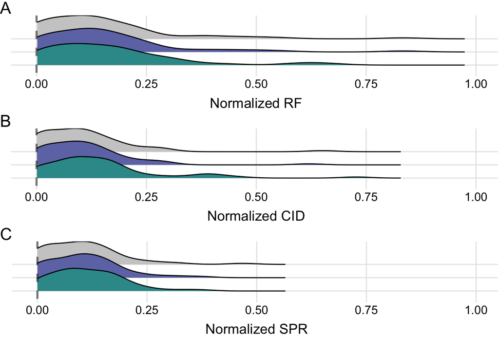

```r
# Load data
df <- read.csv("Dataset_R_q123_08-25.csv")
df_extant <- df %>% filter(grepl("Extant", Type)) # keep only extant datasets

# Create a dataframe
df_extant <- data.frame(
  RFdist = c(df_extant$MP_MOLvsTE_NormalizedRF, df_extant$ML_MOLvsTEASC_NormalizedRF, df_extant$ML_MOLvsTEnoASC_NormalizedRF),  # Combine the vectors into a single column
  CID = c(df_extant$MP_MOLvsTE_NormalizedCID, df_extant$ML_MOLvsTEASC_NormalizedCID, df_extant$ML_MOLvsTEnoASC_NormalizedCID),
  SPR = c(df_extant$MP_MOLvsTE_NormalizedMeanSPR, df_extant$ML_MOLvsTEASC_NormalizedMeanSPR, df_extant$ML_MOLvsTEnoASC_NormalizedMeanSPR),
  comparison = rep(c("MPmol_MPte", "MLmol_MLteAsc", "MLmol_MLteNoAsc"), each = length(df_extant$MP_MOLvsTE_NormalizedRF))  # Repeat vector names
)
df_extant$comparison <- factor(df_extant$comparison, levels = c("MPmol_MPte", "MLmol_MLteAsc", "MLmol_MLteNoAsc"))
custom_palette <- c("MPmol_MPte" = "#339999",
                    "MLmol_MLteAsc" = "#6f77b4",
                    "MLmol_MLteNoAsc" = "#cccccc")
custom_labels <- c(
  "MPmol_MPte" = "MP-MOL vs MP-TE",
  "MLmol_MLteAsc" = "ML-MOL vs ML-TE (with ASC)",
  "MLmol_MLteNoAsc" = "ML-MOL vs ML-TE (without ASC)"
)
s1_rf = ggplot(df_extant, aes(x=RFdist, y=comparison, fill=comparison))+
  geom_density_ridges() +
  scale_x_continuous(limits = c(0, 1)) +  # Set lower limit to 0, prevents extrapolation below 0
  theme_ridges()+
  labs(x="Normalized RF", y=NULL,tag="A")+
  scale_fill_manual(values = custom_palette, labels = custom_labels)+
  geom_vline(xintercept = 0, color = "black", linetype = "dashed", linewidth = 1, alpha=.5) +
  theme(
    axis.text.y = element_blank(),  # Remove y-axis values
    legend.position = "none",     # Move the legend below the plot
    legend.direction = "horizontal", # Display legend items horizontally (side by side)
    legend.box = "horizontal",      # Make sure the legend is laid out horizontally
    legend.title = element_blank(),  # Optional: Remove legend title
    legend.text = element_text(size = 8),  # Reduce the size of legend text
    legend.key.size = unit(0.5, "cm"),    # Reduce the size of legend keys
    axis.title.x = element_text(hjust = 0.5)  # Center the x-axis title
  )
s1_cid = ggplot(df_extant, aes(x=CID, y=comparison, fill=comparison))+
  geom_density_ridges() +
  scale_x_continuous(limits = c(0, 1)) +  # Set lower limit to 0, prevents extrapolation below 0
  theme_ridges()+
  labs(x="Normalized CID", y=NULL,tag="B")+
  scale_fill_manual(values = custom_palette, labels = custom_labels)+
  geom_vline(xintercept = 0, color = "black", linetype = "dashed", size = 1, alpha=.5) +
  theme(
    axis.text.y = element_blank(),  # Remove y-axis values
    legend.position = "none",     # Move the legend below the plot
    legend.direction = "horizontal", # Display legend items horizontally (side by side)
    legend.box = "horizontal",      # Make sure the legend is laid out horizontally
    legend.title = element_blank(),  # Optional: Remove legend title
    legend.text = element_text(size = 8),  # Reduce the size of legend text
    legend.key.size = unit(0.5, "cm"),    # Reduce the size of legend keys
    axis.title.x = element_text(hjust = 0.5)  # Center the x-axis title
  )
s1_spr = ggplot(df_extant, aes(x=SPR, y=comparison, fill=comparison))+
  geom_density_ridges() +
  scale_x_continuous(limits = c(0, 1)) +  # Set lower limit to 0, prevents extrapolation below 0
  theme_ridges()+
  labs(x="Normalized SPR", y=NULL,tag="C")+
  scale_fill_manual(values = custom_palette, labels = custom_labels)+
  geom_vline(xintercept = 0, color = "black", linetype = "dashed", size = 1, alpha=.5) +
  theme(
    axis.text.y = element_blank(),  # Remove y-axis values
    legend.position = "none",     # Move the legend below the plot
    legend.direction = "horizontal", # Display legend items horizontally (side by side)
    legend.box = "horizontal",      # Make sure the legend is laid out horizontally
    legend.title = element_blank(),  # Optional: Remove legend title
    legend.text = element_text(size = 8),  # Reduce the size of legend text
    legend.key.size = unit(0.5, "cm"),    # Reduce the size of legend keys
    axis.title.x = element_text(hjust = 0.5)  # Center the x-axis title
  )
# Extract the legend as a separate ggplot object
legend <- ggplot(df_extant, aes(x = comparison, y = CID, color = comparison)) +
  geom_point() +
  scale_color_manual(values = custom_palette, labels = custom_labels) +
  theme_minimal() +
  theme(
    legend.position = "bottom",
    legend.title = element_blank(),
    panel.grid = element_blank(),
    panel.background = element_blank(),
    axis.title = element_blank(),
    axis.text = element_blank(),
    axis.ticks = element_blank(),
  )+
  guides(color = guide_legend(override.aes = list(size = 2, alpha=.7)))  # Increase dot size in legend
legend_grob <- cowplot::get_legend(legend)
#tiff("Figures/figS1_density.tiff", width = 6, height = 8, units = "in", res = 300)
grid.arrange(arrangeGrob(s1_rf + theme(plot.margin = margin(.01,1,1,.01)),
                         s1_cid + theme(plot.margin = margin(.01,1,1,.01)),
                         s1_spr + theme(plot.margin = margin(.01,1,1,.01)),
                         nrow=3, ncol=1),
             legend_grob,
             nrow=2,
             heights= c(20,1))
```

```r
#dev.off()
```

### Q1.3.2 Extant + Extinct (Figure S2)

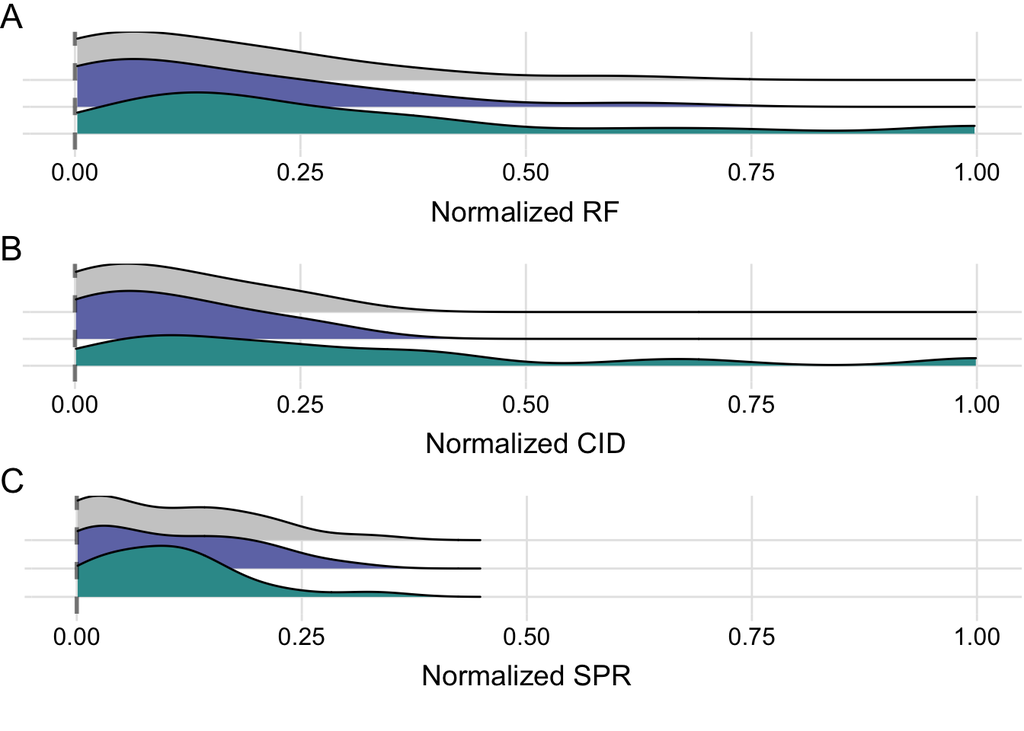

```r
# Load data
df <- read.csv("Dataset_R_q123_08-25.csv")
df_extinct <- df %>% filter(grepl("Extinct", Type)) # keep only extant datasets

# Create a dataframe
df_extinct <- data.frame(
  RFdist = c(df_extinct$MP_MOLvsTE_NormalizedRF, df_extinct$ML_MOLvsTEASC_NormalizedRF, df_extinct$ML_MOLvsTEnoASC_NormalizedRF),  # Combine the vectors into a single column
  CID = c(df_extinct$MP_MOLvsTE_NormalizedCID, df_extinct$ML_MOLvsTEASC_NormalizedCID, df_extinct$ML_MOLvsTEnoASC_NormalizedCID),
  SPR = c(df_extinct$MP_MOLvsTE_NormalizedMeanSPR, df_extinct$ML_MOLvsTEASC_NormalizedMeanSPR, df_extinct$ML_MOLvsTEnoASC_NormalizedMeanSPR),
  comparison = rep(c("MPmol_MPte", "MLmol_MLteAsc", "MLmol_MLteNoAsc"), each = length(df_extinct$MP_MOLvsTE_NormalizedRF))  # Repeat vector names
)
df_extinct$comparison <- factor(df_extinct$comparison, levels = c("MPmol_MPte", "MLmol_MLteAsc", "MLmol_MLteNoAsc"))
custom_palette <- c("MPmol_MPte" = "#339999",
                    "MLmol_MLteAsc" = "#6f77b4",
                    "MLmol_MLteNoAsc" = "#cccccc")
custom_labels <- c(
  "MPmol_MPte" = "MP-MOL vs MP-TE",
  "MLmol_MLteAsc" = "ML-MOL vs ML-TE (with ASC)",
  "MLmol_MLteNoAsc" = "ML-MOL vs ML-TE (without ASC)"
)
s1_rf = ggplot(df_extinct, aes(x=RFdist, y=comparison, fill=comparison))+
  geom_density_ridges() +
  scale_x_continuous(limits = c(0, 1)) +  # Set lower limit to 0, prevents extrapolation below 0
  theme_ridges()+
  labs(x="Normalized RF", y=NULL,tag="A")+
  scale_fill_manual(values = custom_palette, labels = custom_labels)+
  geom_vline(xintercept = 0, color = "black", linetype = "dashed", linewidth = 1, alpha=.5) +
  theme(
    axis.text.y = element_blank(),  # Remove y-axis values
    legend.position = "none",     # Move the legend below the plot
    legend.direction = "horizontal", # Display legend items horizontally (side by side)
    legend.box = "horizontal",      # Make sure the legend is laid out horizontally
    legend.title = element_blank(),  # Optional: Remove legend title
    legend.text = element_text(size = 8),  # Reduce the size of legend text
    legend.key.size = unit(0.5, "cm"),    # Reduce the size of legend keys
    axis.title.x = element_text(hjust = 0.5)  # Center the x-axis title
  )
s1_cid = ggplot(df_extinct, aes(x=CID, y=comparison, fill=comparison))+
  geom_density_ridges() +
  scale_x_continuous(limits = c(0, 1)) +  # Set lower limit to 0, prevents extrapolation below 0
  theme_ridges()+
  labs(x="Normalized CID", y=NULL,tag="B")+
  scale_fill_manual(values = custom_palette, labels = custom_labels)+
  geom_vline(xintercept = 0, color = "black", linetype = "dashed", size = 1, alpha=.5) +
  theme(
    axis.text.y = element_blank(),  # Remove y-axis values
    legend.position = "none",     # Move the legend below the plot
    legend.direction = "horizontal", # Display legend items horizontally (side by side)
    legend.box = "horizontal",      # Make sure the legend is laid out horizontally
    legend.title = element_blank(),  # Optional: Remove legend title
    legend.text = element_text(size = 8),  # Reduce the size of legend text
    legend.key.size = unit(0.5, "cm"),    # Reduce the size of legend keys
    axis.title.x = element_text(hjust = 0.5)  # Center the x-axis title
  )
s1_spr = ggplot(df_extinct, aes(x=SPR, y=comparison, fill=comparison))+
  geom_density_ridges() +
  scale_x_continuous(limits = c(0, 1)) +  # Set lower limit to 0, prevents extrapolation below 0
  theme_ridges()+
  labs(x="Normalized SPR", y=NULL,tag="C")+
  scale_fill_manual(values = custom_palette, labels = custom_labels)+
  geom_vline(xintercept = 0, color = "black", linetype = "dashed", size = 1, alpha=.5) +
  theme(
    axis.text.y = element_blank(),  # Remove y-axis values
    legend.position = "none",     # Move the legend below the plot
    legend.direction = "horizontal", # Display legend items horizontally (side by side)
    legend.box = "horizontal",      # Make sure the legend is laid out horizontally
    legend.title = element_blank(),  # Optional: Remove legend title
    legend.text = element_text(size = 8),  # Reduce the size of legend text
    legend.key.size = unit(0.5, "cm"),    # Reduce the size of legend keys
    axis.title.x = element_text(hjust = 0.5)  # Center the x-axis title
  )
# Extract the legend as a separate ggplot object
legend <- ggplot(df_extinct, aes(x = comparison, y = CID, color = comparison)) +
  geom_point() +
  scale_color_manual(values = custom_palette, labels = custom_labels) +
  theme_minimal() +
  theme(
    legend.position = "bottom",
    legend.title = element_blank(),
    panel.grid = element_blank(),
    panel.background = element_blank(),
    axis.title = element_blank(),
    axis.text = element_blank(),
    axis.ticks = element_blank(),
  )+
  guides(color = guide_legend(override.aes = list(size = 2, alpha=.7)))  # Increase dot size in legend
legend_grob <- cowplot::get_legend(legend)
#tiff("Figures/figS2_density.tiff", width = 6, height = 8, units = "in", res = 300)
grid.arrange(arrangeGrob(s1_rf + theme(plot.margin = margin(.01,1,1,.01)),
                         s1_cid + theme(plot.margin = margin(.01,1,1,.01)),
                         s1_spr + theme(plot.margin = margin(.01,1,1,.01)),
                         nrow=3, ncol=1),
             legend_grob,
             nrow=2,
             heights= c(20,1))
```

```r
#dev.off()
```

# Q2.Are MOL-TE incongruences associated with the proportion of phenomic characters?

## Q2.1 Spearman correlations

To test if the proportion of phenomic characters is associated with the topological metrics of MOL-TE incongruences, we used a non-parametric Spearman’s Rank Correlation test. The rho values measure the association between two variables based on their rank orders: a rho of +1 indicates a perfect monotonic increasing relationship; a rho of -1 indicates a perfect monotonic decreasing relationship; a rho of zero indicates a no monotonic relationship.

### Q2.1.1 Extant (Table 2)

```r
# Load data
df <- read.csv("Dataset_R_q123_08-25.csv")
df_extant <- df %>% filter(grepl("Extant", Type)) # keep only extant datasets

print("RF: MP MOL vs MP TE")
```

```
## [1] "RF: MP MOL vs MP TE"
```

```r
cor.test(df_extant$X.Morph.Total, df_extant$MP_MOLvsTE_NormalizedRF, method = "spearman")
```

```
##
##  Spearman's rank correlation rho
##
## data:  df_extant$X.Morph.Total and df_extant$MP_MOLvsTE_NormalizedRF
## S = 14589, p-value = 2.515e-05
## alternative hypothesis: true rho is not equal to 0
## sample estimates:
##       rho
## 0.5272004
```

```r
plot_mp_rf = ggplot(df_extant, aes(x = X.Morph.Total, y = MP_MOLvsTE_NormalizedRF)) +
  geom_point() +  # scatter plot
  geom_smooth(method = "lm", formula = y ~ x, color = "#339999", se = FALSE) +  # regression line (lm) for the trend
  stat_cor(method = "spearman", label.x = 0.08, label.y = 0.6) +  # add Spearman correlation value
  theme_minimal()+
  labs(y = "Normalized RF\n", x = NULL)

print("CID: MP MOL vs MP TE")
```

```
## [1] "CID: MP MOL vs MP TE"
```

```r
cor.test(df_extant$X.Morph.Total, df_extant$MP_MOLvsTE_NormalizedCID, method = "spearman")
```

```
##
##  Spearman's rank correlation rho
##
## data:  df_extant$X.Morph.Total and df_extant$MP_MOLvsTE_NormalizedCID
## S = 13266, p-value = 3.677e-06
## alternative hypothesis: true rho is not equal to 0
## sample estimates:
##       rho
## 0.5700664
```

```r
plot_mp_cid = ggplot(df_extant, aes(x = X.Morph.Total, y = MP_MOLvsTE_NormalizedCID)) +
  geom_point() +  # scatter plot
  geom_smooth(method = "lm", formula = y ~ x, color = "#339999", se = FALSE) +  # regression line (lm) for the trend
  stat_cor(method = "spearman", label.x = 0.08, label.y = 0.6) +  # add Spearman correlation value
  theme_minimal()+
  labs(y = "Normalized CID\n", x = NULL)

print("SPR: MP MOL vs MP TE")
```

```
## [1] "SPR: MP MOL vs MP TE"
```

```r
cor.test(df_extant$X.Morph.Total, df_extant$MP_MOLvsTE_NormalizedMeanSPR, method = "spearman")
```

```
##
##  Spearman's rank correlation rho
##
## data:  df_extant$X.Morph.Total and df_extant$MP_MOLvsTE_NormalizedMeanSPR
## S = 14472, p-value = 2.145e-05
## alternative hypothesis: true rho is not equal to 0
## sample estimates:
##       rho
## 0.5309872
```

```r
plot_mp_spr = ggplot(df_extant, aes(x = X.Morph.Total, y = MP_MOLvsTE_NormalizedMeanSPR)) +
  geom_point() +  # scatter plot
  geom_smooth(method = "lm", formula = y ~ x, color = "#339999", se = FALSE) +  # regression line (lm) for the trend
  stat_cor(method = "spearman", label.x = 0.08, label.y = 0.33) +  # add Spearman correlation value
  theme_minimal()+
  labs(y = "Normalized SPR\n", x = "\n% Phenomic characters")
```

```r
print("RF: ML MOL vs ML TE (ASC)")
```

```
## [1] "RF: ML MOL vs ML TE (ASC)"
```

```r
cor.test(df_extant$X.Morph.Total, df_extant$ML_MOLvsTEASC_NormalizedRF, method = "spearman")
```

```
##
##  Spearman's rank correlation rho
##
## data:  df_extant$X.Morph.Total and df_extant$ML_MOLvsTEASC_NormalizedRF
## S = 18526, p-value = 0.002074
## alternative hypothesis: true rho is not equal to 0
## sample estimates:
##       rho
## 0.3995979
```

```r
plot_mlasc_rf = ggplot(df_extant, aes(x = X.Morph.Total, y = ML_MOLvsTEASC_NormalizedRF)) +
  geom_point() +  # scatter plot
  geom_smooth(method = "lm", formula = y ~ x, color = "#6f77b4", se = FALSE) +  # regression line (lm) for the trend
  stat_cor(method = "spearman", label.x = 0.09, label.y = 0.73) +  # add Spearman correlation value
  theme_minimal()+
  labs(x = NULL, y = NULL) # Remove x and y axis titles

print("CID: ML MOL vs ML TE (ASC)")
```

```
## [1] "CID: ML MOL vs ML TE (ASC)"
```

```r
cor.test(df_extant$X.Morph.Total, df_extant$ML_MOLvsTEASC_NormalizedCID, method = "spearman")
```

```
##
##  Spearman's rank correlation rho
##
## data:  df_extant$X.Morph.Total and df_extant$ML_MOLvsTEASC_NormalizedCID
## S = 17416, p-value = 0.0007079
## alternative hypothesis: true rho is not equal to 0
## sample estimates:
##       rho
## 0.4355782
```

```r
plot_mlasc_cid = ggplot(df_extant, aes(x = X.Morph.Total, y = ML_MOLvsTEASC_NormalizedCID)) +
  geom_point() +  # scatter plot
  geom_smooth(method = "lm", formula = y ~ x, color = "#6f77b4", se = FALSE) +  # regression line (lm) for the trend
  stat_cor(method = "spearman", label.x = 0.09, label.y = 0.515) +  # add Spearman correlation value
  theme_minimal()+
  labs(x = NULL, y = NULL)  # Remove x and y axis titles

print("SPR: ML MOL vs ML TE (ASC)")
```

```
## [1] "SPR: ML MOL vs ML TE (ASC)"
```

```r
cor.test(df_extant$X.Morph.Total, df_extant$ML_MOLvsTEASC_NormalizedMeanSPR, method = "spearman")
```

```
##
##  Spearman's rank correlation rho
##
## data:  df_extant$X.Morph.Total and df_extant$ML_MOLvsTEASC_NormalizedMeanSPR
## S = 17018, p-value = 0.0004676
## alternative hypothesis: true rho is not equal to 0
## sample estimates:
##       rho
## 0.4484707
```

```r
plot_mlasc_spr = ggplot(df_extant, aes(x = X.Morph.Total, y = ML_MOLvsTEASC_NormalizedMeanSPR)) +
  geom_point() +  # scatter plot
  geom_smooth(method = "lm", formula = y ~ x, color = "#6f77b4", se = FALSE) +  # regression line (lm) for the trend
  stat_cor(method = "spearman", label.x = 0.09, label.y = 0.334) +  # add Spearman correlation value
  theme_minimal()+
  labs(y = NULL, x = "\n% Phenomic characters")
```

```r
print("RF: ML MOL vs ML TE (noASC)")
```

```
## [1] "RF: ML MOL vs ML TE (noASC)"
```

```r
cor.test(df_extant$X.Morph.Total, df_extant$ML_MOLvsTEnoASC_NormalizedRF, method = "spearman")
```

```
##
##  Spearman's rank correlation rho
##
## data:  df_extant$X.Morph.Total and df_extant$ML_MOLvsTEnoASC_NormalizedRF
## S = 18928, p-value = 0.002976
## alternative hypothesis: true rho is not equal to 0
## sample estimates:
##      rho
## 0.386558
```

```r
plot_mlno_rf = ggplot(df_extant, aes(x = X.Morph.Total, y = ML_MOLvsTEnoASC_NormalizedRF)) +
  geom_point() +  # scatter plot
  geom_smooth(method = "lm", formula = y ~ x, color = "#cccccc", se = FALSE) +  # regression line (lm) for the trend
  stat_cor(method = "spearman", label.x = 0.09, label.y = 0.73) +  # add Spearman correlation value
  theme_minimal()+
  labs(x = NULL, y = NULL)  # Remove x and y axis titles

print("CID: ML MOL vs ML TE (noASC)")
```

```
## [1] "CID: ML MOL vs ML TE (noASC)"
```

```r
cor.test(df_extant$X.Morph.Total, df_extant$ML_MOLvsTEnoASC_NormalizedCID, method = "spearman")
```

```
##
##  Spearman's rank correlation rho
##
## data:  df_extant$X.Morph.Total and df_extant$ML_MOLvsTEnoASC_NormalizedCID
## S = 18957, p-value = 0.003051
## alternative hypothesis: true rho is not equal to 0
## sample estimates:
##       rho
## 0.3856368
```

```r
plot_mlno_cid = ggplot(df_extant, aes(x = X.Morph.Total, y = ML_MOLvsTEnoASC_NormalizedCID)) +
  geom_point() +  # scatter plot
  geom_smooth(method = "lm", formula = y ~ x, color = "#cccccc", se = FALSE) +  # regression line (lm) for the trend
  stat_cor(method = "spearman", label.x = 0.09, label.y = 0.525) +  # add Spearman correlation value
  theme_minimal()+
  labs(x = NULL, y = NULL)  # Remove x and y axis titles

print("SPR: ML MOL vs ML TE (noASC)")
```

```
## [1] "SPR: ML MOL vs ML TE (noASC)"
```

```r
cor.test(df_extant$X.Morph.Total, df_extant$ML_MOLvsTEnoASC_NormalizedMeanSPR, method = "spearman")
```

```
##
##  Spearman's rank correlation rho
##
## data:  df_extant$X.Morph.Total and df_extant$ML_MOLvsTEnoASC_NormalizedMeanSPR
## S = 17423, p-value = 0.0007135
## alternative hypothesis: true rho is not equal to 0
## sample estimates:
##       rho
## 0.4353291
```

```r
plot_mlno_spr = ggplot(df_extant, aes(x = X.Morph.Total, y = ML_MOLvsTEnoASC_NormalizedMeanSPR)) +
  geom_point() +  # scatter plot
  geom_smooth(method = "lm", formula = y ~ x, color = "#cccccc", se = FALSE) +  # regression line (lm) for the trend
  stat_cor(method = "spearman", label.x = 0.085, label.y = 0.42) +  # add Spearman correlation value
  theme_minimal()+
  labs(y = NULL, x = "\n% Phenomic characters")
```

### Q2.1.2 Extant + extinct (Table 2)

To test if the proportion of phenomic characters is associated with the topological metrics of MOL-TE incongruences, we used a non-parametric Spearman’s Rank Correlation test. The rho values measure the association between two variables based on their rank orders: a rho of +1 indicates a perfect monotonic increasing relationship; a rho of -1 indicates a perfect monotonic decreasing relationship; a rho of zero indicates a no monotonic relationship.

```r
# Load data
df <- read.csv("Dataset_R_q123_08-25.csv")
df_extinct <- df %>% filter(grepl("Extinct", Type)) # keep only extant datasets

print("RF: MP MOL vs MP TE")
```

```
## [1] "RF: MP MOL vs MP TE"
```

```r
cor.test(df_extinct$X.Morph.Total, df_extinct$MP_MOLvsTE_NormalizedRF, method = "spearman")
```

```
##
##  Spearman's rank correlation rho
##
## data:  df_extinct$X.Morph.Total and df_extinct$MP_MOLvsTE_NormalizedRF
## S = 913.76, p-value = 0.02245
## alternative hypothesis: true rho is not equal to 0
## sample estimates:
##       rho
## 0.4840441
```

```r
plot_mp_rf_fossil = ggplot(df_extinct, aes(x = X.Morph.Total, y = MP_MOLvsTE_NormalizedRF)) +
  geom_point() +  # scatter plot
  geom_smooth(method = "lm", formula = y ~ x, color = "#339999", se = FALSE) +  # regression line (lm) for the trend
  #stat_cor(method = "spearman", label.x = 0.08, label.y = 0.6) +  # add Spearman correlation value
  theme_minimal()+
  labs(y = "Normalized RF\n", x = NULL)

print("CID: MP MOL vs MP TE")
```

```
## [1] "CID: MP MOL vs MP TE"
```

```r
cor.test(df_extinct$X.Morph.Total, df_extinct$MP_MOLvsTE_NormalizedCID, method = "spearman")
```

```
##
##  Spearman's rank correlation rho
##
## data:  df_extinct$X.Morph.Total and df_extinct$MP_MOLvsTE_NormalizedCID
## S = 869.75, p-value = 0.01558
## alternative hypothesis: true rho is not equal to 0
## sample estimates:
##       rho
## 0.5088958
```

```r
plot_mp_cid_fossil = ggplot(df_extinct, aes(x = X.Morph.Total, y = MP_MOLvsTE_NormalizedCID)) +
  geom_point() +  # scatter plot
  geom_smooth(method = "lm", formula = y ~ x, color = "#339999", se = FALSE) +  # regression line (lm) for the trend
  #stat_cor(method = "spearman", label.x = 0.08, label.y = 0.6) +  # add Spearman correlation value
  theme_minimal()+
  labs(y = "Normalized CID\n", x = NULL)

print("SPR: MP MOL vs MP TE")
```

```
## [1] "SPR: MP MOL vs MP TE"
```

```r
cor.test(df_extinct$X.Morph.Total, df_extinct$MP_MOLvsTE_NormalizedMeanSPR, method = "spearman")
```

```
##
##  Spearman's rank correlation rho
##
## data:  df_extinct$X.Morph.Total and df_extinct$MP_MOLvsTE_NormalizedMeanSPR
## S = 929.05, p-value = 0.02534
## alternative hypothesis: true rho is not equal to 0
## sample estimates:
##       rho
## 0.4754101
```

```r
plot_mp_spr_fossil = ggplot(df_extinct, aes(x = X.Morph.Total, y = MP_MOLvsTE_NormalizedMeanSPR)) +
  geom_point() +  # scatter plot
  geom_smooth(method = "lm", formula = y ~ x, color = "#339999", se = FALSE) +  # regression line (lm) for the trend
  #stat_cor(method = "spearman", label.x = 0.08, label.y = 0.33) +  # add Spearman correlation value
  theme_minimal()+
  labs(y = "Normalized SPR\n", x = "\n% Phenomic characters")
```

```r
print("RF: ML MOL vs ML TE (ASC)")
```

```
## [1] "RF: ML MOL vs ML TE (ASC)"
```

```r
cor.test(df_extinct$X.Morph.Total, df_extinct$ML_MOLvsTEASC_NormalizedRF, method = "spearman")
```

```
##
##  Spearman's rank correlation rho
##
## data:  df_extinct$X.Morph.Total and df_extinct$ML_MOLvsTEASC_NormalizedRF
## S = 1018.7, p-value = 0.04876
## alternative hypothesis: true rho is not equal to 0
## sample estimates:
##       rho
## 0.4248109
```

```r
plot_mlasc_rf_fossil = ggplot(df_extinct, aes(x = X.Morph.Total, y = ML_MOLvsTEASC_NormalizedRF)) +
  geom_point() +  # scatter plot
  geom_smooth(method = "lm", formula = y ~ x, color = "#6f77b4", se = FALSE) +  # regression line (lm) for the trend
  #stat_cor(method = "spearman", label.x = 0.09, label.y = 0.73) +  # add Spearman correlation value
  theme_minimal()+
  labs(x = NULL, y = NULL) # Remove x and y axis titles

print("CID: ML MOL vs ML TE (ASC)")
```

```
## [1] "CID: ML MOL vs ML TE (ASC)"
```

```r
cor.test(df_extinct$X.Morph.Total, df_extinct$ML_MOLvsTEASC_NormalizedCID, method = "spearman")
```

```
##
##  Spearman's rank correlation rho
##
## data:  df_extinct$X.Morph.Total and df_extinct$ML_MOLvsTEASC_NormalizedCID
## S = 971.74, p-value = 0.03501
## alternative hypothesis: true rho is not equal to 0
## sample estimates:
##       rho
## 0.4513042
```

```r
plot_mlasc_cid_fossil = ggplot(df_extinct, aes(x = X.Morph.Total, y = ML_MOLvsTEASC_NormalizedCID)) +
  geom_point() +  # scatter plot
  geom_smooth(method = "lm", formula = y ~ x, color = "#6f77b4", se = FALSE) +  # regression line (lm) for the trend
 # stat_cor(method = "spearman", label.x = 0.09, label.y = 0.515) +  # add Spearman correlation value
  theme_minimal()+
  labs(x = NULL, y = NULL)  # Remove x and y axis titles

print("SPR: ML MOL vs ML TE (ASC)")
```

```
## [1] "SPR: ML MOL vs ML TE (ASC)"
```

```r
cor.test(df_extinct$X.Morph.Total, df_extinct$ML_MOLvsTEASC_NormalizedMeanSPR, method = "spearman")
```

```
##
##  Spearman's rank correlation rho
##
## data:  df_extinct$X.Morph.Total and df_extinct$ML_MOLvsTEASC_NormalizedMeanSPR
## S = 835.35, p-value = 0.01149
## alternative hypothesis: true rho is not equal to 0
## sample estimates:
##       rho
## 0.5283147
```

```r
plot_mlasc_spr_fossil = ggplot(df_extinct, aes(x = X.Morph.Total, y = ML_MOLvsTEASC_NormalizedMeanSPR)) +
  geom_point() +  # scatter plot
  geom_smooth(method = "lm", formula = y ~ x, color = "#6f77b4", se = FALSE) +  # regression line (lm) for the trend
  #stat_cor(method = "spearman", label.x = 0.09, label.y = 0.334) +  # add Spearman correlation value
  theme_minimal()+
  labs(y = NULL, x = "\n% Phenomic characters")
```

```r
print("RF: ML MOL vs ML TE (noASC)")
```

```
## [1] "RF: ML MOL vs ML TE (noASC)"
```

```r
cor.test(df_extinct$X.Morph.Total, df_extinct$ML_MOLvsTEnoASC_NormalizedRF, method = "spearman")
```

```
##
##  Spearman's rank correlation rho
##
## data:  df_extinct$X.Morph.Total and df_extinct$ML_MOLvsTEnoASC_NormalizedRF
## S = 1004.2, p-value = 0.04413
## alternative hypothesis: true rho is not equal to 0
## sample estimates:
##       rho
## 0.4329868
```

```r
plot_mlno_rf_fossil = ggplot(df_extinct, aes(x = X.Morph.Total, y = ML_MOLvsTEnoASC_NormalizedRF)) +
  geom_point() +  # scatter plot
  geom_smooth(method = "lm", formula = y ~ x, color = "#cccccc", se = FALSE) +  # regression line (lm) for the trend
  #stat_cor(method = "spearman", label.x = 0.09, label.y = 0.73) +  # add Spearman correlation value
  theme_minimal()+
  labs(x = NULL, y = NULL)  # Remove x and y axis titles

print("CID: ML MOL vs ML TE (noASC)")
```

```
## [1] "CID: ML MOL vs ML TE (noASC)"
```

```r
cor.test(df_extinct$X.Morph.Total, df_extinct$ML_MOLvsTEnoASC_NormalizedCID, method = "spearman")
```

```
##
##  Spearman's rank correlation rho
##
## data:  df_extinct$X.Morph.Total and df_extinct$ML_MOLvsTEnoASC_NormalizedCID
## S = 967.73, p-value = 0.03399
## alternative hypothesis: true rho is not equal to 0
## sample estimates:
##       rho
## 0.4535692
```

```r
plot_mlno_cid_fossil = ggplot(df_extinct, aes(x = X.Morph.Total, y = ML_MOLvsTEnoASC_NormalizedCID)) +
  geom_point() +  # scatter plot
  geom_smooth(method = "lm", formula = y ~ x, color = "#cccccc", se = FALSE) +  # regression line (lm) for the trend
 # stat_cor(method = "spearman", label.x = 0.09, label.y = 0.525) +  # add Spearman correlation value
  theme_minimal()+
  labs(x = NULL, y = NULL)  # Remove x and y axis titles

print("SPR: ML MOL vs ML TE (noASC)")
```

```
## [1] "SPR: ML MOL vs ML TE (noASC)"
```

```r
cor.test(df_extinct$X.Morph.Total, df_extinct$ML_MOLvsTEnoASC_NormalizedMeanSPR, method = "spearman")
```

```
##
##  Spearman's rank correlation rho
##
## data:  df_extinct$X.Morph.Total and df_extinct$ML_MOLvsTEnoASC_NormalizedMeanSPR
## S = 838.1, p-value = 0.01178
## alternative hypothesis: true rho is not equal to 0
## sample estimates:
##       rho
## 0.5267655
```

```r
plot_mlno_spr_fossil = ggplot(df_extinct, aes(x = X.Morph.Total, y = ML_MOLvsTEnoASC_NormalizedMeanSPR)) +
  geom_point() +  # scatter plot
  geom_smooth(method = "lm", formula = y ~ x, color = "#cccccc", se = FALSE) +  # regression line (lm) for the trend
 # stat_cor(method = "spearman", label.x = 0.085, label.y = 0.42) +  # add Spearman correlation value
  theme_minimal()+
  labs(y = NULL, x = "\n% Phenomic characters")
```

### Q2.1.3 Reduced (Table S12)

```r
# Load data
df <- read.csv("Dataset_R_q123_08-25.csv")
df_filtered <- df[df$Dataset %in% df_extinct$Dataset, ]
df_filtered <- df_filtered %>% filter(grepl("Extant", Type)) # keep only extant datasets

print("RF: MP MOL vs MP TE")
```

```
## [1] "RF: MP MOL vs MP TE"
```

```r
cor.test(df_filtered$X.Morph.Total, df_filtered$MP_MOLvsTE_NormalizedRF, method = "spearman")
```

```
##
##  Spearman's rank correlation rho
##
## data:  df_filtered$X.Morph.Total and df_filtered$MP_MOLvsTE_NormalizedRF
## S = 745.71, p-value = 0.004757
## alternative hypothesis: true rho is not equal to 0
## sample estimates:
##       rho
## 0.5789325
```

```r
plot_mp_rf = ggplot(df_filtered, aes(x = X.Morph.Total, y = MP_MOLvsTE_NormalizedRF)) +
  geom_point() +  # scatter plot
  geom_smooth(method = "lm", formula = y ~ x, color = "#339999", se = FALSE) +  # regression line (lm) for the trend
  stat_cor(method = "spearman", label.x = 0.08, label.y = 0.6) +  # add Spearman correlation value
  theme_minimal()+
  labs(y = "Normalized RF\n", x = NULL)

print("CID: MP MOL vs MP TE")
```

```
## [1] "CID: MP MOL vs MP TE"
```

```r
cor.test(df_filtered$X.Morph.Total, df_filtered$MP_MOLvsTE_NormalizedCID, method = "spearman")
```

```
##
##  Spearman's rank correlation rho
##
## data:  df_filtered$X.Morph.Total and df_filtered$MP_MOLvsTE_NormalizedCID
## S = 699.7, p-value = 0.002859
## alternative hypothesis: true rho is not equal to 0
## sample estimates:
##       rho
## 0.6049139
```

```r
plot_mp_cid = ggplot(df_filtered, aes(x = X.Morph.Total, y = MP_MOLvsTE_NormalizedCID)) +
  geom_point() +  # scatter plot
  geom_smooth(method = "lm", formula = y ~ x, color = "#339999", se = FALSE) +  # regression line (lm) for the trend
  stat_cor(method = "spearman", label.x = 0.08, label.y = 0.6) +  # add Spearman correlation value
  theme_minimal()+
  labs(y = "Normalized CID\n", x = NULL)

print("SPR: MP MOL vs MP TE")
```

```
## [1] "SPR: MP MOL vs MP TE"
```

```r
cor.test(df_filtered$X.Morph.Total, df_filtered$MP_MOLvsTE_NormalizedMeanSPR, method = "spearman")
```

```
##
##  Spearman's rank correlation rho
##
## data:  df_filtered$X.Morph.Total and df_filtered$MP_MOLvsTE_NormalizedMeanSPR
## S = 731.71, p-value = 0.004092
## alternative hypothesis: true rho is not equal to 0
## sample estimates:
##       rho
## 0.5868399
```

```r
plot_mp_spr = ggplot(df_filtered, aes(x = X.Morph.Total, y = MP_MOLvsTE_NormalizedMeanSPR)) +
  geom_point() +  # scatter plot
  geom_smooth(method = "lm", formula = y ~ x, color = "#339999", se = FALSE) +  # regression line (lm) for the trend
  stat_cor(method = "spearman", label.x = 0.08, label.y = 0.33) +  # add Spearman correlation value
  theme_minimal()+
  labs(y = "Normalized SPR\n", x = "\n% Phenomic characters")
```

```r
print("RF: ML MOL vs ML TE (ASC)")
```

```
## [1] "RF: ML MOL vs ML TE (ASC)"
```

```r
cor.test(df_filtered$X.Morph.Total, df_filtered$ML_MOLvsTEASC_NormalizedRF, method = "spearman")
```

```
##
##  Spearman's rank correlation rho
##
## data:  df_filtered$X.Morph.Total and df_filtered$ML_MOLvsTEASC_NormalizedRF
## S = 1162.7, p-value = 0.1175
## alternative hypothesis: true rho is not equal to 0
## sample estimates:
##       rho
## 0.3435029
```

```r
plot_mlasc_rf = ggplot(df_filtered, aes(x = X.Morph.Total, y = ML_MOLvsTEASC_NormalizedRF)) +
  geom_point() +  # scatter plot
  geom_smooth(method = "lm", formula = y ~ x, color = "#6f77b4", se = FALSE) +  # regression line (lm) for the trend
  stat_cor(method = "spearman", label.x = 0.09, label.y = 0.73) +  # add Spearman correlation value
  theme_minimal()+
  labs(x = NULL, y = NULL) # Remove x and y axis titles

print("CID: ML MOL vs ML TE (ASC)")
```

```
## [1] "CID: ML MOL vs ML TE (ASC)"
```

```r
cor.test(df_filtered$X.Morph.Total, df_filtered$ML_MOLvsTEASC_NormalizedCID, method = "spearman")
```

```
##
##  Spearman's rank correlation rho
##
## data:  df_filtered$X.Morph.Total and df_filtered$ML_MOLvsTEASC_NormalizedCID
## S = 1171.8, p-value = 0.1235
## alternative hypothesis: true rho is not equal to 0
## sample estimates:
##       rho
## 0.3383225
```

```r
plot_mlasc_cid = ggplot(df_filtered, aes(x = X.Morph.Total, y = ML_MOLvsTEASC_NormalizedCID)) +
  geom_point() +  # scatter plot
  geom_smooth(method = "lm", formula = y ~ x, color = "#6f77b4", se = FALSE) +  # regression line (lm) for the trend
  stat_cor(method = "spearman", label.x = 0.09, label.y = 0.515) +  # add Spearman correlation value
  theme_minimal()+
  labs(x = NULL, y = NULL)  # Remove x and y axis titles

print("SPR: ML MOL vs ML TE (ASC)")
```

```
## [1] "SPR: ML MOL vs ML TE (ASC)"
```

```r
cor.test(df_filtered$X.Morph.Total, df_filtered$ML_MOLvsTEASC_NormalizedMeanSPR, method = "spearman")
```

```
##
##  Spearman's rank correlation rho
##
## data:  df_filtered$X.Morph.Total and df_filtered$ML_MOLvsTEASC_NormalizedMeanSPR
## S = 1020.6, p-value = 0.04939
## alternative hypothesis: true rho is not equal to 0
## sample estimates:
##       rho
## 0.4237289
```

```r
plot_mlasc_spr = ggplot(df_filtered, aes(x = X.Morph.Total, y = ML_MOLvsTEASC_NormalizedMeanSPR)) +
  geom_point() +  # scatter plot
  geom_smooth(method = "lm", formula = y ~ x, color = "#6f77b4", se = FALSE) +  # regression line (lm) for the trend
  stat_cor(method = "spearman", label.x = 0.09, label.y = 0.334) +  # add Spearman correlation value
  theme_minimal()+
  labs(y = NULL, x = "\n% Phenomic characters")
```

```r
print("RF: ML MOL vs ML TE (noASC)")
```

```
## [1] "RF: ML MOL vs ML TE (noASC)"
```

```r
cor.test(df_filtered$X.Morph.Total, df_filtered$ML_MOLvsTEnoASC_NormalizedRF, method = "spearman")
```

```
##
##  Spearman's rank correlation rho
##
## data:  df_filtered$X.Morph.Total and df_filtered$ML_MOLvsTEnoASC_NormalizedRF
## S = 1078.6, p-value = 0.072
## alternative hypothesis: true rho is not equal to 0
## sample estimates:
##       rho
## 0.3909605
```

```r
plot_mlno_rf = ggplot(df_filtered, aes(x = X.Morph.Total, y = ML_MOLvsTEnoASC_NormalizedRF)) +
  geom_point() +  # scatter plot
  geom_smooth(method = "lm", formula = y ~ x, color = "#cccccc", se = FALSE) +  # regression line (lm) for the trend
  stat_cor(method = "spearman", label.x = 0.09, label.y = 0.73) +  # add Spearman correlation value
  theme_minimal()+
  labs(x = NULL, y = NULL)  # Remove x and y axis titles

print("CID: ML MOL vs ML TE (noASC)")
```

```
## [1] "CID: ML MOL vs ML TE (noASC)"
```

```r
cor.test(df_filtered$X.Morph.Total, df_filtered$ML_MOLvsTEnoASC_NormalizedCID, method = "spearman")
```

```
##
##  Spearman's rank correlation rho
##
## data:  df_filtered$X.Morph.Total and df_filtered$ML_MOLvsTEnoASC_NormalizedCID
## S = 1157.8, p-value = 0.1145
## alternative hypothesis: true rho is not equal to 0
## sample estimates:
##       rho
## 0.3462299
```

```r
plot_mlno_cid = ggplot(df_filtered, aes(x = X.Morph.Total, y = ML_MOLvsTEnoASC_NormalizedCID)) +
  geom_point() +  # scatter plot
  geom_smooth(method = "lm", formula = y ~ x, color = "#cccccc", se = FALSE) +  # regression line (lm) for the trend
  stat_cor(method = "spearman", label.x = 0.09, label.y = 0.525) +  # add Spearman correlation value
  theme_minimal()+
  labs(x = NULL, y = NULL)  # Remove x and y axis titles

print("SPR: ML MOL vs ML TE (noASC)")
```

```
## [1] "SPR: ML MOL vs ML TE (noASC)"
```

```r
cor.test(df_filtered$X.Morph.Total, df_filtered$ML_MOLvsTEnoASC_NormalizedMeanSPR, method = "spearman")
```

```
##
##  Spearman's rank correlation rho
##
## data:  df_filtered$X.Morph.Total and df_filtered$ML_MOLvsTEnoASC_NormalizedMeanSPR
## S = 972.55, p-value = 0.03522
## alternative hypothesis: true rho is not equal to 0
## sample estimates:
##       rho
## 0.4508475
```

```r
plot_mlno_spr = ggplot(df_filtered, aes(x = X.Morph.Total, y = ML_MOLvsTEnoASC_NormalizedMeanSPR)) +
  geom_point() +  # scatter plot
  geom_smooth(method = "lm", formula = y ~ x, color = "#cccccc", se = FALSE) +  # regression line (lm) for the trend
  stat_cor(method = "spearman", label.x = 0.085, label.y = 0.42) +  # add Spearman correlation value
  theme_minimal()+
  labs(y = NULL, x = "\n% Phenomic characters")
```

## Q2.2 Figures

### Q2.2.1 Extant (Figure 3)

```r
# Grid 3x3
tiff("Figures/fig3_proportion.tiff", width = 12, height = 10, units = "in", res = 300)
grid.arrange(arrangeGrob(plot_mp_rf + theme(plot.margin = margin(.01,1,1,.01)),
                         plot_mlasc_rf + theme(plot.margin = margin(.01,1,1,.01)),
                         plot_mlno_rf + theme(plot.margin = margin(.01,1,1,.01)),
                         plot_mp_cid + theme(plot.margin = margin(.01,1,1,.01)),
                         plot_mlasc_cid + theme(plot.margin = margin(.01,1,1,.01)),
                         plot_mlno_cid + theme(plot.margin = margin(.01,1,1,.01)),
                         plot_mp_spr + theme(plot.margin = margin(.01,1,1,.01)),
                         plot_mlasc_spr + theme(plot.margin = margin(.01,1,1,.01)),
                         plot_mlno_spr + theme(plot.margin = margin(.01,1,1,.01)),
                         nrow=3, ncol=3),
             legend_grob,
             nrow=2,
             heights= c(20,1))
dev.off()
```

### Q2.2.2 Extant + extinct (Figure S3)

```r
# Grid 3x3
tiff("Figures/figS3_proportion_fossils.tiff", width = 12, height = 10, units = "in", res = 300)
grid.arrange(arrangeGrob(plot_mp_rf_fossil + theme(plot.margin = margin(.01,1,1,.01)),
                         plot_mlasc_rf_fossil + theme(plot.margin = margin(.01,1,1,.01)),
                         plot_mlno_rf_fossil + theme(plot.margin = margin(.01,1,1,.01)),
                         plot_mp_cid_fossil + theme(plot.margin = margin(.01,1,1,.01)),
                         plot_mlasc_cid_fossil + theme(plot.margin = margin(.01,1,1,.01)),
                         plot_mlno_cid_fossil + theme(plot.margin = margin(.01,1,1,.01)),
                         plot_mp_spr_fossil + theme(plot.margin = margin(.01,1,1,.01)),
                         plot_mlasc_spr_fossil + theme(plot.margin = margin(.01,1,1,.01)),
                         plot_mlno_spr_fossil + theme(plot.margin = margin(.01,1,1,.01)),
                         nrow=3, ncol=3),
             legend_grob,
             nrow=2,
             heights= c(20,1))
dev.off()
```

# Q3. Is the addition of phenomic evidence equally impactful on ML and MP topologies?

## Q3.1 MOL-TE incongruences ~ Optimality criteria

To test whether the MOL-TE incongruences are different between ML and MP, we first need to change the structure of the dataframe.

### Q3.1.1 Extant (Table 3)

```r
# Load data
df <- read.csv("Dataset_R_q123_08-25.csv")
df_extant <- df %>% filter(grepl("Extant", Type)) # keep only extant datasets

# Create an empty data frame for RF
q3_rf <- data.frame(value = numeric(0), source = character(0))
# Combine the vectors of RF into the data frame
q3_rf <- rbind(q3_rf, data.frame(value = df_extant$MP_MOLvsTE_NormalizedRF, source = rep("MP_MOLvsTE", length(df_extant$MP_MOLvsTE_NormalizedRF))))
q3_rf <- rbind(q3_rf, data.frame(value = df_extant$ML_MOLvsTEASC_NormalizedRF, source = rep("ML_MOLvsTEASC", length(df_extant$ML_MOLvsTEASC_NormalizedRF))))
q3_rf <- rbind(q3_rf, data.frame(value = df_extant$ML_MOLvsTEnoASC_NormalizedRF, source = rep("ML_MOLvsTEnoASC", length(df_extant$ML_MOLvsTEnoASC_NormalizedRF))))
# Summary of medians
q3_rf %>%
  group_by(source) %>%
  summarise(
    median_value = median(value, na.rm = TRUE),
    sd_value = sd(value, na.rm = TRUE),
    n = n())
```

```
## # A tibble: 3 × 4
##   source          median_value sd_value     n
##   <chr>                  <dbl>    <dbl> <int>
## 1 ML_MOLvsTEASC          0.125    0.153    57
## 2 ML_MOLvsTEnoASC        0.12     0.156    57
## 3 MP_MOLvsTE             0.127    0.150    57
```

```r
# Create an empty data frame for CID
q3_cid <- data.frame(value = numeric(0), source = character(0))
# Combine the vectors of CID into the data frame
q3_cid <- rbind(q3_cid, data.frame(value = df_extant$MP_MOLvsTE_NormalizedCID, source = rep("MP_MOLvsTE", length(df_extant$MP_MOLvsTE_NormalizedCID))))
q3_cid <- rbind(q3_cid, data.frame(value = df_extant$ML_MOLvsTEASC_NormalizedCID, source = rep("ML_MOLvsTEASC", length(df_extant$ML_MOLvsTEASC_NormalizedCID))))
q3_cid <- rbind(q3_cid, data.frame(value = df_extant$ML_MOLvsTEnoASC_NormalizedCID, source = rep("ML_MOLvsTEnoASC", length(df_extant$ML_MOLvsTEnoASC_NormalizedCID))))
# Summary of medians
q3_cid %>%
  group_by(source) %>%
  summarise(
    median_value = median(value, na.rm = TRUE),
    sd_value = sd(value, na.rm = TRUE),
    n = n())
```

```
## # A tibble: 3 × 4
##   source          median_value sd_value     n
##   <chr>                  <dbl>    <dbl> <int>
## 1 ML_MOLvsTEASC         0.0922    0.103    57
## 2 ML_MOLvsTEnoASC       0.0916    0.107    57
## 3 MP_MOLvsTE            0.115     0.135    57
```

```r
# Create an empty data frame for SPR
q3_spr <- data.frame(value = numeric(0), source = character(0))
# Combine the vectors of CID into the data frame
q3_spr <- rbind(q3_spr, data.frame(value = df_extant$MP_MOLvsTE_NormalizedMeanSPR, source = rep("MP_MOLvsTE", length(df_extant$MP_MOLvsTE_NormalizedMeanSPR))))
q3_spr <- rbind(q3_spr, data.frame(value = df_extant$ML_MOLvsTEASC_NormalizedMeanSPR, source = rep("ML_MOLvsTEASC", length(df_extant$ML_MOLvsTEASC_NormalizedMeanSPR))))
q3_spr <- rbind(q3_spr, data.frame(value = df_extant$ML_MOLvsTEnoASC_NormalizedMeanSPR, source = rep("ML_MOLvsTEnoASC", length(df_extant$ML_MOLvsTEnoASC_NormalizedMeanSPR))))
# Summary of medians
q3_spr %>%
  group_by(source) %>%
  summarise(
    median_value = median(value, na.rm = TRUE),
    sd_value = sd(value, na.rm = TRUE),
    n = n())
```

```
## # A tibble: 3 × 4
##   source          median_value sd_value     n
##   <chr>                  <dbl>    <dbl> <int>
## 1 ML_MOLvsTEASC         0.101    0.0825    57
## 2 ML_MOLvsTEnoASC       0.0948   0.0900    57
## 3 MP_MOLvsTE            0.104    0.0813    57
```

Then, we need to statistically test whether MOL-TE incongruences (operationally measured as normalized RF, CID, and SPR) differ between (1) MP MOL vs TE, (2) ML MOL vs TE MKv (with bias correction), and (3) ML MOL vs TE MK (no bias correction). Because data are not normally distributed (Shapiro-Wilk tests: P < 0.05) and more than one category is present in the predictor variable, we performed the following tests:

- The Kruskal-Wallis test is a nonparametric test used to compare the medians (or ranks) between >2 groups. As assumptions, this test does not require normality and observations must be independent. First, data is ranked (from the lowest to the highest value) and the mean rank computed. Next, we compute the statistic H (differences between group mean ranks and the overall mean rank, scaled by sample size). Finally, p-values can be estimated by comparing the statistic H and chi-squared distribution (if H is large, the p-value will be small).
- The Friedman test is a nonparametric test used to compare ordinal or continuous values that are paired between >2 groups. As assumptions, this test does not require normality and observations can be dependent (paired). First, ranks are assigned to the pairwise structure across groups. Next, the average rank within group is computed. The Friedman statistic measures how far group rank sums deviate from the expected value in the null model. Finally, p-values are computed by comparing the Friedman statistic and chi-squared distribution.
- The Wilcoxon signed-rank test is a nonparametric test used to compare the ordinal or continuous values between 2 groups (e.g. as posthoc analysis of Friedman tests). As assumptions, this test does not require normality and observations can be dependent. First, all values are ranked. The number of times that a value from one group precedes a value from the other is computed, generating the U statistic (the number of pairwise wins of one group over the other). Next, U is standardized to a normal distribution to obtain the p-value.

```r
print("RF")
```

```
## [1] "RF"
```

```r
shapiro.test(q3_rf$value) # p < 0.05, non-parametric
```

```
##
##  Shapiro-Wilk normality test
##
## data:  q3_rf$value
## W = 0.82726, p-value = 5.956e-13
```

```r
print("Kruskal-Wallis: non-parametric test for multiple groups (non-paired values)")
```

```
## [1] "Kruskal-Wallis: non-parametric test for multiple groups (non-paired values)"
```

```r
kruskal.test(q3_rf$value ~ q3_rf$source)
```

```
##
##  Kruskal-Wallis rank sum test
##
## data:  q3_rf$value by q3_rf$source
## Kruskal-Wallis chi-squared = 0.35512, df = 2, p-value = 0.8373
```

```r
print("Friedman: non-parametric test for paired values and multiple groups")
```

```
## [1] "Friedman: non-parametric test for paired values and multiple groups"
```

```r
q3_rf_fri = data.frame(df_extant$MP_MOLvsTE_NormalizedRF, df_extant$ML_MOLvsTEASC_NormalizedRF, df_extant$ML_MOLvsTEnoASC_NormalizedRF)
friedman.test(as.matrix(q3_rf_fri))
```

```
##
##  Friedman rank sum test
##
## data:  as.matrix(q3_rf_fri)
## Friedman chi-squared = 0.19277, df = 2, p-value = 0.9081
```

```r
print("Wilcoxon: pairwise comparisons for paired values")
```

```
## [1] "Wilcoxon: pairwise comparisons for paired values"
```

```r
pairwise.wilcox.test(x=unlist(q3_rf_fri),
                     g=factor(rep(names(q3_rf_fri), each = nrow(q3_rf_fri))),
                     paired=TRUE,
                     p.adjust.method="bonferroni")
```

```
##
##  Pairwise comparisons using Wilcoxon signed rank test with continuity correction
##
## data:  unlist(q3_rf_fri) and factor(rep(names(q3_rf_fri), each = nrow(q3_rf_fri)))
##
##                                        df_extant.ML_MOLvsTEASC_NormalizedRF
## df_extant.ML_MOLvsTEnoASC_NormalizedRF 1
## df_extant.MP_MOLvsTE_NormalizedRF      1
##                                        df_extant.ML_MOLvsTEnoASC_NormalizedRF
## df_extant.ML_MOLvsTEnoASC_NormalizedRF -
## df_extant.MP_MOLvsTE_NormalizedRF      1
##
## P value adjustment method: bonferroni
```

```r
print("CID")
```

```
## [1] "CID"
```

```r
shapiro.test(q3_cid$value) # p < 0.05, non-parametric
```

```
##
##  Shapiro-Wilk normality test
##
## data:  q3_cid$value
## W = 0.80604, p-value = 8.479e-14
```

```r
print("Kruskal-Wallis: non-parametric test for multiple groups")
```

```
## [1] "Kruskal-Wallis: non-parametric test for multiple groups"
```

```r
kruskal.test(q3_cid$value ~ q3_cid$source)
```

```
##
##  Kruskal-Wallis rank sum test
##
## data:  q3_cid$value by q3_cid$source
## Kruskal-Wallis chi-squared = 3.3268, df = 2, p-value = 0.1895
```

```r
print("Friedman: non-parametric test for paired values and multiple groups")
```

```
## [1] "Friedman: non-parametric test for paired values and multiple groups"
```

```r
q3_cid_fri = data.frame(df_extant$MP_MOLvsTE_NormalizedCID, df_extant$ML_MOLvsTEASC_NormalizedCID, df_extant$ML_MOLvsTEnoASC_NormalizedCID)
friedman.test(as.matrix(q3_cid_fri))
```

```
##
##  Friedman rank sum test
##
## data:  as.matrix(q3_cid_fri)
## Friedman chi-squared = 7.8971, df = 2, p-value = 0.01928
```

```r
print("Wilcoxon: pairwise comparisons for paired values")
```

```
## [1] "Wilcoxon: pairwise comparisons for paired values"
```

```r
pairwise.wilcox.test(x=unlist(q3_cid_fri),
                     g=factor(rep(names(q3_cid_fri), each = nrow(q3_cid_fri))),
                     paired=TRUE,
                     p.adjust.method="bonferroni")
```

```
##
##  Pairwise comparisons using Wilcoxon signed rank test with continuity correction
##
## data:  unlist(q3_cid_fri) and factor(rep(names(q3_cid_fri), each = nrow(q3_cid_fri)))
##
##                                         df_extant.ML_MOLvsTEASC_NormalizedCID
## df_extant.ML_MOLvsTEnoASC_NormalizedCID 1.000
## df_extant.MP_MOLvsTE_NormalizedCID      0.043
##                                         df_extant.ML_MOLvsTEnoASC_NormalizedCID
## df_extant.ML_MOLvsTEnoASC_NormalizedCID -
## df_extant.MP_MOLvsTE_NormalizedCID      0.030
##
## P value adjustment method: bonferroni
```

```r
print("SPR")
```

```
## [1] "SPR"
```

```r
shapiro.test(q3_spr$value) # p < 0.05, non-parametric
```

```
##
##  Shapiro-Wilk normality test
##
## data:  q3_spr$value
## W = 0.92427, p-value = 8.742e-08
```

```r
print("Kruskal-Wallis: non-parametric test for multiple groups")
```

```
## [1] "Kruskal-Wallis: non-parametric test for multiple groups"
```

```r
kruskal.test(q3_spr$value ~ q3_spr$source)
```

```
##
##  Kruskal-Wallis rank sum test
##
## data:  q3_spr$value by q3_spr$source
## Kruskal-Wallis chi-squared = 0.55752, df = 2, p-value = 0.7567
```

```r
print("Friedman: non-parametric test for paired values and multiple groups")
```

```
## [1] "Friedman: non-parametric test for paired values and multiple groups"
```

```r
q3_spr_fri = data.frame(df_extant$MP_MOLvsTE_NormalizedMeanSPR, df_extant$ML_MOLvsTEASC_NormalizedMeanSPR, df_extant$ML_MOLvsTEnoASC_NormalizedMeanSPR)
friedman.test(as.matrix(q3_spr_fri))
```

```
##
##  Friedman rank sum test
##
## data:  as.matrix(q3_spr_fri)
## Friedman chi-squared = 0.36735, df = 2, p-value = 0.8322
```

```r
print("Wilcoxon: pairwise comparisons for paired values")
```

```
## [1] "Wilcoxon: pairwise comparisons for paired values"
```

```r
pairwise.wilcox.test(x=unlist(q3_spr_fri),
                     g=factor(rep(names(q3_spr_fri), each = nrow(q3_spr_fri))),
                     paired=TRUE,
                     p.adjust.method="bonferroni")
```

```
##
##  Pairwise comparisons using Wilcoxon signed rank test with continuity correction
##
## data:  unlist(q3_spr_fri) and factor(rep(names(q3_spr_fri), each = nrow(q3_spr_fri)))
##
##                                             df_extant.ML_MOLvsTEASC_NormalizedMeanSPR
## df_extant.ML_MOLvsTEnoASC_NormalizedMeanSPR 1
## df_extant.MP_MOLvsTE_NormalizedMeanSPR      1
##                                             df_extant.ML_MOLvsTEnoASC_NormalizedMeanSPR
## df_extant.ML_MOLvsTEnoASC_NormalizedMeanSPR -
## df_extant.MP_MOLvsTE_NormalizedMeanSPR      1
##
## P value adjustment method: bonferroni
```

### Q3.1.2 Extant + extinct (Table 3)

```r
# Load data
df <- read.csv("Dataset_R_q123_08-25.csv")
df_extinct <- df %>% filter(grepl("Extinct", Type)) # keep only extant datasets

# Create an empty data frame for RF
q3_rf_extinct <- data.frame(value = numeric(0), source = character(0))
# Combine the vectors of RF into the data frame
q3_rf_extinct <- rbind(q3_rf_extinct, data.frame(value = df_extinct$MP_MOLvsTE_NormalizedRF, source = rep("MP_MOLvsTE", length(df_extinct$MP_MOLvsTE_NormalizedRF))))
q3_rf_extinct <- rbind(q3_rf_extinct, data.frame(value = df_extinct$ML_MOLvsTEASC_NormalizedRF, source = rep("ML_MOLvsTEASC", length(df_extinct$ML_MOLvsTEASC_NormalizedRF))))
q3_rf_extinct <- rbind(q3_rf_extinct, data.frame(value = df_extinct$ML_MOLvsTEnoASC_NormalizedRF, source = rep("ML_MOLvsTEnoASC", length(df_extinct$ML_MOLvsTEnoASC_NormalizedRF))))
# Summary of medians
q3_rf_extinct %>%
  group_by(source) %>%
  summarise(
    median_value = median(value, na.rm = TRUE),
    sd_value = sd(value, na.rm = TRUE),
    n = n())
```

```
## # A tibble: 3 × 4
##   source          median_value sd_value     n
##   <chr>                  <dbl>    <dbl> <int>
## 1 ML_MOLvsTEASC         0.0997    0.160    22
## 2 ML_MOLvsTEnoASC       0.100     0.155    22
## 3 MP_MOLvsTE            0.193     0.288    22
```

```r
# Create an empty data frame for CID
q3_cid_extinct <- data.frame(value = numeric(0), source = character(0))
# Combine the vectors of CID into the data frame
q3_cid_extinct <- rbind(q3_cid_extinct, data.frame(value = df_extinct$MP_MOLvsTE_NormalizedCID, source = rep("MP_MOLvsTE", length(df_extinct$MP_MOLvsTE_NormalizedCID))))
q3_cid_extinct <- rbind(q3_cid_extinct, data.frame(value = df_extinct$ML_MOLvsTEASC_NormalizedCID, source = rep("ML_MOLvsTEASC", length(df_extinct$ML_MOLvsTEASC_NormalizedCID))))
q3_cid_extinct <- rbind(q3_cid_extinct, data.frame(value = df_extinct$ML_MOLvsTEnoASC_NormalizedCID, source = rep("ML_MOLvsTEnoASC", length(df_extinct$ML_MOLvsTEnoASC_NormalizedCID))))
# Summary of medians
q3_cid_extinct %>%
  group_by(source) %>%
  summarise(
    median_value = median(value, na.rm = TRUE),
    sd_value = sd(value, na.rm = TRUE),
    n = n())
```

```
## # A tibble: 3 × 4
##   source          median_value sd_value     n
##   <chr>                  <dbl>    <dbl> <int>
## 1 ML_MOLvsTEASC         0.0817   0.0928    22
## 2 ML_MOLvsTEnoASC       0.0796   0.0913    22
## 3 MP_MOLvsTE            0.228    0.290     22
```

```r
# Create an empty data frame for SPR
q3_spr_extinct <- data.frame(value = numeric(0), source = character(0))
# Combine the vectors of CID into the data frame
q3_spr_extinct <- rbind(q3_spr_extinct, data.frame(value = df_extinct$MP_MOLvsTE_NormalizedMeanSPR, source = rep("MP_MOLvsTE", length(df_extinct$MP_MOLvsTE_NormalizedMeanSPR))))
q3_spr_extinct <- rbind(q3_spr_extinct, data.frame(value = df_extinct$ML_MOLvsTEASC_NormalizedMeanSPR, source = rep("ML_MOLvsTEASC", length(df_extinct$ML_MOLvsTEASC_NormalizedMeanSPR))))
q3_spr_extinct <- rbind(q3_spr_extinct, data.frame(value = df_extinct$ML_MOLvsTEnoASC_NormalizedMeanSPR, source = rep("ML_MOLvsTEnoASC", length(df_extinct$ML_MOLvsTEnoASC_NormalizedMeanSPR))))
# Summary of medians
q3_spr_extinct %>%
  group_by(source) %>%
  summarise(
    median_value = median(value, na.rm = TRUE),
    sd_value = sd(value, na.rm = TRUE),
    n = n())
```

```
## # A tibble: 3 × 4
##   source          median_value sd_value     n
##   <chr>                  <dbl>    <dbl> <int>
## 1 ML_MOLvsTEASC         0.0878   0.0886    22
## 2 ML_MOLvsTEnoASC       0.0878   0.0919    22
## 3 MP_MOLvsTE            0.0905   0.0799    22
```

```r
print("RF")
```

```
## [1] "RF"
```

```r
shapiro.test(q3_rf_extinct$value) # p < 0.05, non-parametric
```

```
##
##  Shapiro-Wilk normality test
##
## data:  q3_rf_extinct$value
## W = 0.79674, p-value = 3.877e-08
```

```r
print("Kruskal-Wallis: non-parametric test for multiple groups (non-paired values)")
```

```
## [1] "Kruskal-Wallis: non-parametric test for multiple groups (non-paired values)"
```

```r
kruskal.test(q3_rf_extinct$value ~ q3_rf_extinct$source)
```

```
##
##  Kruskal-Wallis rank sum test
##
## data:  q3_rf_extinct$value by q3_rf_extinct$source
## Kruskal-Wallis chi-squared = 5.7297, df = 2, p-value = 0.05699
```

```r
print("Friedman: non-parametric test for paired values and multiple groups")
```

```
## [1] "Friedman: non-parametric test for paired values and multiple groups"
```

```r
q3_rf_fri = data.frame(df_extinct$MP_MOLvsTE_NormalizedRF, df_extinct$ML_MOLvsTEASC_NormalizedRF, df_extinct$ML_MOLvsTEnoASC_NormalizedRF)
friedman.test(as.matrix(q3_rf_fri))
```

```
##
##  Friedman rank sum test
##
## data:  as.matrix(q3_rf_fri)
## Friedman chi-squared = 8.7778, df = 2, p-value = 0.01241
```

```r
print("Wilcoxon: pairwise comparisons for paired values")
```

```
## [1] "Wilcoxon: pairwise comparisons for paired values"
```

```r
pairwise.wilcox.test(x=unlist(q3_rf_fri),
                     g=factor(rep(names(q3_rf_fri), each = nrow(q3_rf_fri))),
                     paired=TRUE,
                     p.adjust.method="bonferroni")
```

```
##
##  Pairwise comparisons using Wilcoxon signed rank test with continuity correction
##
## data:  unlist(q3_rf_fri) and factor(rep(names(q3_rf_fri), each = nrow(q3_rf_fri)))
##
##                                         df_extinct.ML_MOLvsTEASC_NormalizedRF
## df_extinct.ML_MOLvsTEnoASC_NormalizedRF 0.280
## df_extinct.MP_MOLvsTE_NormalizedRF      0.038
##                                         df_extinct.ML_MOLvsTEnoASC_NormalizedRF
## df_extinct.ML_MOLvsTEnoASC_NormalizedRF -
## df_extinct.MP_MOLvsTE_NormalizedRF      0.031
##
## P value adjustment method: bonferroni
```

```r
print("CID")
```

```
## [1] "CID"
```

```r
shapiro.test(q3_cid_extinct$value) # p < 0.05, non-parametric
```

```
##
##  Shapiro-Wilk normality test
##
## data:  q3_cid_extinct$value
## W = 0.72511, p-value = 8.351e-10
```

```r
print("Kruskal-Wallis: non-parametric test for multiple groups")
```

```
## [1] "Kruskal-Wallis: non-parametric test for multiple groups"
```

```r
kruskal.test(q3_cid_extinct$value ~ q3_cid_extinct$source)
```

```
##
##  Kruskal-Wallis rank sum test
##
## data:  q3_cid_extinct$value by q3_cid_extinct$source
## Kruskal-Wallis chi-squared = 10.873, df = 2, p-value = 0.004354
```

```r
print("Friedman: non-parametric test for paired values and multiple groups")
```

```
## [1] "Friedman: non-parametric test for paired values and multiple groups"
```

```r
q3_cid_fri = data.frame(df_extinct$MP_MOLvsTE_NormalizedCID, df_extinct$ML_MOLvsTEASC_NormalizedCID, df_extinct$ML_MOLvsTEnoASC_NormalizedCID)
friedman.test(as.matrix(q3_cid_fri))
```

```
##
##  Friedman rank sum test
##
## data:  as.matrix(q3_cid_fri)
## Friedman chi-squared = 12.521, df = 2, p-value = 0.001911
```

```r
print("Wilcoxon: pairwise comparisons for paired values")
```

```
## [1] "Wilcoxon: pairwise comparisons for paired values"
```

```r
pairwise.wilcox.test(x=unlist(q3_cid_fri),
                     g=factor(rep(names(q3_cid_fri), each = nrow(q3_cid_fri))),
                     paired=TRUE,
                     p.adjust.method="bonferroni")
```

```
##
##  Pairwise comparisons using Wilcoxon signed rank test with continuity correction
##
## data:  unlist(q3_cid_fri) and factor(rep(names(q3_cid_fri), each = nrow(q3_cid_fri)))
##
##                                          df_extinct.ML_MOLvsTEASC_NormalizedCID
## df_extinct.ML_MOLvsTEnoASC_NormalizedCID 0.22778
## df_extinct.MP_MOLvsTE_NormalizedCID      0.00091
##                                          df_extinct.ML_MOLvsTEnoASC_NormalizedCID
## df_extinct.ML_MOLvsTEnoASC_NormalizedCID -
## df_extinct.MP_MOLvsTE_NormalizedCID      0.00077
##
## P value adjustment method: bonferroni
```

```r
print("SPR")
```

```
## [1] "SPR"
```

```r
shapiro.test(q3_spr_extinct$value) # p < 0.05, non-parametric
```

```
##
##  Shapiro-Wilk normality test
##
## data:  q3_spr_extinct$value
## W = 0.92712, p-value = 0.0008166
```

```r
print("Kruskal-Wallis: non-parametric test for multiple groups")
```

```
## [1] "Kruskal-Wallis: non-parametric test for multiple groups"
```

```r
kruskal.test(q3_spr_extinct$value ~ q3_spr_extinct$source)
```

```
##
##  Kruskal-Wallis rank sum test
##
## data:  q3_spr_extinct$value by q3_spr_extinct$source
## Kruskal-Wallis chi-squared = 0.060298, df = 2, p-value = 0.9703
```

```r
print("Friedman: non-parametric test for paired values and multiple groups")
```

```
## [1] "Friedman: non-parametric test for paired values and multiple groups"
```

```r
q3_spr_fri = data.frame(df_extinct$MP_MOLvsTE_NormalizedMeanSPR, df_extinct$ML_MOLvsTEASC_NormalizedMeanSPR, df_extinct$ML_MOLvsTEnoASC_NormalizedMeanSPR)
friedman.test(as.matrix(q3_spr_fri))
```

```
##
##  Friedman rank sum test
##
## data:  as.matrix(q3_spr_fri)
## Friedman chi-squared = 2.1067, df = 2, p-value = 0.3488
```

```r
print("Wilcoxon: pairwise comparisons for paired values")
```

```
## [1] "Wilcoxon: pairwise comparisons for paired values"
```

```r
pairwise.wilcox.test(x=unlist(q3_spr_fri),
                     g=factor(rep(names(q3_spr_fri), each = nrow(q3_spr_fri))),
                     paired=TRUE,
                     p.adjust.method="bonferroni")
```

```
##
##  Pairwise comparisons using Wilcoxon signed rank test with continuity correction
##
## data:  unlist(q3_spr_fri) and factor(rep(names(q3_spr_fri), each = nrow(q3_spr_fri)))
##
##                                              df_extinct.ML_MOLvsTEASC_NormalizedMeanSPR
## df_extinct.ML_MOLvsTEnoASC_NormalizedMeanSPR 0.87
## df_extinct.MP_MOLvsTE_NormalizedMeanSPR      1.00
##                                              df_extinct.ML_MOLvsTEnoASC_NormalizedMeanSPR
## df_extinct.ML_MOLvsTEnoASC_NormalizedMeanSPR -
## df_extinct.MP_MOLvsTE_NormalizedMeanSPR      1.00
##
## P value adjustment method: bonferroni
```

### Q3.1.3 Plot (Figure 4)

```r
# Set order of comparisons
q3_rf$source <- factor(q3_rf$source, levels = c("MP_MOLvsTE", "ML_MOLvsTEASC", "ML_MOLvsTEnoASC"))
q3_cid$source <- factor(q3_cid$source, levels = c("MP_MOLvsTE", "ML_MOLvsTEASC", "ML_MOLvsTEnoASC"))
q3_spr$source <- factor(q3_spr$source, levels = c("MP_MOLvsTE", "ML_MOLvsTEASC", "ML_MOLvsTEnoASC"))

# Set colors
custom_palette <- c("MP_MOLvsTE" = "#339999", "ML_MOLvsTEASC" = "#6f77b4", "ML_MOLvsTEnoASC" = "#cccccc")
# Create custom legend labels
custom_labels <- c(
  "MP_MOLvsTE" = "MP-MOL vs MP-TE",
  "ML_MOLvsTEASC" = "ML-MOL vs ML-TE (with ASC)",
  "ML_MOLvsTEnoASC" = "ML-MOL vs ML-TE (without ASC)"
)

# Boxplot Normalized RF
plot_q3_rf = ggplot(q3_rf, aes(x = source, y = value)) +
  geom_boxplot(outlier.shape = NA) +  # Create boxplot without default outliers
  geom_jitter(aes(color = source), alpha = .4, width = 0.2) +  # Add transparent dots
  labs(x = "", y = "Normalized RF\n", tag="A") +
  theme_minimal() +
  theme(axis.title.x = element_blank(),axis.text.x = element_blank(), axis.ticks.x = element_blank(), legend.position = "none") +  # Hide legend if not needed
  scale_color_manual(values = custom_palette, labels = custom_labels)
# Boxplot CID
plot_q3_cid = ggplot(q3_cid, aes(x = source, y = value)) +
  geom_boxplot(outlier.shape = NA) +  # Create boxplot without default outliers
  geom_jitter(aes(color = source), alpha = .4, width = 0.2) +  # Add transparent dots
  labs(x = "", y = "\nNormalized CID\n", tag="B") +
  theme_minimal() +
  theme(axis.title.x = element_blank(),axis.text.x = element_blank(),axis.ticks.x = element_blank(),legend.position = "none") +  # Hide legend if not needed
  scale_color_manual(values = custom_palette, labels = custom_labels)
# Boxplot SPR
plot_q3_spr = ggplot(q3_spr, aes(x = source, y = value)) +
  geom_boxplot(outlier.shape = NA) +  # Create boxplot without default outliers
  geom_jitter(aes(color = source), alpha = .4, width = 0.2) +  # Add transparent dots
  labs(x = "", y = "\nSPR moves\n", tag="C") +
  theme_minimal() +
  theme(axis.title.x = element_blank(),axis.text.x = element_blank(),legend.position = "none", axis.ticks.x = element_blank(),legend.title = element_blank())+
#theme(axis.text.x = element_blank(),legend.position = "none") +  # Hide legend if not needed
  scale_color_manual(values = custom_palette, labels = custom_labels)
```

```r
q3_rf_extinct$source <- factor(q3_rf_extinct$source, levels = c("MP_MOLvsTE", "ML_MOLvsTEASC", "ML_MOLvsTEnoASC"))
q3_cid_extinct$source <- factor(q3_cid_extinct$source, levels = c("MP_MOLvsTE", "ML_MOLvsTEASC", "ML_MOLvsTEnoASC"))
q3_spr_extinct$source <- factor(q3_spr_extinct$source, levels = c("MP_MOLvsTE", "ML_MOLvsTEASC", "ML_MOLvsTEnoASC"))

# Boxplot Normalized RF
plot_q3_rf_extinct = ggplot(q3_rf_extinct, aes(x = source, y = value)) +
  geom_boxplot(outlier.shape = NA) +  # Create boxplot without default outliers
  geom_jitter(aes(color = source), alpha = .4, width = 0.2) +  # Add transparent dots
  labs(x = "", y = "", tag="D") +
  theme_minimal() +
  theme(axis.title.x = element_blank(),axis.text.x = element_blank(), axis.ticks.x = element_blank(),legend.position = "none") +  # Hide legend if not needed
  scale_color_manual(values = custom_palette, labels = custom_labels)
# Boxplot CID
plot_q3_cid_extinct = ggplot(q3_cid_extinct, aes(x = source, y = value)) +
  geom_boxplot(outlier.shape = NA) +  # Create boxplot without default outliers
  geom_jitter(aes(color = source), alpha = .4, width = 0.2) +  # Add transparent dots
  labs(x = "", y = "", tag="E") +
  theme_minimal() +
  theme(axis.title.x = element_blank(),axis.text.x = element_blank(),axis.ticks.x = element_blank(),legend.position = "none") +  # Hide legend if not needed
  scale_color_manual(values = custom_palette, labels = custom_labels)
# Boxplot SPR
plot_q3_spr_extinct = ggplot(q3_spr_extinct, aes(x = source, y = value)) +
  geom_boxplot(outlier.shape = NA) +  # Create boxplot without default outliers
  geom_jitter(aes(color = source), alpha = .4, width = 0.2) +  # Add transparent dots
  labs(x = "", y = "", tag="F") +
  theme_minimal() +
  theme(axis.title.x = element_blank(),axis.text.x = element_blank(),legend.position = "none", axis.ticks.x = element_blank(),legend.title = element_blank())+
#theme(axis.text.x = element_blank(),legend.position = "none") +  # Hide legend if not needed
  scale_color_manual(values = custom_palette, labels = custom_labels)
```

```r
# Plot 3x1
tiff("Figures/fig4_boxplots.tiff", width = 5, height = 6, units = "in", res = 300)
grid.arrange(plot_q3_rf + theme(plot.margin = margin(.01,1,1,.01)),
             plot_q3_rf_extinct + theme(plot.margin = margin(.01,1,1,.01)),
             plot_q3_cid + theme(plot.margin = margin(.001,1,1,.01)),
             plot_q3_cid_extinct + theme(plot.margin = margin(.001,1,1,.01)),
             plot_q3_spr + theme(plot.margin = margin(.001,1,1,.01)),
             plot_q3_spr_extinct + theme(plot.margin = margin(.001,1,1,.01)),
             nrow=3, ncol=2)
dev.off()
```

### Q3.1.4 Reduced (Table S13)

Considering only extant taxa

```r
# Load data
df <- read.csv("Dataset_R_q123_08-25.csv")
df_filtered <- df[df$Dataset %in% df_filtered$Dataset, ]
df_filtered <- df_filtered %>% filter(grepl("Extant", Type)) # keep only extant datasets

# Create an empty data frame for RF
q3_rf_reduced <- data.frame(value = numeric(0), source = character(0))
# Combine the vectors of RF into the data frame
q3_rf_reduced <- rbind(q3_rf_reduced, data.frame(value = df_filtered$MP_MOLvsTE_NormalizedRF, source = rep("MP_MOLvsTE", length(df_filtered$MP_MOLvsTE_NormalizedRF))))
q3_rf_reduced <- rbind(q3_rf_reduced, data.frame(value = df_filtered$ML_MOLvsTEASC_NormalizedRF, source = rep("ML_MOLvsTEASC", length(df_filtered$ML_MOLvsTEASC_NormalizedRF))))
q3_rf_reduced <- rbind(q3_rf_reduced, data.frame(value = df_filtered$ML_MOLvsTEnoASC_NormalizedRF, source = rep("ML_MOLvsTEnoASC", length(df_filtered$ML_MOLvsTEnoASC_NormalizedRF))))
# Summary of medians
q3_rf_reduced %>%
  group_by(source) %>%
  summarise(
    median_value = median(value, na.rm = TRUE),
    sd_value = sd(value, na.rm = TRUE),
    n = n())
```

```
## # A tibble: 3 × 4
##   source          median_value sd_value     n
##   <chr>                  <dbl>    <dbl> <int>
## 1 ML_MOLvsTEASC          0.122    0.137    22
## 2 ML_MOLvsTEnoASC        0.116    0.140    22
## 3 MP_MOLvsTE             0.124    0.147    22
```

```r
# Create an empty data frame for CID
q3_cid_reduced <- data.frame(value = numeric(0), source = character(0))
# Combine the vectors of CID into the data frame
q3_cid_reduced <- rbind(q3_cid_reduced, data.frame(value = df_filtered$MP_MOLvsTE_NormalizedCID, source = rep("MP_MOLvsTE", length(df_filtered$MP_MOLvsTE_NormalizedCID))))
q3_cid_reduced <- rbind(q3_cid_reduced, data.frame(value = df_filtered$ML_MOLvsTEASC_NormalizedCID, source = rep("ML_MOLvsTEASC", length(df_filtered$ML_MOLvsTEASC_NormalizedCID))))
q3_cid_reduced <- rbind(q3_cid_reduced, data.frame(value = df_filtered$ML_MOLvsTEnoASC_NormalizedCID, source = rep("ML_MOLvsTEnoASC", length(df_filtered$ML_MOLvsTEnoASC_NormalizedCID))))
# Summary of medians
q3_cid_reduced %>%
  group_by(source) %>%
  summarise(
    median_value = median(value, na.rm = TRUE),
    sd_value = sd(value, na.rm = TRUE),
    n = n())
```

```
## # A tibble: 3 × 4
##   source          median_value sd_value     n
##   <chr>                  <dbl>    <dbl> <int>
## 1 ML_MOLvsTEASC         0.0942   0.0799    22
## 2 ML_MOLvsTEnoASC       0.0942   0.0808    22
## 3 MP_MOLvsTE            0.113    0.114     22
```

```r
# Create an empty data frame for SPR
q3_spr_reduced <- data.frame(value = numeric(0), source = character(0))
# Combine the vectors of CID into the data frame
q3_spr_reduced <- rbind(q3_spr_reduced, data.frame(value = df_filtered$MP_MOLvsTE_NormalizedMeanSPR, source = rep("MP_MOLvsTE", length(df_filtered$MP_MOLvsTE_NormalizedMeanSPR))))
q3_spr_reduced <- rbind(q3_spr_reduced, data.frame(value = df_filtered$ML_MOLvsTEASC_NormalizedMeanSPR, source = rep("ML_MOLvsTEASC", length(df_filtered$ML_MOLvsTEASC_NormalizedMeanSPR))))
q3_spr_reduced <- rbind(q3_spr_reduced, data.frame(value = df_filtered$ML_MOLvsTEnoASC_NormalizedMeanSPR, source = rep("ML_MOLvsTEnoASC", length(df_filtered$ML_MOLvsTEnoASC_NormalizedMeanSPR))))
# Summary of medians
q3_spr_reduced %>%
  group_by(source) %>%
  summarise(
    median_value = median(value, na.rm = TRUE),
    sd_value = sd(value, na.rm = TRUE),
    n = n())
```

```
## # A tibble: 3 × 4
##   source          median_value sd_value     n
##   <chr>                  <dbl>    <dbl> <int>
## 1 ML_MOLvsTEASC         0.0978   0.0824    22
## 2 ML_MOLvsTEnoASC       0.0923   0.0842    22
## 3 MP_MOLvsTE            0.127    0.0862    22
```

```r
print("RF")
```

```
## [1] "RF"
```

```r
shapiro.test(q3_rf_reduced$value) # p < 0.05, non-parametric
```

```
##
##  Shapiro-Wilk normality test
##
## data:  q3_rf_reduced$value
## W = 0.87474, p-value = 7.676e-06
```

```r
print("Kruskal-Wallis: non-parametric test for multiple groups (non-paired values)")
```

```
## [1] "Kruskal-Wallis: non-parametric test for multiple groups (non-paired values)"
```

```r
kruskal.test(q3_rf_reduced$value ~ q3_rf_reduced$source)
```

```
##
##  Kruskal-Wallis rank sum test
##
## data:  q3_rf_reduced$value by q3_rf_reduced$source
## Kruskal-Wallis chi-squared = 0.37406, df = 2, p-value = 0.8294
```

```r
print("Friedman: non-parametric test for paired values and multiple groups")
```

```
## [1] "Friedman: non-parametric test for paired values and multiple groups"
```

```r
q3_rf_fri = data.frame(df_filtered$MP_MOLvsTE_NormalizedRF, df_filtered$ML_MOLvsTEASC_NormalizedRF, df_filtered$ML_MOLvsTEnoASC_NormalizedRF)
friedman.test(as.matrix(q3_rf_fri))
```

```
##
##  Friedman rank sum test
##
## data:  as.matrix(q3_rf_fri)
## Friedman chi-squared = 0.62687, df = 2, p-value = 0.7309
```

```r
print("Wilcoxon: pairwise comparisons for paired values")
```

```
## [1] "Wilcoxon: pairwise comparisons for paired values"
```

```r
pairwise.wilcox.test(x=unlist(q3_rf_fri),
                     g=factor(rep(names(q3_rf_fri), each = nrow(q3_rf_fri))),
                     paired=TRUE,
                     p.adjust.method="bonferroni")
```

```
##
##  Pairwise comparisons using Wilcoxon signed rank test with continuity correction
##
## data:  unlist(q3_rf_fri) and factor(rep(names(q3_rf_fri), each = nrow(q3_rf_fri)))
##
##                                          df_filtered.ML_MOLvsTEASC_NormalizedRF
## df_filtered.ML_MOLvsTEnoASC_NormalizedRF 1
## df_filtered.MP_MOLvsTE_NormalizedRF      1
##                                          df_filtered.ML_MOLvsTEnoASC_NormalizedRF
## df_filtered.ML_MOLvsTEnoASC_NormalizedRF -
## df_filtered.MP_MOLvsTE_NormalizedRF      1
##
## P value adjustment method: bonferroni
```

```r
print("CID")
```

```
## [1] "CID"
```

```r
shapiro.test(q3_cid_reduced$value) # p < 0.05, non-parametric
```

```
##
##  Shapiro-Wilk normality test
##
## data:  q3_cid_reduced$value
## W = 0.92089, p-value = 0.0004379
```

```r
print("Kruskal-Wallis: non-parametric test for multiple groups")
```

```
## [1] "Kruskal-Wallis: non-parametric test for multiple groups"
```

```r
kruskal.test(q3_cid_reduced$value ~ q3_cid_reduced$source)
```

```
##
##  Kruskal-Wallis rank sum test
##
## data:  q3_cid_reduced$value by q3_cid_reduced$source
## Kruskal-Wallis chi-squared = 0.80687, df = 2, p-value = 0.668
```

```r
print("Friedman: non-parametric test for paired values and multiple groups")
```

```
## [1] "Friedman: non-parametric test for paired values and multiple groups"
```

```r
q3_cid_fri = data.frame(df_filtered$MP_MOLvsTE_NormalizedCID, df_filtered$ML_MOLvsTEASC_NormalizedCID, df_filtered$ML_MOLvsTEnoASC_NormalizedCID)
friedman.test(as.matrix(q3_cid_fri))
```

```
##
##  Friedman rank sum test
##
## data:  as.matrix(q3_cid_fri)
## Friedman chi-squared = 7.4118, df = 2, p-value = 0.02458
```

```r
print("Wilcoxon: pairwise comparisons for paired values")
```

```
## [1] "Wilcoxon: pairwise comparisons for paired values"
```

```r
pairwise.wilcox.test(x=unlist(q3_cid_fri),
                     g=factor(rep(names(q3_cid_fri), each = nrow(q3_cid_fri))),
                     paired=TRUE,
                     p.adjust.method="bonferroni")
```

```
##
##  Pairwise comparisons using Wilcoxon signed rank test with continuity correction
##
## data:  unlist(q3_cid_fri) and factor(rep(names(q3_cid_fri), each = nrow(q3_cid_fri)))
##
##                                           df_filtered.ML_MOLvsTEASC_NormalizedCID
## df_filtered.ML_MOLvsTEnoASC_NormalizedCID 1.000
## df_filtered.MP_MOLvsTE_NormalizedCID      0.065
##                                           df_filtered.ML_MOLvsTEnoASC_NormalizedCID
## df_filtered.ML_MOLvsTEnoASC_NormalizedCID -
## df_filtered.MP_MOLvsTE_NormalizedCID      0.065
##
## P value adjustment method: bonferroni
```

```r
print("SPR")
```

```
## [1] "SPR"
```

```r
shapiro.test(q3_spr_reduced$value) # p < 0.05, non-parametric
```

```
##
##  Shapiro-Wilk normality test
##
## data:  q3_spr_reduced$value
## W = 0.94136, p-value = 0.003695
```

```r
print("Kruskal-Wallis: non-parametric test for multiple groups")
```

```
## [1] "Kruskal-Wallis: non-parametric test for multiple groups"
```

```r
kruskal.test(q3_spr_reduced$value ~ q3_spr_reduced$source)
```

```
##
##  Kruskal-Wallis rank sum test
##
## data:  q3_spr_reduced$value by q3_spr_reduced$source
## Kruskal-Wallis chi-squared = 0.54658, df = 2, p-value = 0.7609
```

```r
print("Friedman: non-parametric test for paired values and multiple groups")
```

```
## [1] "Friedman: non-parametric test for paired values and multiple groups"
```

```r
q3_spr_fri = data.frame(df_filtered$MP_MOLvsTE_NormalizedMeanSPR, df_filtered$ML_MOLvsTEASC_NormalizedMeanSPR, df_filtered$ML_MOLvsTEnoASC_NormalizedMeanSPR)
friedman.test(as.matrix(q3_spr_fri))
```

```
##
##  Friedman rank sum test
##
## data:  as.matrix(q3_spr_fri)
## Friedman chi-squared = 2.7143, df = 2, p-value = 0.2574
```

```r
print("Wilcoxon: pairwise comparisons for paired values")
```

```
## [1] "Wilcoxon: pairwise comparisons for paired values"
```

```r
pairwise.wilcox.test(x=unlist(q3_spr_fri),
                     g=factor(rep(names(q3_spr_fri), each = nrow(q3_spr_fri))),
                     paired=TRUE,
                     p.adjust.method="bonferroni")
```

```
##
##  Pairwise comparisons using Wilcoxon signed rank test with continuity correction
##
## data:  unlist(q3_spr_fri) and factor(rep(names(q3_spr_fri), each = nrow(q3_spr_fri)))
##
##                                               df_filtered.ML_MOLvsTEASC_NormalizedMeanSPR
## df_filtered.ML_MOLvsTEnoASC_NormalizedMeanSPR 1.00
## df_filtered.MP_MOLvsTE_NormalizedMeanSPR      0.77
##                                               df_filtered.ML_MOLvsTEnoASC_NormalizedMeanSPR
## df_filtered.ML_MOLvsTEnoASC_NormalizedMeanSPR -
## df_filtered.MP_MOLvsTE_NormalizedMeanSPR      0.60
##
## P value adjustment method: bonferroni
```

## Q3.2 Number of polytomies

One importance difference, however, is the fact that trees were always binary in ML MOL and ML TE, whereas the addition of phenomic evidence can maintain, increase or decrease resolution of MP trees.

### Q3.2.1 Extant

```r
# Load data
df <- read.csv("Dataset_R_q123_08-25.csv")
df_extant <- df %>% filter(grepl("Extant", Type)) # keep only extant datasets

print("MP: Number of datasets in which the number of politomies is higher in TE than MOL")
```

```
## [1] "MP: Number of datasets in which the number of politomies is higher in TE than MOL"
```

```r
sum((df_extant$MP_nPolytomiesTE - df_extant$MP_nPolytomiesMOL) > 0)
```

```
## [1] 16
```

```r
print("MP: Number of datasets in which the number of politomies is higher in MOL than TE")
```

```
## [1] "MP: Number of datasets in which the number of politomies is higher in MOL than TE"
```

```r
sum((df_extant$MP_nPolytomiesTE - df_extant$MP_nPolytomiesMOL) < 0)
```

```
## [1] 15
```

```r
print("MP: Number of datasets in which the number of politomies is equal in MOL and TE")
```

```
## [1] "MP: Number of datasets in which the number of politomies is equal in MOL and TE"
```

```r
sum((df_extant$MP_nPolytomiesTE - df_extant$MP_nPolytomiesMOL) == 0)
```

```
## [1] 26
```

```r
cat("\n")
```

```r
print("MP MOL: Mean no. polytomies")
```

```
## [1] "MP MOL: Mean no. polytomies"
```

```r
mean(df_extant$MP_nPolytomiesMOL)
```

```
## [1] 3
```

```r
print("MP MOL: SD no. polytomies")
```

```
## [1] "MP MOL: SD no. polytomies"
```

```r
sd(df_extant$MP_nPolytomiesMOL)
```

```
## [1] 5.365232
```

```r
print("MP MOL: Min no. polytomies")
```

```
## [1] "MP MOL: Min no. polytomies"
```

```r
min(df_extant$MP_nPolytomiesMOL)
```

```
## [1] 0
```

```r
print("MP MOL: Max no. polytomies")
```

```
## [1] "MP MOL: Max no. polytomies"
```

```r
max(df_extant$MP_nPolytomiesMOL)
```

```
## [1] 31
```

```r
print("MP TE: Mean no. polytomies")
```

```
## [1] "MP TE: Mean no. polytomies"
```

```r
mean(df_extant$MP_nPolytomiesTE)
```

```
## [1] 2.614035
```

```r
print("MP TE: SD no. polytomies")
```

```
## [1] "MP TE: SD no. polytomies"
```

```r
sd(df_extant$MP_nPolytomiesTE)
```

```
## [1] 4.566002
```

```r
print("MP TE: Min no. polytomies")
```

```
## [1] "MP TE: Min no. polytomies"
```

```r
min(df_extant$MP_nPolytomiesTE)
```

```
## [1] 0
```

```r
print("MP TE: Max no. polytomies")
```

```
## [1] "MP TE: Max no. polytomies"
```

```r
max(df_extant$MP_nPolytomiesTE)
```

```
## [1] 30
```

### Q3.2.2 Extant + extinct

```r
# Load data
df <- read.csv("Dataset_R_q123_08-25.csv")
df_extinct <- df %>% filter(grepl("Extinct", Type)) # keep only extant datasets

print("MP: Number of datasets in which the number of politomies is higher in TE than MOL")
```

```
## [1] "MP: Number of datasets in which the number of politomies is higher in TE than MOL"
```

```r
sum((df_extinct$MP_nPolytomiesTE - df_extinct$MP_nPolytomiesMOL) > 0)
```

```
## [1] 17
```

```r
print("MP: Number of datasets in which the number of politomies is higher in MOL than TE")
```

```
## [1] "MP: Number of datasets in which the number of politomies is higher in MOL than TE"
```

```r
sum((df_extinct$MP_nPolytomiesTE - df_extinct$MP_nPolytomiesMOL) < 0)
```

```
## [1] 2
```

```r
print("MP: Number of datasets in which the number of politomies is equal in MOL and TE")
```

```
## [1] "MP: Number of datasets in which the number of politomies is equal in MOL and TE"
```

```r
sum((df_extinct$MP_nPolytomiesTE - df_extinct$MP_nPolytomiesMOL) == 0)
```

```
## [1] 3
```

```r
cat("\n")
```

```r
print("MP MOL: Mean no. polytomies")
```

```
## [1] "MP MOL: Mean no. polytomies"
```

```r
mean(df_extinct$MP_nPolytomiesMOL)
```

```
## [1] 1.5
```

```r
print("MP MOL: SD no. polytomies")
```

```
## [1] "MP MOL: SD no. polytomies"
```

```r
sd(df_extinct$MP_nPolytomiesMOL)
```

```
## [1] 2.558832
```

```r
print("MP MOL: Min no. polytomies")
```

```
## [1] "MP MOL: Min no. polytomies"
```

```r
min(df_extinct$MP_nPolytomiesMOL)
```

```
## [1] 0
```

```r
print("MP MOL: Max no. polytomies")
```

```
## [1] "MP MOL: Max no. polytomies"
```

```r
max(df_extinct$MP_nPolytomiesMOL)
```

```
## [1] 11
```

```r
print("MP TE: Mean no. polytomies")
```

```
## [1] "MP TE: Mean no. polytomies"
```

```r
mean(df_extinct$MP_nPolytomiesTE)
```

```
## [1] 3.818182
```

```r
print("MP TE: SD no. polytomies")
```

```
## [1] "MP TE: SD no. polytomies"
```

```r
sd(df_extinct$MP_nPolytomiesTE)
```

```
## [1] 3.049377
```

```r
print("MP TE: Min no. polytomies")
```

```
## [1] "MP TE: Min no. polytomies"
```

```r
min(df_extinct$MP_nPolytomiesTE)
```

```
## [1] 0
```

```r
print("MP TE: Max no. polytomies")
```

```
## [1] "MP TE: Max no. polytomies"
```

```r
max(df_extinct$MP_nPolytomiesTE)
```

```
## [1] 11
```

Is the difference between MOL and TE resolution higher when fossils are incorporated?

```r
# Load data
df <- read.csv("Dataset_R_q123_08-25.csv")
# 1. Filter rows where Dataset is duplicated
df_filtered <- df %>%
  filter(Dataset %in% Dataset[duplicated(Dataset)])
# 2. Keep only the relevant columns
df_filtered <- df_filtered %>%
  select(Type, MP_nPolytomiesMOL, MP_nPolytomiesTE)
# 3. Compute paired difference
df_filtered <- df_filtered %>%
  mutate(diff = MP_nPolytomiesTE - MP_nPolytomiesMOL)
# 4. Reshape
df_extant <- df_filtered %>% filter(Type == "Extant")
df_extinct <- df_filtered %>% filter(Type == "Extinct")
n_extant <- nrow(df_extant)
df_extinct <- df_extinct %>% slice(1:n_extant)
df_extinct <- df_extinct %>%
  select(-Type) %>%
  rename_with(~ paste0(.x, "_Extinct"))
df_wide <- cbind(df_extant, df_extinct)
df_wide <- df_wide %>% select(-Type)
# Exclude MP_nPolytomiesMOL_Extinct
df_reduced <- df_wide %>%
  select(-MP_nPolytomiesMOL_Extinct)

# 5. Exploratory (Table S5)
print("Median of paired differences in number of polytomies between MP MOL and MP TE (without fossils")
```

```
## [1] "Median of paired differences in number of polytomies between MP MOL and MP TE (without fossils"
```

```r
median(df_reduced$MP_nPolytomiesTE - df_reduced$MP_nPolytomiesMOL)
```

```
## [1] 0
```

```r
print("SD of paired differences in number of polytomies between MP MOL and MP TE (without fossils")
```

```
## [1] "SD of paired differences in number of polytomies between MP MOL and MP TE (without fossils"
```

```r
sd(df_reduced$MP_nPolytomiesTE - df_reduced$MP_nPolytomiesMOL)
```

```
## [1] 1.432462
```

```r
print("Min of paired differences in number of polytomies between MP MOL and MP TE (without fossils")
```

```
## [1] "Min of paired differences in number of polytomies between MP MOL and MP TE (without fossils"
```

```r
min(df_reduced$MP_nPolytomiesTE - df_reduced$MP_nPolytomiesMOL)
```

```
## [1] -4
```

```r
print("Max of paired differences in number of polytomies between MP MOL and MP TE (without fossils")
```

```
## [1] "Max of paired differences in number of polytomies between MP MOL and MP TE (without fossils"
```

```r
max(df_reduced$MP_nPolytomiesTE - df_reduced$MP_nPolytomiesMOL)
```

```
## [1] 3
```

```r
print("Median of paired differences in number of polytomies between MP MOL and MP TE (with fossils")
```

```
## [1] "Median of paired differences in number of polytomies between MP MOL and MP TE (with fossils"
```

```r
median(df_reduced$MP_nPolytomiesTE_Extinct - df_reduced$MP_nPolytomiesMOL)
```

```
## [1] 1
```

```r
print("SD of paired differences in number of polytomies between MP MOL and MP TE (with fossils")
```

```
## [1] "SD of paired differences in number of polytomies between MP MOL and MP TE (with fossils"
```

```r
sd(df_reduced$MP_nPolytomiesTE_Extinct - df_reduced$MP_nPolytomiesMOL)
```

```
## [1] 3.014036
```

```r
print("Min of paired differences in number of polytomies between MP MOL and MP TE (with fossils")
```

```
## [1] "Min of paired differences in number of polytomies between MP MOL and MP TE (with fossils"
```

```r
min(df_reduced$MP_nPolytomiesTE_Extinct - df_reduced$MP_nPolytomiesMOL)
```

```
## [1] -3
```

```r
print("Max of paired differences in number of polytomies between MP MOL and MP TE (with fossils")
```

```
## [1] "Max of paired differences in number of polytomies between MP MOL and MP TE (with fossils"
```

```r
max(df_reduced$MP_nPolytomiesTE_Extinct - df_reduced$MP_nPolytomiesMOL)
```

```
## [1] 10
```

```r
print("Median of paired differences in number of polytomies between MP TE (without fossils) and MP TE (with fossils")
```

```
## [1] "Median of paired differences in number of polytomies between MP TE (without fossils) and MP TE (with fossils"
```

```r
median(df_reduced$MP_nPolytomiesTE_Extinct - df_reduced$MP_nPolytomiesTE)
```

```
## [1] 1
```

```r
print("SD of paired differences in number of polytomies between MP TE (without fossils) and MP TE (with fossils")
```

```
## [1] "SD of paired differences in number of polytomies between MP TE (without fossils) and MP TE (with fossils"
```

```r
sd(df_reduced$MP_nPolytomiesTE_Extinct - df_reduced$MP_nPolytomiesTE)
```

```
## [1] 2.663282
```

```r
print("Min of paired differences in number of polytomies between MP TE (without fossils) and MP TE (with fossils")
```

```
## [1] "Min of paired differences in number of polytomies between MP TE (without fossils) and MP TE (with fossils"
```

```r
min(df_reduced$MP_nPolytomiesTE_Extinct - df_reduced$MP_nPolytomiesTE)
```

```
## [1] -1
```

```r
print("Max of paired differences in number of polytomies between MP TE (without fossils) and MP TE (with fossils")
```

```
## [1] "Max of paired differences in number of polytomies between MP TE (without fossils) and MP TE (with fossils"
```

```r
max(df_reduced$MP_nPolytomiesTE_Extinct - df_reduced$MP_nPolytomiesTE)
```

```
## [1] 10
```

```r
# 6. Statistical inference (Table S5)
df_friedman <- df_wide %>%
  select(MP_nPolytomiesMOL, MP_nPolytomiesTE, MP_nPolytomiesTE_Extinct)
# Friedman test
friedman_test <- friedman.test(as.matrix(df_friedman))
friedman_test
```

```
##
##  Friedman rank sum test
##
## data:  as.matrix(df_friedman)
## Friedman chi-squared = 18.627, df = 2, p-value = 9.02e-05
```

```r
# Posthoc Wilcoxon
# Add row ID for pairing
df_plot <- df_wide %>%
  mutate(row_id = row_number())
# Convert to long format
df_long <- df_plot %>%
  pivot_longer(
    cols = c(MP_nPolytomiesMOL, MP_nPolytomiesTE, MP_nPolytomiesTE_Extinct),
    names_to = "group",
    values_to = "value"
  )
pairwise.wilcox.test(df_long$value, df_long$group,
                     paired = TRUE,
                     p.adjust.method = "bonferroni")
```

```
##
##  Pairwise comparisons using Wilcoxon signed rank test with continuity correction
##
## data:  df_long$value and df_long$group
##
##                          MP_nPolytomiesMOL MP_nPolytomiesTE
## MP_nPolytomiesTE         0.4854            -
## MP_nPolytomiesTE_Extinct 0.0046            0.0040
##
## P value adjustment method: bonferroni
```

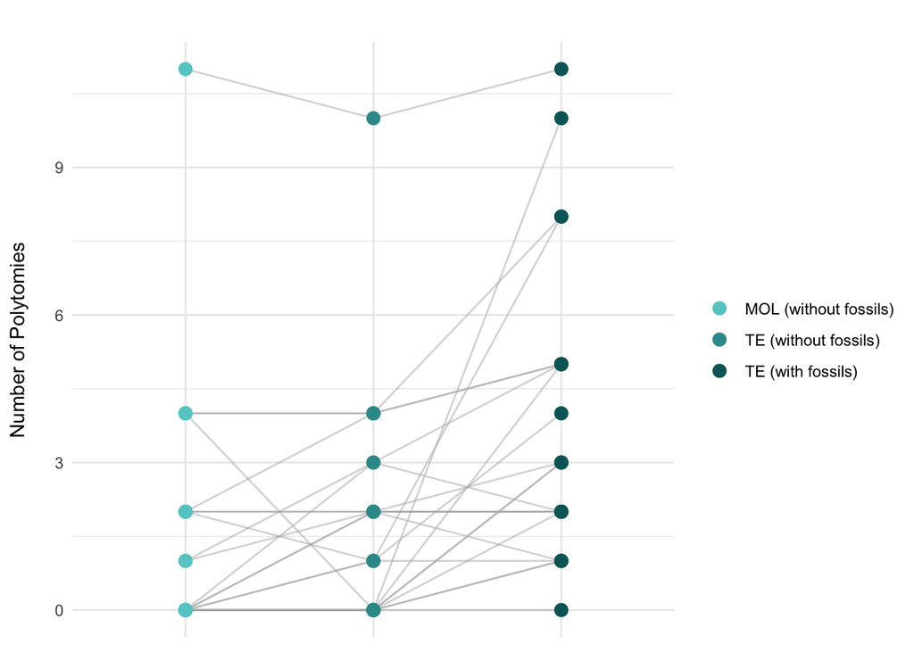

```r
# 7. FIGURE S4
# Add row ID for pairing
df_plot <- df_wide %>%
  mutate(row_id = row_number())
# Convert to long format
df_long <- df_plot %>%
  pivot_longer(
    cols = c(MP_nPolytomiesMOL, MP_nPolytomiesTE, MP_nPolytomiesTE_Extinct),
    names_to = "group",
    values_to = "value"
  )
# Create a factor to order the groups in plotting
df_long$group <- factor(df_long$group, levels = c("MP_nPolytomiesMOL",
                                                  "MP_nPolytomiesTE",
                                                  "MP_nPolytomiesTE_Extinct"))
# Plot paired dots with connecting lines
custom_colors <- c(
  "MP_nPolytomiesTE" = "#339999",         # lightest
  "MP_nPolytomiesMOL" = "#66CCCC",        # light
  "MP_nPolytomiesTE_Extinct" = "#006666" # darker
)
# Custom legend labels
custom_labels <- c(
  "MP_nPolytomiesMOL" = "MOL (without fossils)",
  "MP_nPolytomiesTE" = "TE (without fossils)",
  "MP_nPolytomiesTE_Extinct" = "TE (with fossils)"
)
# Plot with gray lines, colored dots, renamed legend, no x-axis
p = ggplot(df_long, aes(x = group, y = value, group = row_id)) +
  geom_line(color = "gray70", alpha = 0.5) +
  geom_point(aes(color = group), size = 3) +
  theme_minimal() +
  labs(x = NULL, y = "Number of Polytomies\n",
       title = "") +
  theme(
    axis.text.x = element_blank(),
    axis.ticks.x = element_blank()
  ) +
  scale_color_manual(values = custom_colors, labels = custom_labels, name=NULL)
p
```

```r
# Save the plot as JPG, 300 dpi
ggsave(filename = "Figures/figS4_polytomies_MP.jpg",
       plot = p,
       width = 8, height = 5,      # size in inches
       dpi = 300,                   # resolution
       units = "in")
```

## Q3.3 Contribution of phenomic evidence to the TE optimality score

In addition to testing whether MOL-TE incongruences differ between optimaliy criteria, we can explore the impact of phenomic evidence to optimality scores between optimality criteria. Specifically, it is possible that the MKv model can constrain the contribution of the phenomic partition to the TE optimality score in ML, whereas the same does not occur in MP analyses. As such, we need to test whether the proportion of optimality scores between MORPH and TE is higher in MP than ML analyses.

### Q3.3.1 Extant

```r
# Load data for extant taxa
df <- read.csv("Dataset_R_q123_08-25.csv")
df_extant <- df %>% filter(grepl("Extant", Type)) # keep only extant datasets

# Exploratory data analyses
print("Number of times that %MORPH/TE is higher in MP than ML ASC")
```

```
## [1] "Number of times that %MORPH/TE is higher in MP than ML ASC"
```

```r
sum(df_extant$MP_MORPH.TE_Score > df_extant$ML_MORPH.TeASC_Score)
```

```
## [1] 32
```

```r
print("Number of times that %MORPH/TE is lower in MP than ML ASC")
```

```
## [1] "Number of times that %MORPH/TE is lower in MP than ML ASC"
```

```r
sum(df_extant$MP_MORPH.TE_Score < df_extant$ML_MORPH.TeASC_Score)
```

```
## [1] 25
```

```r
print("Number of times that %MORPH/TE is higher in MP than ML noASC")
```

```
## [1] "Number of times that %MORPH/TE is higher in MP than ML noASC"
```

```r
sum(df_extant$MP_MORPH.TE_Score > df_extant$ML_MORPH.TEnoASC_Score)
```

```
## [1] 31
```

```r
print("Number of times that %MORPH/TE is lower in MP than ML noASC")
```

```
## [1] "Number of times that %MORPH/TE is lower in MP than ML noASC"
```

```r
sum(df_extant$MP_MORPH.TE_Score < df_extant$ML_MORPH.TEnoASC_Score)
```

```
## [1] 26
```

```r
print("Stats MP MORPH/TE")
```

```
## [1] "Stats MP MORPH/TE"
```

```r
mean(df_extant$MP_MORPH.TE_Score)
```

```
## [1] 0.07503085
```

```r
sd(df_extant$MP_MORPH.TE_Score)
```

```
## [1] 0.07966847
```

```r
min(df_extant$MP_MORPH.TE_Score)
```

```
## [1] 0.000389759
```

```r
max(df_extant$MP_MORPH.TE_Score)
```

```
## [1] 0.4081309
```

```r
print("Stats ML MKV MORPH/TE")
```

```
## [1] "Stats ML MKV MORPH/TE"
```

```r
mean(df_extant$ML_MORPH.TeASC_Score)
```

```
## [1] 0.06260997
```

```r
sd(df_extant$ML_MORPH.TeASC_Score)
```

```
## [1] 0.06369744
```

```r
min(df_extant$ML_MORPH.TeASC_Score)
```

```
## [1] 5.23e-05
```

```r
max(df_extant$ML_MORPH.TeASC_Score)
```

```
## [1] 0.3929691
```

```r
print("Stats ML MK MORPH/TE")
```

```
## [1] "Stats ML MK MORPH/TE"
```

```r
mean(df_extant$ML_MORPH.TEnoASC_Score)
```

```
## [1] 0.0642674
```

```r
sd(df_extant$ML_MORPH.TEnoASC_Score)
```

```
## [1] 0.06439678
```

```r
min(df_extant$ML_MORPH.TEnoASC_Score)
```

```
## [1] 5.25e-05
```

```r
max(df_extant$ML_MORPH.TEnoASC_Score)
```

```
## [1] 0.3937384
```

```r
# Normality tests
shapiro.test(df_extant$MP_MORPH.TE_Score) # p < 0.05, non-parametric
```

```
##
##  Shapiro-Wilk normality test
##
## data:  df_extant$MP_MORPH.TE_Score
## W = 0.76725, p-value = 4.029e-08
```

```r
shapiro.test(df_extant$ML_MORPH.TeASC_Score) # p < 0.05, non-parametric
```

```
##
##  Shapiro-Wilk normality test
##
## data:  df_extant$ML_MORPH.TeASC_Score
## W = 0.75212, p-value = 1.887e-08
```

```r
shapiro.test(df_extant$ML_MORPH.TEnoASC_Score) # p < 0.05, non-parametric
```

```
##
##  Shapiro-Wilk normality test
##
## data:  df_extant$ML_MORPH.TEnoASC_Score
## W = 0.76455, p-value = 3.511e-08
```

```r
# Friedman test (non-parametric, multiple groups, paired values)
q3_fri = data.frame(df_extant$MP_MORPH.TE_Score, df_extant$ML_MORPH.TeASC_Score, df_extant$ML_MORPH.TEnoASC_Score)
friedman.test(as.matrix(q3_fri))
```

```
##
##  Friedman rank sum test
##
## data:  as.matrix(q3_fri)
## Friedman chi-squared = 20.414, df = 2, p-value = 3.691e-05
```

```r
# Wilcoxon: pairwise comparisons for paired values
pairwise.wilcox.test(x=unlist(q3_fri),
                     g=factor(rep(names(q3_fri), each = nrow(q3_fri))),
                     paired=TRUE,
                     p.adjust.method="bonferroni")
```

```
##
##  Pairwise comparisons using Wilcoxon signed rank test with continuity correction
##
## data:  unlist(q3_fri) and factor(rep(names(q3_fri), each = nrow(q3_fri)))
##
##                                  df_extant.ML_MORPH.TeASC_Score
## df_extant.ML_MORPH.TEnoASC_Score 4.8e-08
## df_extant.MP_MORPH.TE_Score      0.34
##                                  df_extant.ML_MORPH.TEnoASC_Score
## df_extant.ML_MORPH.TEnoASC_Score -
## df_extant.MP_MORPH.TE_Score      0.79
##
## P value adjustment method: bonferroni
```

```r
# Figure
values <- c(df_extant$MP_MORPH.TE_Score, df_extant$ML_MORPH.TeASC_Score, df_extant$ML_MORPH.TEnoASC_Score)
group <- c(rep("MP", length(df_extant$MP_MORPH.TE_Score)),
             rep("ML MKV", length(df_extant$ML_MORPH.TeASC_Score)),
             rep("ML MK", length(df_extant$ML_MORPH.TEnoASC_Score)))
block = rep(1:length(df_extant$MP_MORPH.TE_Score), 3)  # Indices (same length as vectors)
df_nemenyi <- data.frame(value = values, group = group, block=block)
df_nemenyi$group <- factor(df_nemenyi$group, levels = c("MP", "ML MKV", "ML MK"))
custom_palette <- c("MP" = "#339999", "ML MKV" = "#6f77b4", "ML MK" = "#cccccc")

contribution_extant = ggplot(df_nemenyi, aes(x = group, y = value, group = block)) +
  #geom_boxplot(outlier.shape = NA) +  # Create boxplot without default outliers
  geom_line(aes(group = block), color = "black", alpha = 0.1) +  # Link paired values
  geom_point(aes(color = group), alpha = .4, width = 0.2) +  # Add transparent dots
  labs(x = "", y = "% Phenomic/TE optimality score\n") +
  theme_minimal() +
  theme(axis.text.x = element_blank(), legend.position = "bottom", legend.title = element_blank()) +  # Hide legend if not needed
  scale_color_manual(values = custom_palette)
```

### Q3.3.2 Extant + extinct

```r
# Load data for extant taxa
df <- read.csv("Dataset_R_q123_08-25.csv")
df_extinct <- df %>% filter(grepl("Extinct", Type)) # keep only extant datasets

# Exploratory data analyses
print("Number of times that %MORPH/TE is higher in MP than ML ASC")
```

```
## [1] "Number of times that %MORPH/TE is higher in MP than ML ASC"
```

```r
sum(df_extinct$MP_MORPH.TE_Score > df_extinct$ML_MORPH.TeASC_Score)
```

```
## [1] 10
```

```r
print("Number of times that %MORPH/TE is lower in MP than ML ASC")
```

```
## [1] "Number of times that %MORPH/TE is lower in MP than ML ASC"
```

```r
sum(df_extinct$MP_MORPH.TE_Score < df_extinct$ML_MORPH.TeASC_Score)
```

```
## [1] 12
```

```r
print("Number of times that %MORPH/TE is higher in MP than ML noASC")
```

```
## [1] "Number of times that %MORPH/TE is higher in MP than ML noASC"
```

```r
sum(df_extinct$MP_MORPH.TE_Score > df_extinct$ML_MORPH.TEnoASC_Score)
```

```
## [1] 10
```

```r
print("Number of times that %MORPH/TE is lower in MP than ML noASC")
```

```
## [1] "Number of times that %MORPH/TE is lower in MP than ML noASC"
```

```r
sum(df_extinct$MP_MORPH.TE_Score < df_extinct$ML_MORPH.TEnoASC_Score)
```

```
## [1] 12
```

```r
print("Stats MP MORPH/TE")
```

```
## [1] "Stats MP MORPH/TE"
```

```r
mean(df_extinct$MP_MORPH.TE_Score)
```

```
## [1] 0.08229641
```

```r
sd(df_extinct$MP_MORPH.TE_Score)
```

```
## [1] 0.07988527
```

```r
min(df_extinct$MP_MORPH.TE_Score)
```

```
## [1] 0.000605816
```

```r
max(df_extinct$MP_MORPH.TE_Score)
```

```
## [1] 0.3209799
```

```r
print("Stats ML MKV MORPH/TE")
```

```
## [1] "Stats ML MKV MORPH/TE"
```

```r
mean(df_extinct$ML_MORPH.TeASC_Score)
```

```
## [1] 0.07290503
```

```r
sd(df_extinct$ML_MORPH.TeASC_Score)
```

```
## [1] 0.05783672
```

```r
min(df_extinct$ML_MORPH.TeASC_Score)
```

```
## [1] 0.00067116
```

```r
max(df_extinct$ML_MORPH.TeASC_Score)
```

```
## [1] 0.2069809
```

```r
print("Stats ML MK MORPH/TE")
```

```
## [1] "Stats ML MK MORPH/TE"
```

```r
mean(df_extinct$ML_MORPH.TEnoASC_Score)
```

```
## [1] 0.07400197
```

```r
sd(df_extinct$ML_MORPH.TEnoASC_Score)
```

```
## [1] 0.05861277
```

```r
min(df_extinct$ML_MORPH.TEnoASC_Score)
```

```
## [1] 0.000674379
```

```r
max(df_extinct$ML_MORPH.TEnoASC_Score)
```

```
## [1] 0.215919
```

```r
# Normality tests
shapiro.test(df_extinct$MP_MORPH.TE_Score) # p < 0.05, non-parametric
```

```
##
##  Shapiro-Wilk normality test
##
## data:  df_extinct$MP_MORPH.TE_Score
## W = 0.86139, p-value = 0.005434
```

```r
shapiro.test(df_extinct$ML_MORPH.TeASC_Score) # p > 0.05, parametric
```

```
##
##  Shapiro-Wilk normality test
##
## data:  df_extinct$ML_MORPH.TeASC_Score
## W = 0.91232, p-value = 0.05282
```

```r
shapiro.test(df_extinct$ML_MORPH.TEnoASC_Score) # p > 0.05, parametric
```

```
##
##  Shapiro-Wilk normality test
##
## data:  df_extinct$ML_MORPH.TEnoASC_Score
## W = 0.91532, p-value = 0.06086
```

```r
# Friedman test (non-parametric, multiple groups, paired values)
q3_fri = data.frame(df_extinct$MP_MORPH.TE_Score, df_extinct$ML_MORPH.TeASC_Score, df_extinct$ML_MORPH.TEnoASC_Score)
friedman.test(as.matrix(q3_fri))
```

```
##
##  Friedman rank sum test
##
## data:  as.matrix(q3_fri)
## Friedman chi-squared = 4.8372, df = 2, p-value = 0.08905
```

```r
# Wilcoxon: pairwise comparisons for paired values
pairwise.wilcox.test(x=unlist(q3_fri),
                     g=factor(rep(names(q3_fri), each = nrow(q3_fri))),
                     paired=TRUE,
                     p.adjust.method="bonferroni")
```

```
##
##  Pairwise comparisons using Wilcoxon signed rank test with continuity correction
##
## data:  unlist(q3_fri) and factor(rep(names(q3_fri), each = nrow(q3_fri)))
##
##                                   df_extinct.ML_MORPH.TeASC_Score
## df_extinct.ML_MORPH.TEnoASC_Score 0.0029
## df_extinct.MP_MORPH.TE_Score      1.0000
##                                   df_extinct.ML_MORPH.TEnoASC_Score
## df_extinct.ML_MORPH.TEnoASC_Score -
## df_extinct.MP_MORPH.TE_Score      1.0000
##
## P value adjustment method: bonferroni
```

```r
# Figure
values <- c(df_extinct$MP_MORPH.TE_Score, df_extinct$ML_MORPH.TeASC_Score, df_extinct$ML_MORPH.TEnoASC_Score)
group <- c(rep("MP", length(df_extinct$MP_MORPH.TE_Score)),
             rep("ML MKV", length(df_extinct$ML_MORPH.TeASC_Score)),
             rep("ML MK", length(df_extinct$ML_MORPH.TEnoASC_Score)))
block = rep(1:length(df_extinct$MP_MORPH.TE_Score), 3)  # Indices (same length as vectors)
df_nemenyi <- data.frame(value = values, group = group, block=block)
df_nemenyi$group <- factor(df_nemenyi$group, levels = c("MP", "ML MKV", "ML MK"))
custom_palette <- c("MP" = "#339999", "ML MKV" = "#6f77b4", "ML MK" = "#cccccc")

contribution_extinct = ggplot(df_nemenyi, aes(x = group, y = value, group = block)) +
  #geom_boxplot(outlier.shape = NA) +  # Create boxplot without default outliers
  geom_line(aes(group = block), color = "black", alpha = 0.1) +  # Link paired values
  geom_point(aes(color = group), alpha = .4, width = 0.2) +  # Add transparent dots
  labs(x = "", y = "% Phenomic/TE optimality score\n") +
  theme_minimal() +
  theme(axis.text.x = element_blank(), legend.position = "bottom", legend.title = element_blank()) +  # Hide legend if not needed
  scale_color_manual(values = custom_palette)
```

### Q3.3.3 Plot (Figure S5)

```r
s5= plot_grid(contribution_extant,
          contribution_extinct,
          labels = c("A", "B"),   # adds panel labels
          ncol = 1)               # A on top of B
# Save to JPG at 300 dpi
ggsave("Figures/figS5_contributionPhenomic.jpg", s5, dpi = 300,
       width = 6, height = 8, units = "in")  # adjust size
```

# Q4. How do bootstrap values of shared clades differ between MOL and TE trees?

## Q4.1 Unique vs Shared

### Q4.2 With and without fossils (Table 1 and S7, Figure 6)

Before testing the differences of BS values in shared clades between MOL and TE trees, let’s explore the differences of BS values between shared and unique clades.

First, we need to format the extant datasets.

```r
# Load shared clades
df_shared = read.csv ("/Users/labanfibios/Desktop/Doutorado/Project/B2_TEvsMOL/GitHub/Dataset_R_q4_09-25_shared.csv")
# Load unique clades
df_unique = read.csv ("/Users/labanfibios/Desktop/Doutorado/Project/B2_TEvsMOL/GitHub/Dataset_R_q4_09-25_unique.csv")

# Rename the column Analysis to Dataset
df_unique <- df_unique %>%
  rename(Dataset = Analysis)
# Rename the column Method to Optimality
df_unique <- df_unique %>%
  rename(Optimality = Method)
# Rename the column Type to Analysis
df_unique <- df_unique %>%
  rename(Analysis = Type)
# Create a new column called Type (unique vs shared)
df_unique <- df_unique %>%
  dplyr::mutate(Type = "unique")


# Create a new dataframe from df_shared with the selected columns
df_shared_stack <- df_shared %>%
  transmute(
    Dataset = Dataset,
    Analysis = "MOL",                 # new value
    Optimality = Optimality,
    Node = Node_Tree_1,               # take Node_Tree_1
    Support = Support_Tree_1,         # take Support_Tree_1
    Type = "shared"                   # new value
  )
# Bind the new rows below df_unique
df_unique_extended <- bind_rows(df_unique, df_shared_stack)
# Create a new dataframe from df_shared for Tree 2
df_shared_stack2 <- df_shared %>%
  transmute(
    Dataset = Dataset,
    Analysis = "TE",                  # new value for Tree 2
    Optimality = Optimality,
    Node = Node_Tree_2,               # take Node_Tree_2
    Support = Support_Tree_2,         # take Support_Tree_2
    Type = "shared"                   # new value
  )
# Append Tree 2 rows to df_unique_extended (which already contains Tree 1 and unique rows)
df_uniqueVSshared <- bind_rows(df_unique_extended, df_shared_stack2)

# Rename
df_uniqueVSshared <- df_uniqueVSshared %>%
  mutate(
    Optimality = recode(
      Optimality,
      "ML-ASC" = "ML_ASC",
      "ML-noASC" = "ML_noASC"
    )
  )
# Add the column Sampling (without fossils vs with fossils)
df_uniqueVSshared <- df_uniqueVSshared %>%
  mutate(Sampling = "Without_fossils")

#View(df_uniqueVSshared)
```

Now, we need to format the datasets including fossils.

```r
# Load shared clades
df_shared = read.csv ("/Users/labanfibios/Desktop/Doutorado/Project/B2_TEvsMOL/GitHub/Dataset_R_q4_09-25_shared_extinct.csv")
# Load unique clades
df_unique = read.csv ("/Users/labanfibios/Desktop/Doutorado/Project/B2_TEvsMOL/GitHub/Dataset_R_q4_09-25_unique_extinct.csv")

# Rename the column Analysis to Dataset
df_unique <- df_unique %>%
  rename(Dataset = Analysis)
# Rename the column Method to Optimality
df_unique <- df_unique %>%
  rename(Optimality = Method)
# Rename the column Type to Analysis
df_unique <- df_unique %>%
  rename(Analysis = Type)
# Create a new column called Type (unique vs shared)
df_unique <- df_unique %>%
  dplyr::mutate(Type = "unique")

# Create a new dataframe from df_shared with the selected columns
df_shared_stack <- df_shared %>%
  transmute(
    Dataset = Dataset,
    Analysis = "MOL",                 # new value
    Optimality = Optimality,
    Node = Node_Tree_1,               # take Node_Tree_1
    Support = Support_Tree_1,         # take Support_Tree_1
    Type = "shared"                   # new value
  )
# Bind the new rows below df_unique
df_unique_extended <- bind_rows(df_unique, df_shared_stack)
# Create a new dataframe from df_shared for Tree 2
df_shared_stack2 <- df_shared %>%
  transmute(
    Dataset = Dataset,
    Analysis = "TE",                  # new value for Tree 2
    Optimality = Optimality,
    Node = Node_Tree_2,               # take Node_Tree_2
    Support = Support_Tree_2,         # take Support_Tree_2
    Type = "shared"                   # new value
  )
# Append Tree 2 rows to df_unique_extended (which already contains Tree 1 and unique rows)
df_uniqueVSshared_extinct <- bind_rows(df_unique_extended, df_shared_stack2)

# Rename
df_uniqueVSshared_extinct <- df_uniqueVSshared_extinct %>%
  mutate(
    Optimality = recode(
      Optimality,
      "ML-ASC" = "ML_ASC",
      "ML-noASC" = "ML_noASC"
    )
  )
# Add column Sampling (with vs without fossils)
df_uniqueVSshared_extinct <- df_uniqueVSshared_extinct %>%
  mutate(Sampling = "With_fossils")
#View(df_uniqueVSshared_extinct)
```

The dataframes are formatted. Now, we can combine them, perform exploratory data analyses, and plot them.

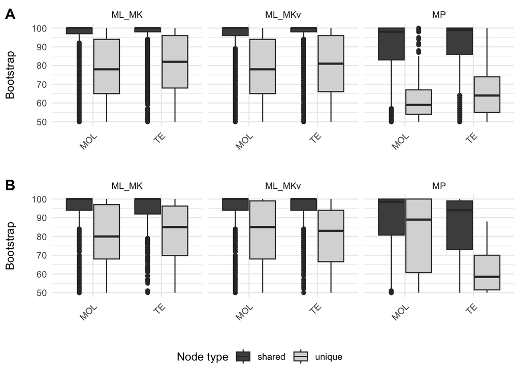

```r
# Combine dataframes with and without fossils
df_combined <- bind_rows(df_uniqueVSshared, df_uniqueVSshared_extinct)
df_combined <- df_combined %>%
  mutate(Optimality = recode(Optimality,
    "ML_ASC"   = "ML_MKv",
    "ML MKv"   = "ML_MKv",
    "ML MKV"   = "ML_MKv",
    "ML_noASC" = "ML_MK",
    "ML MK"    = "ML_MK"
  ))
#View(df_combined)

# Exploratory data analysis
q4_explore = df_combined %>%
  group_by(Analysis, Optimality, Type, Sampling) %>%
  summarise(
    min_Support = min(Support, na.rm = TRUE),
    max_Support = max(Support, na.rm = TRUE),
    mean_Support = mean(Support, na.rm = TRUE),
    sd_Support = sd(Support, na.rm = TRUE),
    .groups = "drop"
  )
#View(q4_explore)

# Rename Optimality
df_combined <- df_combined %>%
  mutate(
    Optimality = recode(
      Optimality,
      "ML_ASC" = "ML MKV",
      "ML_noASC" = "ML MK"
    )
  )

# Create a combined factor for coloring
df_combined <- df_combined %>%
  mutate(
    ColorGroup = paste(Optimality, Type, Analysis, sep = "_")
  )

# common aesthetics / colors
fill_colors <- c("shared" = "#4d4d4d", "unique" = "#d9d9d9")

# Plot A: Without_fossils
pA <- df_combined %>%
  filter(Sampling == "Without_fossils") %>%
  ggplot(aes(x = Analysis, y = Support, fill = Type)) +
  geom_boxplot(position = position_dodge(width = 0.8)) +
  facet_wrap(~ Optimality) +
  scale_fill_manual(values = fill_colors) +
  labs(x = "", y = "Bootstrap\n", fill = "Node type") +
  theme_minimal() +
  theme(axis.text.x = element_text(angle = 45, hjust = 1))

# Plot B: With_fossils
pB <- df_combined %>%
  filter(Sampling == "With_fossils") %>%
  ggplot(aes(x = Analysis, y = Support, fill = Type)) +
  geom_boxplot(position = position_dodge(width = 0.8)) +
  facet_wrap(~ Optimality) +
  scale_fill_manual(values = fill_colors) +
  labs(x = "", y = "Bootstrap\n", fill = "Node type") +
  theme_minimal() +
  theme(axis.text.x = element_text(angle = 45, hjust = 1))

# Arrange side-by-side with labels A and B in upper-left
figure <- ggarrange(
  pA, pB,
  ncol = 1, nrow = 2,
  common.legend = TRUE, legend = "bottom",
  labels = c("A", "B"),
  label.x = 0.0,        # x position of labels (left)
  label.y = 0.98,        # y position of labels (top)
  font.label = list(size = 14)
)
figure
```

```r
#ggsave("Figures/Fig6_BS_uniqueVSshared.jpg", plot = figure, width = 6, height = 6, units = "in", dpi = 300)
```

We can statistically test whether bootstrap values differ between shared and unique clades, considering Type (categorical predictor: unique vs shared), Sampling (categorical predictor: Without_fossils vs With_fossils), Optimality (categorical predictor: MP vs ML_ASC vs ML_noASC), Analysis (categorical predictor: MOL vs TE). We will use both traditional non-parametric tests and GLMs.

```r
# Fix: Squeeze Support into (0,1) for GLMM with Beta distribution
df_combined <- df_combined %>%
  mutate(Support_beta = (Support + 0.5) / 101)

# Split datasets
df_without <- df_combined %>% filter(Sampling == "Without_fossils")
df_with    <- df_combined %>% filter(Sampling == "With_fossils")

# --- Helper function for classical non-parametric tests ---
run_nonparametric_tests <- function(df) {
  results <- list()

  # 1. Kruskal-Wallis for Type, Optimality, Analysis
  results$kw_type <- kruskal_test(df, Support ~ Type)
  results$kw_opt  <- kruskal_test(df, Support ~ Optimality)
  results$kw_an   <- kruskal_test(df, Support ~ Analysis)

  # 2. Pairwise Wilcoxon for Type by Optimality & Analysis
  pw_list <- list()

  for(opt in unique(df$Optimality)){
    for(an in unique(df$Analysis)){
      subset_df <- df %>% filter(Optimality == opt, Analysis == an)
      test_res <- pairwise_wilcox_test(
        subset_df,
        Support ~ Type,
        p.adjust.method = "bonferroni"
      )
      test_res <- test_res %>% mutate(Optimality = opt, Analysis = an)
      pw_list[[paste(opt, an, sep = "_")]] <- test_res
    }
  }

  results$pairwise <- bind_rows(pw_list)
  return(results)
}

# Function to summarize mean, sd, min, max
summarize_support <- function(df) {
  df %>%
    group_by(Optimality, Analysis, Type) %>%
    summarise(
      n    = n(),
      mean = mean(Support, na.rm = TRUE),
      sd   = sd(Support, na.rm = TRUE),
      min  = min(Support, na.rm = TRUE),
      max  = max(Support, na.rm = TRUE),
      .groups = "drop"
    )
}


# All combinations to test
combinations <- expand.grid(
  Optimality = c("MP", "ML_MK", "ML_MKv"),
  Analysis = c("MOL", "TE"),
  stringsAsFactors = FALSE
)

# Function to run pairwise GLMM for one subset
run_pairwise <- function(df_subset) {
  results <- list()

  for (i in 1:nrow(combinations)) {
    opt <- combinations$Optimality[i]
    ana <- combinations$Analysis[i]

    df_sub <- df_subset %>%
      filter(Optimality == opt, Analysis == ana)

    if (nrow(df_sub) > 0) {
      # Fit beta GLMM
      glmm <- glmmTMB(
        Support_beta ~ Type + (1|Dataset),
        family = beta_family(link = "logit"),
        data = df_sub
      )

      # Pairwise comparisons for Type
      em <- emmeans(glmm, ~ Type)
      pw <- pairs(em, adjust = "bonferroni")

      results[[paste(opt, ana, sep = "_")]] <- summary(pw)
    }
  }

  bind_rows(results, .id = "Comparison")
}

run_pairwise_df <- function(df_subset, combinations_df, rand = "(1|Dataset)") {
  out_list <- list()
  for(i in seq_len(nrow(combinations_df))) {
    opt <- combinations_df$Optimality[i]
    ana <- combinations_df$Analysis[i]
    df_sub <- df_subset %>% filter(Optimality == opt, Analysis == ana)

    # need at least two Type levels and some rows
    if(nrow(df_sub) < 4 || length(unique(df_sub$Type)) < 2) {
      warning(sprintf("Skipping %s_%s: insufficient data (n=%d, types=%s)",
                      opt, ana, nrow(df_sub), paste(unique(df_sub$Type), collapse=", ")))
      next
    }

    # Fit model safely
    glmm <- try(
      glmmTMB(Support_beta ~ Type + (1|Dataset), data = df_sub, family = beta_family(link="logit")),
      silent = TRUE
    )
    if(inherits(glmm, "try-error")) {
      warning(sprintf("Model failed for %s_%s: %s", opt, ana, attr(glmm, "condition")$message))
      next
    }

    # emmeans and pairwise contrasts
    em <- try(emmeans(glmm, ~ Type), silent = TRUE)
    if(inherits(em, "try-error")) {
      warning(sprintf("emmeans failed for %s_%s", opt, ana))
      next
    }
    pw <- try(pairs(em, adjust = "bonferroni"), silent = TRUE)
    if(inherits(pw, "try-error")) {
      warning(sprintf("pairs() failed for %s_%s", opt, ana))
      next
    }

    # convert to data.frame to get exact numeric p-values
    pw_df <- as.data.frame(pw)
    # add context columns
    pw_df <- pw_df %>%
      mutate(
        Optimality = opt,
        Analysis   = ana,
        Comparison = rownames(pw_df)  # usually "unique - shared" or similar
      ) %>%
      select(Optimality, Analysis, Comparison, everything())

    out_list[[paste(opt, ana, sep = "_")]] <- pw_df
  }

  if(length(out_list) == 0) return(tibble())
  res <- bind_rows(out_list, .id = "id")

  # Add nicely formatted p-values:
  res <- res %>%
    mutate(
      p.value_numeric = as.numeric(p.value),
      p.value_fmt = ifelse(
        is.na(p.value_numeric), NA,
        ifelse(p.value_numeric < 0.001,
               formatC(p.value_numeric, format = "e", digits = 2),           # scientific for <0.001
               formatC(p.value_numeric, format = "f", digits = 3))           # 3 decimals otherwise
    ))

  return(res)
}
```

```r
# Table S7

print("Mean, sd, and range of BS without fossils")
```

```
## [1] "Mean, sd, and range of BS without fossils"
```

```r
summary_without <- summarize_support(df_without)
summary_without
```

```
## # A tibble: 12 × 8
##    Optimality Analysis Type       n  mean    sd   min   max
##    <chr>      <chr>    <chr>  <int> <dbl> <dbl> <int> <int>
##  1 ML_MK      MOL      shared  2676  95.2 10.3     50   100
##  2 ML_MK      MOL      unique   346  78.4 16.1     50   100
##  3 ML_MK      TE       shared  2676  96.2  8.94    50   100
##  4 ML_MK      TE       unique   360  80.0 16.4     50   100
##  5 ML_MKv     MOL      shared  2698  95.0 10.4     50   100
##  6 ML_MKv     MOL      unique   335  78.1 15.9     50   100
##  7 ML_MKv     TE       shared  2698  96.1  9.13    50   100
##  8 ML_MKv     TE       unique   354  79.3 16.2     50   100
##  9 MP         MOL      shared  2279  90.0 14.2     50   100
## 10 MP         MOL      unique   147  62.8 12.3     50   100
## 11 MP         TE       shared  2279  91.0 13.6     50   100
## 12 MP         TE       unique   201  66.3 13.3     50   100
```

```r
results_without <- run_nonparametric_tests(df_without)
print("Non-parametric Wilcoxon tests: Unique vs Shared BS (without fossils)")
```

```
## [1] "Non-parametric Wilcoxon tests: Unique vs Shared BS (without fossils)"
```

```r
results_without$pairwise
```

```
## # A tibble: 6 × 11
##   .y.     group1 group2    n1    n2 statistic         p     p.adj p.adj.signif
##   <chr>   <chr>  <chr>  <int> <int>     <dbl>     <dbl>     <dbl> <chr>
## 1 Support shared unique  2279   147   302092. 9.26e- 63 9.26e- 63 ****
## 2 Support shared unique  2279   201   406281  2.88e- 78 2.88e- 78 ****
## 3 Support shared unique  2698   335   763512. 1.68e-113 1.68e-113 ****
## 4 Support shared unique  2698   354   827194. 1.80e-140 1.80e-140 ****
## 5 Support shared unique  2676   346   779436. 5.96e-115 5.96e-115 ****
## 6 Support shared unique  2676   360   827588. 9.41e-138 9.41e-138 ****
## # ℹ 2 more variables: Optimality <chr>, Analysis <chr>
```

```r
print("GLMM with Beta distribution (without fossils")
```

```
## [1] "GLMM with Beta distribution (without fossils"
```

```r
# Run for Without_fossils
pairwise_without_df <- run_pairwise_df(df_without, combinations)
# View results: numeric and formatted p-values
pairwise_without_df %>%
  select(Optimality, Analysis, Comparison, estimate, SE, df, p.value_fmt)
```

```
##   Optimality Analysis Comparison estimate         SE  df p.value_fmt
## 1         MP      MOL          1 1.615174 0.07649441 Inf    5.80e-99
## 2      ML_MK      MOL          1 1.394313 0.05323900 Inf   3.48e-151
## 3     ML_MKv      MOL          1 1.405540 0.05416986 Inf   1.97e-148
## 4         MP       TE          1 1.606377 0.06580227 Inf   1.27e-131
## 5      ML_MK       TE          1 1.365269 0.05113163 Inf   4.57e-157
## 6     ML_MKv       TE          1 1.416233 0.05143349 Inf   6.65e-167
```

```r
# Table S7
print("Mean, sd, and range of BS with fossils")
```

```
## [1] "Mean, sd, and range of BS with fossils"
```

```r
summary_with <- summarize_support(df_with)
summary_with
```

```
## # A tibble: 12 × 8
##    Optimality Analysis Type       n  mean    sd   min   max
##    <chr>      <chr>    <chr>  <int> <dbl> <dbl> <int> <int>
##  1 ML_MK      MOL      shared   909  93.4  12.2    50   100
##  2 ML_MK      MOL      unique   123  80.5  17.1    50   100
##  3 ML_MK      TE       shared   909  94.0  10.6    50   100
##  4 ML_MK      TE       unique   152  81.8  14.9    50   100
##  5 ML_MKv     MOL      shared   905  93.5  12.2    50   100
##  6 ML_MKv     MOL      unique   129  81.3  17.2    50   100
##  7 ML_MKv     TE       shared   905  94.4  10.3    50   100
##  8 ML_MKv     TE       unique   167  80.6  15.1    50   100
##  9 MP         MOL      shared   684  89.4  14.8    50   100
## 10 MP         MOL      unique   172  81.5  18.9    50   100
## 11 MP         TE       shared   684  86.0  15.9    50   100
## 12 MP         TE       unique    34  62.2  11.5    50    88
```

```r
print("Non-parametric Wilcoxon tests: Unique vs Shared BS (with fossils)")
```

```
## [1] "Non-parametric Wilcoxon tests: Unique vs Shared BS (with fossils)"
```

```r
results_with    <- run_nonparametric_tests(df_with)
results_with$pairwise
```

```
## # A tibble: 6 × 11
##   .y.     group1 group2    n1    n2 statistic        p    p.adj p.adj.signif
##   <chr>   <chr>  <chr>  <int> <int>     <dbl>    <dbl>    <dbl> <chr>
## 1 Support shared unique   684   172    72390. 1.7 e- 6 1.7 e- 6 ****
## 2 Support shared unique   684    34    20205  2.41e-13 2.41e-13 ****
## 3 Support shared unique   905   129    85817  4.42e-21 4.42e-21 ****
## 4 Support shared unique   905   167   121446. 8.58e-40 8.58e-40 ****
## 5 Support shared unique   909   123    84110. 4.36e-23 4.36e-23 ****
## 6 Support shared unique   909   152   108582. 1.36e-32 1.36e-32 ****
## # ℹ 2 more variables: Optimality <chr>, Analysis <chr>
```

```r
print("GLMM with Beta distribution (without fossils")
```

```
## [1] "GLMM with Beta distribution (without fossils"
```

```r
# Run for Without_fossils
pairwise_with_df <- run_pairwise_df(df_with, combinations)
# View results: numeric and formatted p-values
pairwise_with_df %>%
  select(Optimality, Analysis, Comparison, estimate, SE, df, p.value_fmt)
```

```
##   Optimality Analysis Comparison  estimate         SE  df p.value_fmt
## 1         MP      MOL          1 0.6447786 0.10166942 Inf    2.27e-10
## 2      ML_MK      MOL          1 1.0457582 0.09895961 Inf    4.21e-26
## 3     ML_MKv      MOL          1 0.9870390 0.09788365 Inf    6.52e-24
## 4         MP       TE          1 1.2198366 0.16305441 Inf    7.37e-14
## 5      ML_MK       TE          1 0.9246820 0.08623322 Inf    7.94e-27
## 6     ML_MKv       TE          1 1.0696336 0.08222828 Inf    1.10e-38
```

As expected, bootstrap values of unique clades are statistically lower than those from shared clades.

### Q4.1.2 Reduced (Table S10)

Now, we include only the reduced dataset of extant data (including only the datasets for which fossils are available, but now excluding fossils).

```r
# Load shared clades
df_shared = read.csv ("/Users/labanfibios/Desktop/Doutorado/Project/B2_TEvsMOL/GitHub/Dataset_R_q4_09-25_shared.csv")
# Load unique clades
df_unique = read.csv ("/Users/labanfibios/Desktop/Doutorado/Project/B2_TEvsMOL/GitHub/Dataset_R_q4_09-25_unique.csv")

# Keep the datasets for which fossils are available
df_shared <- df_shared[df_shared$Dataset %in% c(3, 7, 8, 9, 10, 11, 13, 17, 21, 24, 28, 29, 31, 38, 39, 40, 42, 46, 48, 52, 54, 57), ]
df_unique <- df_unique[df_unique$Analysis %in% c(3, 7, 8, 9, 10, 11, 13, 17, 21, 24, 28, 29, 31, 38, 39, 40, 42, 46, 48, 52, 54, 57), ]

# Rename the column Analysis to Dataset
df_unique <- df_unique %>%
  rename(Dataset = Analysis)
# Rename the column Method to Optimality
df_unique <- df_unique %>%
  rename(Optimality = Method)
# Rename the column Type to Analysis
df_unique <- df_unique %>%
  rename(Analysis = Type)
# Create a new column called Type (unique vs shared)
df_unique <- df_unique %>%
  dplyr::mutate(Type = "unique")


# Create a new dataframe from df_shared with the selected columns
df_shared_stack <- df_shared %>%
  transmute(
    Dataset = Dataset,
    Analysis = "MOL",                 # new value
    Optimality = Optimality,
    Node = Node_Tree_1,               # take Node_Tree_1
    Support = Support_Tree_1,         # take Support_Tree_1
    Type = "shared"                   # new value
  )
# Bind the new rows below df_unique
df_unique_extended <- bind_rows(df_unique, df_shared_stack)
# Create a new dataframe from df_shared for Tree 2
df_shared_stack2 <- df_shared %>%
  transmute(
    Dataset = Dataset,
    Analysis = "TE",                  # new value for Tree 2
    Optimality = Optimality,
    Node = Node_Tree_2,               # take Node_Tree_2
    Support = Support_Tree_2,         # take Support_Tree_2
    Type = "shared"                   # new value
  )
# Append Tree 2 rows to df_unique_extended (which already contains Tree 1 and unique rows)
df_uniqueVSshared_reduced <- bind_rows(df_unique_extended, df_shared_stack2)

# Rename
df_uniqueVSshared_reduced <- df_uniqueVSshared_reduced %>%
  mutate(
    Optimality = recode(
      Optimality,
      "ML-ASC" = "ML_ASC",
      "ML-noASC" = "ML_noASC"
    )
  )
# Add the column Sampling (without fossils vs with fossils)
df_uniqueVSshared_reduced <- df_uniqueVSshared_reduced %>%
  mutate(Sampling = "Without_fossils")

#View(df_uniqueVSshared_reduced)

# Combine dataframes with and without fossils
df_combined <- bind_rows(df_uniqueVSshared_reduced, df_uniqueVSshared_extinct)
df_combined <- df_combined %>%
  mutate(Optimality = recode(Optimality,
    "ML_ASC"   = "ML_MKv",
    "ML MKv"   = "ML_MKv",
    "ML MKV"   = "ML_MKv",
    "ML_noASC" = "ML_MK",
    "ML MK"    = "ML_MK"
  ))
#View(df_combined)

# Exploratory data analysis
q4_explore = df_combined %>%
  group_by(Analysis, Optimality, Type, Sampling) %>%
  summarise(
    min_Support = min(Support, na.rm = TRUE),
    max_Support = max(Support, na.rm = TRUE),
    mean_Support = mean(Support, na.rm = TRUE),
    sd_Support = sd(Support, na.rm = TRUE),
    .groups = "drop"
  )
#View(q4_explore)

# Rename Optimality
df_combined <- df_combined %>%
  mutate(
    Optimality = recode(
      Optimality,
      "ML_ASC" = "ML MKV",
      "ML_noASC" = "ML MK"
    )
  )

# Fix: Squeeze Support into (0,1) for GLMM with Beta distribution
df_combined <- df_combined %>%
  mutate(Support_beta = (Support + 0.5) / 101)

# Split datasets
df_without <- df_combined %>% filter(Sampling == "Without_fossils")
df_with    <- df_combined %>% filter(Sampling == "With_fossils")

# --- Helper function for classical non-parametric tests ---
run_nonparametric_tests <- function(df) {
  results <- list()

  # 1. Kruskal-Wallis for Type, Optimality, Analysis
  results$kw_type <- kruskal_test(df, Support ~ Type)
  results$kw_opt  <- kruskal_test(df, Support ~ Optimality)
  results$kw_an   <- kruskal_test(df, Support ~ Analysis)

  # 2. Pairwise Wilcoxon for Type by Optimality & Analysis
  pw_list <- list()

  for(opt in unique(df$Optimality)){
    for(an in unique(df$Analysis)){
      subset_df <- df %>% filter(Optimality == opt, Analysis == an)
      test_res <- pairwise_wilcox_test(
        subset_df,
        Support ~ Type,
        p.adjust.method = "bonferroni"
      )
      test_res <- test_res %>% mutate(Optimality = opt, Analysis = an)
      pw_list[[paste(opt, an, sep = "_")]] <- test_res
    }
  }

  results$pairwise <- bind_rows(pw_list)
  return(results)
}

# Function to summarize mean, sd, min, max
summarize_support <- function(df) {
  df %>%
    group_by(Optimality, Analysis, Type) %>%
    summarise(
      n    = n(),
      mean = mean(Support, na.rm = TRUE),
      sd   = sd(Support, na.rm = TRUE),
      min  = min(Support, na.rm = TRUE),
      max  = max(Support, na.rm = TRUE),
      .groups = "drop"
    )
}


# All combinations to test
combinations <- expand.grid(
  Optimality = c("MP", "ML_MK", "ML_MKv"),
  Analysis = c("MOL", "TE"),
  stringsAsFactors = FALSE
)

# Function to run pairwise GLMM for one subset
run_pairwise <- function(df_subset) {
  results <- list()

  for (i in 1:nrow(combinations)) {
    opt <- combinations$Optimality[i]
    ana <- combinations$Analysis[i]

    df_sub <- df_subset %>%
      filter(Optimality == opt, Analysis == ana)

    if (nrow(df_sub) > 0) {
      # Fit beta GLMM
      glmm <- glmmTMB(
        Support_beta ~ Type + (1|Dataset),
        family = beta_family(link = "logit"),
        data = df_sub
      )

      # Pairwise comparisons for Type
      em <- emmeans(glmm, ~ Type)
      pw <- pairs(em, adjust = "bonferroni")

      results[[paste(opt, ana, sep = "_")]] <- summary(pw)
    }
  }

  bind_rows(results, .id = "Comparison")
}

run_pairwise_df <- function(df_subset, combinations_df, rand = "(1|Dataset)") {
  out_list <- list()
  for(i in seq_len(nrow(combinations_df))) {
    opt <- combinations_df$Optimality[i]
    ana <- combinations_df$Analysis[i]
    df_sub <- df_subset %>% filter(Optimality == opt, Analysis == ana)

    # need at least two Type levels and some rows
    if(nrow(df_sub) < 4 || length(unique(df_sub$Type)) < 2) {
      warning(sprintf("Skipping %s_%s: insufficient data (n=%d, types=%s)",
                      opt, ana, nrow(df_sub), paste(unique(df_sub$Type), collapse=", ")))
      next
    }

    # Fit model safely
    glmm <- try(
      glmmTMB(Support_beta ~ Type + (1|Dataset), data = df_sub, family = beta_family(link="logit")),
      silent = TRUE
    )
    if(inherits(glmm, "try-error")) {
      warning(sprintf("Model failed for %s_%s: %s", opt, ana, attr(glmm, "condition")$message))
      next
    }

    # emmeans and pairwise contrasts
    em <- try(emmeans(glmm, ~ Type), silent = TRUE)
    if(inherits(em, "try-error")) {
      warning(sprintf("emmeans failed for %s_%s", opt, ana))
      next
    }
    pw <- try(pairs(em, adjust = "bonferroni"), silent = TRUE)
    if(inherits(pw, "try-error")) {
      warning(sprintf("pairs() failed for %s_%s", opt, ana))
      next
    }

    # convert to data.frame to get exact numeric p-values
    pw_df <- as.data.frame(pw)
    # add context columns
    pw_df <- pw_df %>%
      mutate(
        Optimality = opt,
        Analysis   = ana,
        Comparison = rownames(pw_df)  # usually "unique - shared" or similar
      ) %>%
      select(Optimality, Analysis, Comparison, everything())

    out_list[[paste(opt, ana, sep = "_")]] <- pw_df
  }

  if(length(out_list) == 0) return(tibble())
  res <- bind_rows(out_list, .id = "id")

  # Add nicely formatted p-values:
  res <- res %>%
    mutate(
      p.value_numeric = as.numeric(p.value),
      p.value_fmt = ifelse(
        is.na(p.value_numeric), NA,
        ifelse(p.value_numeric < 0.001,
               formatC(p.value_numeric, format = "e", digits = 2),           # scientific for <0.001
               formatC(p.value_numeric, format = "f", digits = 3))           # 3 decimals otherwise
    ))

  return(res)
}


# Table S10

print("Mean, sd, and range of BS without fossils")
```

```
## [1] "Mean, sd, and range of BS without fossils"
```

```r
summary_without <- summarize_support(df_without)
summary_without
```

```
## # A tibble: 12 × 8
##    Optimality Analysis Type       n  mean    sd   min   max
##    <chr>      <chr>    <chr>  <int> <dbl> <dbl> <int> <int>
##  1 ML_MK      MOL      shared   934  93.6 12.0     50   100
##  2 ML_MK      MOL      unique   111  79.8 17.0     50   100
##  3 ML_MK      TE       shared   934  96.0  9.66    50   100
##  4 ML_MK      TE       unique   129  81.4 15.9     50   100
##  5 ML_MKv     MOL      shared   937  93.4 12.2     50   100
##  6 ML_MKv     MOL      unique   112  79.5 17.0     50   100
##  7 ML_MKv     TE       shared   937  95.8  9.68    50   100
##  8 ML_MKv     TE       unique   129  80.9 15.5     50   100
##  9 MP         MOL      shared   805  89.3 14.8     50   100
## 10 MP         MOL      unique    51  63.2 13.9     50    99
## 11 MP         TE       shared   805  90.9 13.7     50   100
## 12 MP         TE       unique    73  64.8 11.2     50    94
```

```r
results_without <- run_nonparametric_tests(df_without)
print("Non-parametric Wilcoxon tests: Unique vs Shared BS (without fossils)")
```

```
## [1] "Non-parametric Wilcoxon tests: Unique vs Shared BS (without fossils)"
```

```r
results_without$pairwise
```

```
## # A tibble: 6 × 11
##   .y.     group1 group2    n1    n2 statistic        p    p.adj p.adj.signif
##   <chr>   <chr>  <chr>  <int> <int>     <dbl>    <dbl>    <dbl> <chr>
## 1 Support shared unique   805    51    36372. 2.99e-21 2.99e-21 ****
## 2 Support shared unique   805    73    53232. 2.99e-32 2.99e-32 ****
## 3 Support shared unique   937   112    81843  5.46e-26 5.46e-26 ****
## 4 Support shared unique   937   129   104226. 4.27e-51 4.27e-51 ****
## 5 Support shared unique   934   111    80362. 5.01e-25 5.01e-25 ****
## 6 Support shared unique   934   129   102372. 4.91e-48 4.91e-48 ****
## # ℹ 2 more variables: Optimality <chr>, Analysis <chr>
```

```r
print("GLMM with Beta distribution (without fossils")
```

```
## [1] "GLMM with Beta distribution (without fossils"
```

```r
# Run for Without_fossils
pairwise_without_df <- run_pairwise_df(df_without, combinations)
# View results: numeric and formatted p-values
pairwise_without_df %>%
  select(Optimality, Analysis, Comparison, estimate, SE, df, p.value_fmt)
```

```
##   Optimality Analysis Comparison estimate         SE  df p.value_fmt
## 1         MP      MOL          1 1.563567 0.13379927 Inf    1.50e-31
## 2      ML_MK      MOL          1 1.166914 0.10413762 Inf    3.83e-29
## 3     ML_MKv      MOL          1 1.196130 0.10406053 Inf    1.40e-30
## 4         MP       TE          1 1.745794 0.10932905 Inf    2.13e-57
## 5      ML_MK       TE          1 1.389174 0.09320612 Inf    3.09e-50
## 6     ML_MKv       TE          1 1.437376 0.09036581 Inf    5.74e-57
```

## Q4.2 MOL vs TE (Table 4)

### Q4.2.1 Extant

First, we need to load the data. Support values of shared clades were identified and organized using the package RNODE.

```r
# Load data (BS shared clades)
df_q4 = read.csv("Dataset_R_q4_09-25_shared.csv")

# Set order of optimality criteria
df_q4$Optimality <- factor(df_q4$Optimality, levels = c("MP", "ML-ASC", "ML-noASC"))
df_q4$SupportDiff = df_q4$Support_Tree_1 - df_q4$Support_Tree_2
```

For each optimality criterion, we tested whether the paired values of bootstrap of shared clades differ between MOL and TE trees. First, we computed the number of clades in which bootstrap values were the same in MOL and TE trees, higher in MOL than TE trees, or higher in TE than MOL trees. Next, we tested the normality of bootstrap values using Shapiro-Wilk tests. Finally, we used both the non-parametric Wilcoxon signed-rank and Generalized Linear Mixed Models.

#### Q4.2.1.1 MP MOL vs MP TE

```r
# Filter dataset keeping only MP
df_MP <- df_q4[grepl("MP", df_q4$Optimality), ]

# Exploratory data analysis
print("Mean BS in MP MOL")
```

```
## [1] "Mean BS in MP MOL"
```

```r
mean(df_MP$Support_Tree_1) # MOL
```

```
## [1] 89.9706
```

```r
print("Standard deviation BS in MP MOL")
```

```
## [1] "Standard deviation BS in MP MOL"
```

```r
sd(df_MP$Support_Tree_1) # MOL
```

```
## [1] 14.21655
```

```r
print("Min BS in MP MOL")
```

```
## [1] "Min BS in MP MOL"
```

```r
min(df_MP$Support_Tree_1) # MOL
```

```
## [1] 50
```

```r
print("Max BS in MP MOL")
```

```
## [1] "Max BS in MP MOL"
```

```r
max(df_MP$Support_Tree_1) # MOL
```

```
## [1] 100
```

```r
print("Mean BS in MP TE")
```

```
## [1] "Mean BS in MP TE"
```

```r
mean(df_MP$Support_Tree_2) # TE
```

```
## [1] 91.00088
```

```r
print("Standard deviation BS in MP TE")
```

```
## [1] "Standard deviation BS in MP TE"
```

```r
sd(df_MP$Support_Tree_2) # TE
```

```
## [1] 13.62147
```

```r
print("Min BS in MP TE")
```

```
## [1] "Min BS in MP TE"
```

```r
min(df_MP$Support_Tree_2) # TE
```

```
## [1] 50
```

```r
print("Max BS in MP TE")
```

```
## [1] "Max BS in MP TE"
```

```r
max(df_MP$Support_Tree_2) # TE
```

```
## [1] 100
```

```r
print("Total no. shared clades between MOL and TE")
```

```
## [1] "Total no. shared clades between MOL and TE"
```

```r
nrow(df_MP)
```

```
## [1] 2279
```

```r
print("No. shared clades with BS MOL == BS TE")
```

```
## [1] "No. shared clades with BS MOL == BS TE"
```

```r
sum(df_MP$Support_Tree_1 == df_MP$Support_Tree_2)
```

```
## [1] 1093
```

```r
print("No. shared clades with BS MOL > BS TE")
```

```
## [1] "No. shared clades with BS MOL > BS TE"
```

```r
sum(df_MP$Support_Tree_1 > df_MP$Support_Tree_2)
```

```
## [1] 445
```

```r
print("No. shared clades with BS MOL < BS TE")
```

```
## [1] "No. shared clades with BS MOL < BS TE"
```

```r
sum(df_MP$Support_Tree_1 < df_MP$Support_Tree_2)
```

```
## [1] 741
```

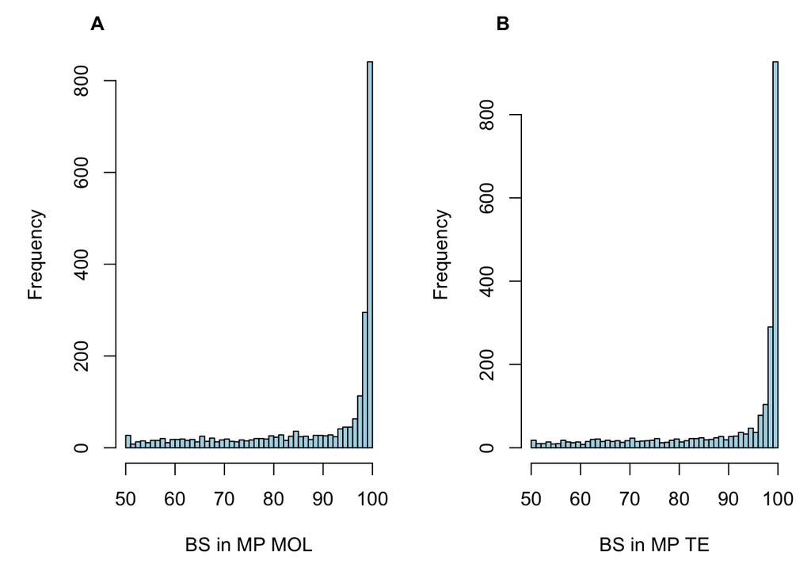

```r
# Histograms
par(mfrow = c(1, 2), mar = c(5, 5, 2, 1))  # adjust margins
# Histogram MP MOL
hist(df_MP$Support_Tree_1, breaks = 40, col = "lightblue", xlab = "BS in MP MOL", main="")
# A
mtext("A", side = 3, line = 0.5, adj = -0.1, font = 2)
# Histogram MP TE
hist(df_MP$Support_Tree_2, breaks = 40, col = "lightblue", xlab = "BS in MP TE", main="")
# B
mtext("B", side = 3, line = 0.5, adj = -0.1, font = 2)
```

```r
# Shapiro-Wilk test for normality
shapiro.test(df_MP$Support_Tree_1) # P < 0.05, non-parametric
```

```
##
##  Shapiro-Wilk normality test
##
## data:  df_MP$Support_Tree_1
## W = 0.73277, p-value < 2.2e-16
```

```r
shapiro.test(df_MP$Support_Tree_2) # P < 0.05, non-parametric
```

```
##
##  Shapiro-Wilk normality test
##
## data:  df_MP$Support_Tree_2
## W = 0.70318, p-value < 2.2e-16
```

```r
# Perform the Wilcoxon signed-rank test for paired values
wilcox.test(as.numeric(df_MP$Support_Tree_1),
                           as.numeric(df_MP$Support_Tree_2),
                           paired = TRUE)
```

```
##
##  Wilcoxon signed rank test with continuity correction
##
## data:  as.numeric(df_MP$Support_Tree_1) and as.numeric(df_MP$Support_Tree_2)
## V = 251754, p-value < 2.2e-16
## alternative hypothesis: true location shift is not equal to 0
```

```r
# Dataset for GLMMs
df_MP_glmm <- data.frame(
  Node = c(df_MP$Node_Tree_1, df_MP$Node_Tree_2),
  Approach = c(df_MP$Approach1, df_MP$Approach2),
  Support = c(df_MP$Support_Tree_1, df_MP$Support_Tree_2),
  ID = c(df_MP$ID, df_MP$ID)
)

# GLMM Beta
# Step 1. Scale Support from 0–100 to 0–1
df_MP_glmm <- df_MP_glmm %>%
  mutate(Support_prop = Support / 100)
# Beta regression does not allow exact 0 or 1
n <- nrow(df_MP_glmm)
df_MP_glmm <- df_MP_glmm %>%
  mutate(Support_beta = (Support_prop * (n - 1) + 0.5) / n)
mp_beta <- glmmTMB(Support_beta ~ Approach + (1 | ID),
                 family = beta_family(link = "logit"),
                 data = df_MP_glmm)
summary(mp_beta)
```

```
##  Family: beta  ( logit )
## Formula:          Support_beta ~ Approach + (1 | ID)
## Data: df_MP_glmm
##
##      AIC      BIC   logLik deviance df.resid
## -25456.4 -25430.7  12732.2 -25464.4     4554
##
## Random effects:
##
## Conditional model:
##  Groups Name        Variance Std.Dev.
##  ID     (Intercept) 3.229    1.797
## Number of obs: 4558, groups:  ID, 2279
##
## Dispersion parameter for beta family (): 35.9
##
## Conditional model:
##             Estimate Std. Error z value Pr(>|z|)
## (Intercept)  3.34667    0.04338   77.14  < 2e-16 ***
## ApproachTE   0.13578    0.01737    7.82 5.39e-15 ***
## ---
## Signif. codes:  0 '***' 0.001 '**' 0.01 '*' 0.05 '.' 0.1 ' ' 1
```

#### Q4.2.1.2 ML MOL vs ML TE ASC

```r
# Filter dataset keeping only ML ASC
df_MLASC <- df_q4[grepl("ML-ASC", df_q4$Optimality), ]

# Exploratory data analysis
print("Mean BS in ML MOL")
```

```
## [1] "Mean BS in ML MOL"
```

```r
mean(df_MLASC$Support_Tree_1) # MOL
```

```
## [1] 95.0341
```

```r
print("Standard deviation BS in MP MOL")
```

```
## [1] "Standard deviation BS in MP MOL"
```

```r
sd(df_MLASC$Support_Tree_1) # MOL
```

```
## [1] 10.43931
```

```r
print("Min BS in ML MOL")
```

```
## [1] "Min BS in ML MOL"
```

```r
min(df_MLASC$Support_Tree_1) # MOL
```

```
## [1] 50
```

```r
print("Max BS in ML MOL")
```

```
## [1] "Max BS in ML MOL"
```

```r
max(df_MLASC$Support_Tree_1) # MOL
```

```
## [1] 100
```

```r
print("Mean BS in ML TE ASC")
```

```
## [1] "Mean BS in ML TE ASC"
```

```r
mean(df_MLASC$Support_Tree_2) # TE
```

```
## [1] 96.10563
```

```r
print("Standard deviation BS in ML TE ASC")
```

```
## [1] "Standard deviation BS in ML TE ASC"
```

```r
sd(df_MLASC$Support_Tree_2) # TE
```

```
## [1] 9.134128
```

```r
print("Min BS in ML TE ASC")
```

```
## [1] "Min BS in ML TE ASC"
```

```r
min(df_MLASC$Support_Tree_2) # TE
```

```
## [1] 50
```

```r
print("Max BS in ML TE ASC")
```

```
## [1] "Max BS in ML TE ASC"
```

```r
max(df_MLASC$Support_Tree_2) # TE
```

```
## [1] 100
```

```r
print("Total no. shared clades between MOL and TE")
```

```
## [1] "Total no. shared clades between MOL and TE"
```

```r
nrow(df_MLASC)
```

```
## [1] 2698
```

```r
print("No. shared clades with BS MOL == BS TE")
```

```
## [1] "No. shared clades with BS MOL == BS TE"
```

```r
sum(df_MLASC$Support_Tree_1 == df_MLASC$Support_Tree_2)
```

```
## [1] 1664
```

```r
print("No. shared clades with BS MOL > BS TE")
```

```
## [1] "No. shared clades with BS MOL > BS TE"
```

```r
sum(df_MLASC$Support_Tree_1 > df_MLASC$Support_Tree_2)
```

```
## [1] 401
```

```r
print("No. shared clades with BS MOL < BS TE")
```

```
## [1] "No. shared clades with BS MOL < BS TE"
```

```r
sum(df_MLASC$Support_Tree_1 < df_MLASC$Support_Tree_2)
```

```
## [1] 633
```

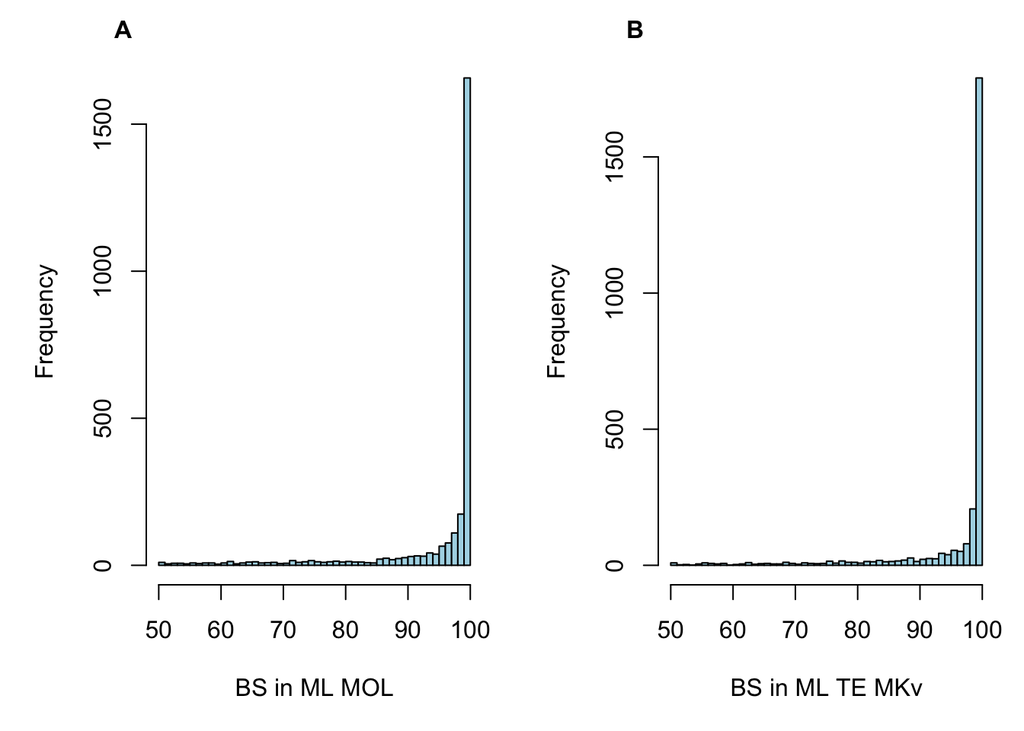

```r
# Histograms
par(mfrow = c(1, 2), mar = c(5, 5, 2, 1))  # adjust margins
# Histogram MP MOL
hist(df_MLASC$Support_Tree_1, breaks = 40, col = "lightblue", xlab = "BS in ML MOL", main="")
# A
mtext("A", side = 3, line = 0.5, adj = -0.1, font = 2)
# Histogram MP TE
hist(df_MLASC$Support_Tree_2, breaks = 40, col = "lightblue", xlab = "BS in ML TE MKv", main="")
# B
mtext("B", side = 3, line = 0.5, adj = -0.1, font = 2)
```

```r
# Shapiro-Wilk test for normality
shapiro.test(df_MLASC$Support_Tree_1) # P < 0.05, non-parametric
```

```
##
##  Shapiro-Wilk normality test
##
## data:  df_MLASC$Support_Tree_1
## W = 0.54732, p-value < 2.2e-16
```

```r
shapiro.test(df_MLASC$Support_Tree_2) # P < 0.05, non-parametric
```

```
##
##  Shapiro-Wilk normality test
##
## data:  df_MLASC$Support_Tree_2
## W = 0.49554, p-value < 2.2e-16
```

```r
# Perform the Wilcoxon signed-rank test for paired values
wilcox.test(as.numeric(df_MLASC$Support_Tree_1),
                       as.numeric(df_MLASC$Support_Tree_2),
                       paired = TRUE)
```

```
##
##  Wilcoxon signed rank test with continuity correction
##
## data:  as.numeric(df_MLASC$Support_Tree_1) and as.numeric(df_MLASC$Support_Tree_2)
## V = 200256, p-value = 2.232e-12
## alternative hypothesis: true location shift is not equal to 0
```

```r
# Dataset for GLMMs
df_MLASC_glmm <- data.frame(
  Node = c(df_MLASC$Node_Tree_1, df_MLASC$Node_Tree_2),
  Approach = c(df_MLASC$Approach1, df_MLASC$Approach2),
  Support = c(df_MLASC$Support_Tree_1, df_MLASC$Support_Tree_2),
  ID = c(df_MLASC$ID, df_MLASC$ID)
)

# GLMM Beta
# Step 1. Scale Support from 0–100 to 0–1
df_MLASC_glmm <- df_MLASC_glmm %>%
  mutate(Support_prop = Support / 100)
# Beta regression does not allow exact 0 or 1
n <- nrow(df_MLASC_glmm)
df_MLASC_glmm <- df_MLASC_glmm %>%
  mutate(Support_beta = (Support_prop * (n - 1) + 0.5) / n)
ml_asc_beta <- glmmTMB(Support_beta ~ Approach + (1 | ID),
                 family = beta_family(link = "logit"),
                 data = df_MLASC_glmm)
summary(ml_asc_beta)
```

```
##  Family: beta  ( logit )
## Formula:          Support_beta ~ Approach + (1 | ID)
## Data: df_MLASC_glmm
##
##      AIC      BIC   logLik deviance df.resid
## -44540.8 -44514.5  22274.4 -44548.8     5392
##
## Random effects:
##
## Conditional model:
##  Groups Name        Variance  Std.Dev.
##  ID     (Intercept) 1.855e-09 4.307e-05
## Number of obs: 5396, groups:  ID, 2698
##
## Dispersion parameter for beta family (): 4.18
##
## Conditional model:
##             Estimate Std. Error z value Pr(>|z|)
## (Intercept)  3.02142    0.03157   95.71   <2e-16 ***
## ApproachTE   0.07147    0.02775    2.58     0.01 *
## ---
## Signif. codes:  0 '***' 0.001 '**' 0.01 '*' 0.05 '.' 0.1 ' ' 1
```

#### Q4.2.1.3 ML MOL vs ML TE noASC

```r
# Filter dataset keeping only ML noASC
df_MLnoASC <- df_q4[grepl("ML-noASC", df_q4$Optimality), ]

# Exploratory data analysis
print("Mean BS in ML MOL")
```

```
## [1] "Mean BS in ML MOL"
```

```r
mean(df_MLnoASC$Support_Tree_1) # MOL
```

```
## [1] 95.1704
```

```r
print("Standard deviation BS in MP MOL")
```

```
## [1] "Standard deviation BS in MP MOL"
```

```r
sd(df_MLnoASC$Support_Tree_1) # MOL
```

```
## [1] 10.25307
```

```r
print("Min BS in ML MOL")
```

```
## [1] "Min BS in ML MOL"
```

```r
min(df_MLnoASC$Support_Tree_1) # MOL
```

```
## [1] 50
```

```r
print("Max BS in ML MOL")
```

```
## [1] "Max BS in ML MOL"
```

```r
max(df_MLnoASC$Support_Tree_1) # MOL
```

```
## [1] 100
```

```r
print("Mean BS in ML TE noASC")
```

```
## [1] "Mean BS in ML TE noASC"
```

```r
mean(df_MLnoASC$Support_Tree_2) # TE
```

```
## [1] 96.19843
```

```r
print("Standard deviation BS in ML TE noASC")
```

```
## [1] "Standard deviation BS in ML TE noASC"
```

```r
sd(df_MLnoASC$Support_Tree_2) # TE
```

```
## [1] 8.93862
```

```r
print("Min BS in ML TE noASC")
```

```
## [1] "Min BS in ML TE noASC"
```

```r
min(df_MLnoASC$Support_Tree_2) # TE
```

```
## [1] 50
```

```r
print("Max BS in ML TE noASC")
```

```
## [1] "Max BS in ML TE noASC"
```

```r
max(df_MLnoASC$Support_Tree_2) # TE
```

```
## [1] 100
```

```r
print("Total no. shared clades between MOL and TE")
```

```
## [1] "Total no. shared clades between MOL and TE"
```

```r
nrow(df_MLnoASC)
```

```
## [1] 2676
```

```r
print("No. shared clades with BS MOL == BS TE")
```

```
## [1] "No. shared clades with BS MOL == BS TE"
```

```r
sum(df_MLnoASC$Support_Tree_1 == df_MLnoASC$Support_Tree_2)
```

```
## [1] 1670
```

```r
print("No. shared clades with BS MOL > BS TE")
```

```
## [1] "No. shared clades with BS MOL > BS TE"
```

```r
sum(df_MLnoASC$Support_Tree_1 > df_MLnoASC$Support_Tree_2)
```

```
## [1] 387
```

```r
print("No. shared clades with BS MOL < BS TE")
```

```
## [1] "No. shared clades with BS MOL < BS TE"
```

```r
sum(df_MLnoASC$Support_Tree_1 < df_MLnoASC$Support_Tree_2)
```

```
## [1] 619
```

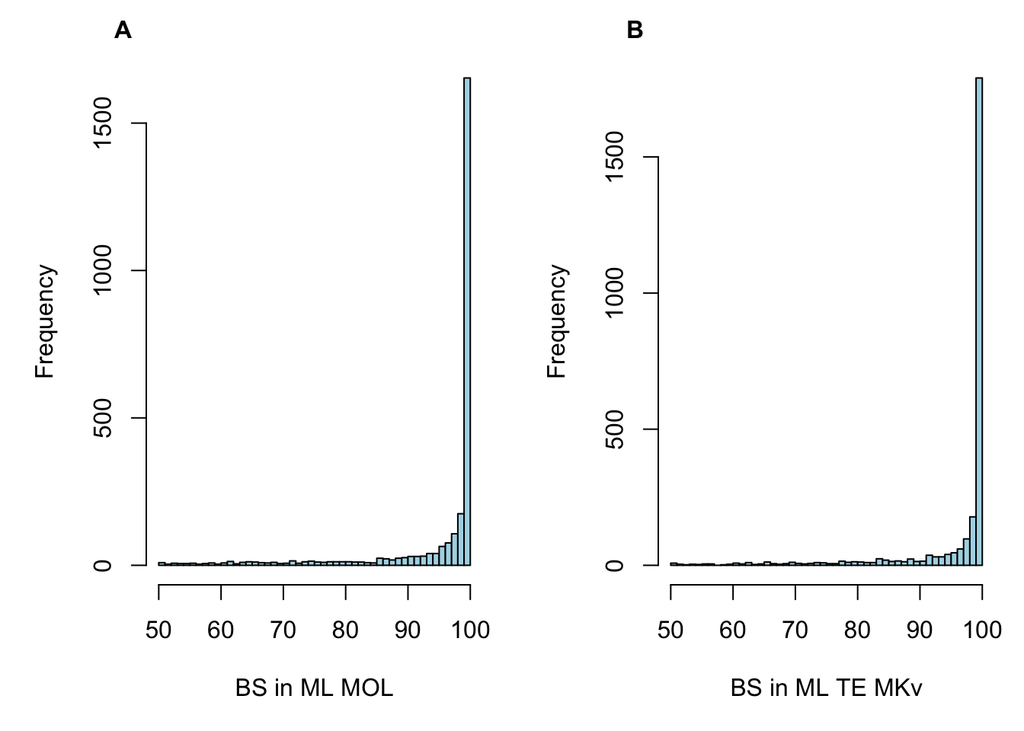

```r
# Histograms
par(mfrow = c(1, 2), mar = c(5, 5, 2, 1))  # adjust margins
# Histogram MP MOL
hist(df_MLnoASC$Support_Tree_1, breaks = 40, col = "lightblue", xlab = "BS in ML MOL", main="")
# A
mtext("A", side = 3, line = 0.5, adj = -0.1, font = 2)
# Histogram MP TE
hist(df_MLnoASC$Support_Tree_2, breaks = 40, col = "lightblue", xlab = "BS in ML TE MKv", main="")
# B
mtext("B", side = 3, line = 0.5, adj = -0.1, font = 2)
```

```r
# Shapiro-Wilk test for normality
shapiro.test(df_MLnoASC$Support_Tree_1) # P < 0.05, non-parametric
```

```
##
##  Shapiro-Wilk normality test
##
## data:  df_MLnoASC$Support_Tree_1
## W = 0.54256, p-value < 2.2e-16
```

```r
shapiro.test(df_MLnoASC$Support_Tree_2) # P < 0.05, non-parametric
```

```
##
##  Shapiro-Wilk normality test
##
## data:  df_MLnoASC$Support_Tree_2
## W = 0.49483, p-value < 2.2e-16
```

```r
# Perform the Wilcoxon signed-rank test for paired values
wilcox.test(as.numeric(df_MLnoASC$Support_Tree_1),
                       as.numeric(df_MLnoASC$Support_Tree_2),
                       paired = TRUE)
```

```
##
##  Wilcoxon signed rank test with continuity correction
##
## data:  as.numeric(df_MLnoASC$Support_Tree_1) and as.numeric(df_MLnoASC$Support_Tree_2)
## V = 189714, p-value = 4.837e-12
## alternative hypothesis: true location shift is not equal to 0
```

```r
# Dataset for GLMMs
df_MLnoASC_glmm <- data.frame(
  Node = c(df_MLnoASC$Node_Tree_1, df_MLnoASC$Node_Tree_2),
  Approach = c(df_MLnoASC$Approach1, df_MLnoASC$Approach2),
  Support = c(df_MLnoASC$Support_Tree_1, df_MLnoASC$Support_Tree_2),
  ID = c(df_MLnoASC$ID, df_MLnoASC$ID)
)

# GLMM Beta
# Step 1. Scale Support from 0–100 to 0–1
df_MLnoASC_glmm <- df_MLnoASC_glmm %>%
  mutate(Support_prop = Support / 100)
# Beta regression does not allow exact 0 or 1
n <- nrow(df_MLnoASC_glmm)
df_MLnoASC_glmm <- df_MLnoASC_glmm %>%
  mutate(Support_beta = (Support_prop * (n - 1) + 0.5) / n)
ml_noasc_beta <- glmmTMB(Support_beta ~ Approach + (1 | ID),
                 family = beta_family(link = "logit"),
                 data = df_MLnoASC_glmm)
summary(ml_noasc_beta)
```

```
##  Family: beta  ( logit )
## Formula:          Support_beta ~ Approach + (1 | ID)
## Data: df_MLnoASC_glmm
##
##      AIC      BIC   logLik deviance df.resid
## -44442.3 -44415.9  22225.1 -44450.3     5348
##
## Random effects:
##
## Conditional model:
##  Groups Name        Variance  Std.Dev.
##  ID     (Intercept) 2.739e-09 5.234e-05
## Number of obs: 5352, groups:  ID, 2676
##
## Dispersion parameter for beta family (): 4.29
##
## Conditional model:
##             Estimate Std. Error z value Pr(>|z|)
## (Intercept)  3.04781    0.03174   96.01   <2e-16 ***
## ApproachTE   0.07111    0.02783    2.55   0.0106 *
## ---
## Signif. codes:  0 '***' 0.001 '**' 0.01 '*' 0.05 '.' 0.1 ' ' 1
```

### Q4.2.2 Extinct

First, we need to load the data including fossils. Support values of shared clades were identified and organized using the package RNODE.

```r
# Load data (BS shared clades)
df_q4 = read.csv("Dataset_R_q4_09-25_shared_extinct.csv")

# Set order of optimality criteria
df_q4$Optimality <- factor(df_q4$Optimality, levels = c("MP", "ML-ASC", "ML-noASC"))
df_q4$SupportDiff = df_q4$Support_Tree_1 - df_q4$Support_Tree_2
```

#### Q4.2.2.1 MP MOL vs MP TE

```r
# Filter dataset keeping only MP
df_MP <- df_q4[grepl("MP", df_q4$Optimality), ]

# Exploratory data analysis
print("Mean BS in MP MOL")
```

```
## [1] "Mean BS in MP MOL"
```

```r
mean(df_MP$Support_Tree_1) # MOL
```

```
## [1] 89.35234
```

```r
print("Standard deviation BS in MP MOL")
```

```
## [1] "Standard deviation BS in MP MOL"
```

```r
sd(df_MP$Support_Tree_1) # MOL
```

```
## [1] 14.80839
```

```r
print("Min BS in MP MOL")
```

```
## [1] "Min BS in MP MOL"
```

```r
min(df_MP$Support_Tree_1) # MOL
```

```
## [1] 50
```

```r
print("Max BS in MP MOL")
```

```
## [1] "Max BS in MP MOL"
```

```r
max(df_MP$Support_Tree_1) # MOL
```

```
## [1] 100
```

```r
print("Mean BS in MP TE")
```

```
## [1] "Mean BS in MP TE"
```

```r
mean(df_MP$Support_Tree_2) # TE
```

```
## [1] 86.01023
```

```r
print("Standard deviation BS in MP TE")
```

```
## [1] "Standard deviation BS in MP TE"
```

```r
sd(df_MP$Support_Tree_2) # TE
```

```
## [1] 15.9274
```

```r
print("Min BS in MP TE")
```

```
## [1] "Min BS in MP TE"
```

```r
min(df_MP$Support_Tree_2) # TE
```

```
## [1] 50
```

```r
print("Max BS in MP TE")
```

```
## [1] "Max BS in MP TE"
```

```r
max(df_MP$Support_Tree_2) # TE
```

```
## [1] 100
```

```r
print("Total no. shared clades between MOL and TE")
```

```
## [1] "Total no. shared clades between MOL and TE"
```

```r
nrow(df_MP)
```

```
## [1] 684
```

```r
print("No. shared clades with BS MOL == BS TE")
```

```
## [1] "No. shared clades with BS MOL == BS TE"
```

```r
sum(df_MP$Support_Tree_1 == df_MP$Support_Tree_2)
```

```
## [1] 236
```

```r
print("No. shared clades with BS MOL > BS TE")
```

```
## [1] "No. shared clades with BS MOL > BS TE"
```

```r
sum(df_MP$Support_Tree_1 > df_MP$Support_Tree_2)
```

```
## [1] 274
```

```r
print("No. shared clades with BS MOL < BS TE")
```

```
## [1] "No. shared clades with BS MOL < BS TE"
```

```r
sum(df_MP$Support_Tree_1 < df_MP$Support_Tree_2)
```

```
## [1] 174
```

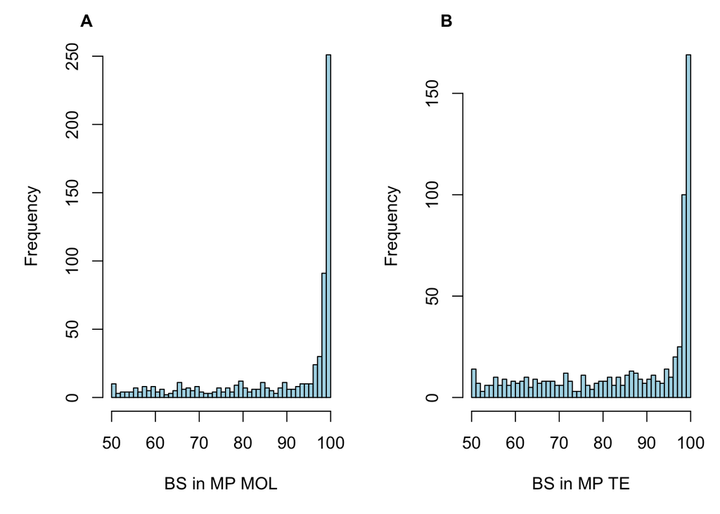

```r
# Histograms
par(mfrow = c(1, 2), mar = c(5, 5, 2, 1))  # adjust margins
# Histogram MP MOL
hist(df_MP$Support_Tree_1, breaks = 40, col = "lightblue", xlab = "BS in MP MOL", main="")
# A
mtext("A", side = 3, line = 0.5, adj = -0.1, font = 2)
# Histogram MP TE
hist(df_MP$Support_Tree_2, breaks = 40, col = "lightblue", xlab = "BS in MP TE", main="")
# B
mtext("B", side = 3, line = 0.5, adj = -0.1, font = 2)
```

```r
# Shapiro-Wilk test for normality
shapiro.test(df_MP$Support_Tree_1) # P < 0.05, non-parametric
```

```
##
##  Shapiro-Wilk normality test
##
## data:  df_MP$Support_Tree_1
## W = 0.73868, p-value < 2.2e-16
```

```r
shapiro.test(df_MP$Support_Tree_2) # P < 0.05, non-parametric
```

```
##
##  Shapiro-Wilk normality test
##
## data:  df_MP$Support_Tree_2
## W = 0.81669, p-value < 2.2e-16
```

```r
# Perform the Wilcoxon signed-rank test for paired values
wilcox.test(as.numeric(df_MP$Support_Tree_1),
                           as.numeric(df_MP$Support_Tree_2),
                           paired = TRUE)
```

```
##
##  Wilcoxon signed rank test with continuity correction
##
## data:  as.numeric(df_MP$Support_Tree_1) and as.numeric(df_MP$Support_Tree_2)
## V = 68140, p-value = 6.26e-11
## alternative hypothesis: true location shift is not equal to 0
```

```r
# Dataset for GLMMs
df_MP_glmm_f <- data.frame(
  Node = c(df_MP$Node_Tree_1, df_MP$Node_Tree_2),
  Approach = c(df_MP$Approach1, df_MP$Approach2),
  Support = c(df_MP$Support_Tree_1, df_MP$Support_Tree_2),
  ID = c(df_MP$ID, df_MP$ID)
)

# GLMM Beta
# Step 1. Scale Support from 0–100 to 0–1
df_MP_glmm_f <- df_MP_glmm_f %>%
  mutate(Support_prop = Support / 100)
# Beta regression does not allow exact 0 or 1
n <- nrow(df_MP_glmm_f)
df_MP_glmm_f <- df_MP_glmm_f %>%
  mutate(Support_beta = (Support_prop * (n - 1) + 0.5) / n)
mp_beta <- glmmTMB(Support_beta ~ Approach + (1 | ID),
                 family = beta_family(link = "logit"),
                 data = df_MP_glmm_f)
summary(mp_beta)
```

```
##  Family: beta  ( logit )
## Formula:          Support_beta ~ Approach + (1 | ID)
## Data: df_MP_glmm_f
##
##      AIC      BIC   logLik deviance df.resid
##  -5115.3  -5094.4   2561.6  -5123.3     1364
##
## Random effects:
##
## Conditional model:
##  Groups Name        Variance Std.Dev.
##  ID     (Intercept) 1.33     1.153
## Number of obs: 1368, groups:  ID, 684
##
## Dispersion parameter for beta family ():  9.1
##
## Conditional model:
##             Estimate Std. Error z value Pr(>|z|)
## (Intercept)  2.62690    0.06434   40.83  < 2e-16 ***
## ApproachTE  -0.32151    0.04765   -6.75  1.5e-11 ***
## ---
## Signif. codes:  0 '***' 0.001 '**' 0.01 '*' 0.05 '.' 0.1 ' ' 1
```

#### Q4.2.2.2 ML MOL vs ML TE ASC

```r
# Filter dataset keeping only ML ASC
df_MLASC <- df_q4[grepl("ML-ASC", df_q4$Optimality), ]

# Exploratory data analysis
print("Mean BS in ML MOL")
```

```
## [1] "Mean BS in ML MOL"
```

```r
mean(df_MLASC$Support_Tree_1) # MOL
```

```
## [1] 93.5326
```

```r
print("Standard deviation BS in MP MOL")
```

```
## [1] "Standard deviation BS in MP MOL"
```

```r
sd(df_MLASC$Support_Tree_1) # MOL
```

```
## [1] 12.15175
```

```r
print("Min BS in ML MOL")
```

```
## [1] "Min BS in ML MOL"
```

```r
min(df_MLASC$Support_Tree_1) # MOL
```

```
## [1] 50
```

```r
print("Max BS in ML MOL")
```

```
## [1] "Max BS in ML MOL"
```

```r
max(df_MLASC$Support_Tree_1) # MOL
```

```
## [1] 100
```

```r
print("Mean BS in ML TE ASC")
```

```
## [1] "Mean BS in ML TE ASC"
```

```r
mean(df_MLASC$Support_Tree_2) # TE
```

```
## [1] 94.36133
```

```r
print("Standard deviation BS in ML TE ASC")
```

```
## [1] "Standard deviation BS in ML TE ASC"
```

```r
sd(df_MLASC$Support_Tree_2) # TE
```

```
## [1] 10.3315
```

```r
print("Min BS in ML TE ASC")
```

```
## [1] "Min BS in ML TE ASC"
```

```r
min(df_MLASC$Support_Tree_2) # TE
```

```
## [1] 50
```

```r
print("Max BS in ML TE ASC")
```

```
## [1] "Max BS in ML TE ASC"
```

```r
max(df_MLASC$Support_Tree_2) # TE
```

```
## [1] 100
```

```r
print("Total no. shared clades between MOL and TE")
```

```
## [1] "Total no. shared clades between MOL and TE"
```

```r
nrow(df_MLASC)
```

```
## [1] 905
```

```r
print("No. shared clades with BS MOL == BS TE")
```

```
## [1] "No. shared clades with BS MOL == BS TE"
```

```r
sum(df_MLASC$Support_Tree_1 == df_MLASC$Support_Tree_2)
```

```
## [1] 410
```

```r
print("No. shared clades with BS MOL > BS TE")
```

```
## [1] "No. shared clades with BS MOL > BS TE"
```

```r
sum(df_MLASC$Support_Tree_1 > df_MLASC$Support_Tree_2)
```

```
## [1] 238
```

```r
print("No. shared clades with BS MOL < BS TE")
```

```
## [1] "No. shared clades with BS MOL < BS TE"
```

```r
sum(df_MLASC$Support_Tree_1 < df_MLASC$Support_Tree_2)
```

```
## [1] 257
```

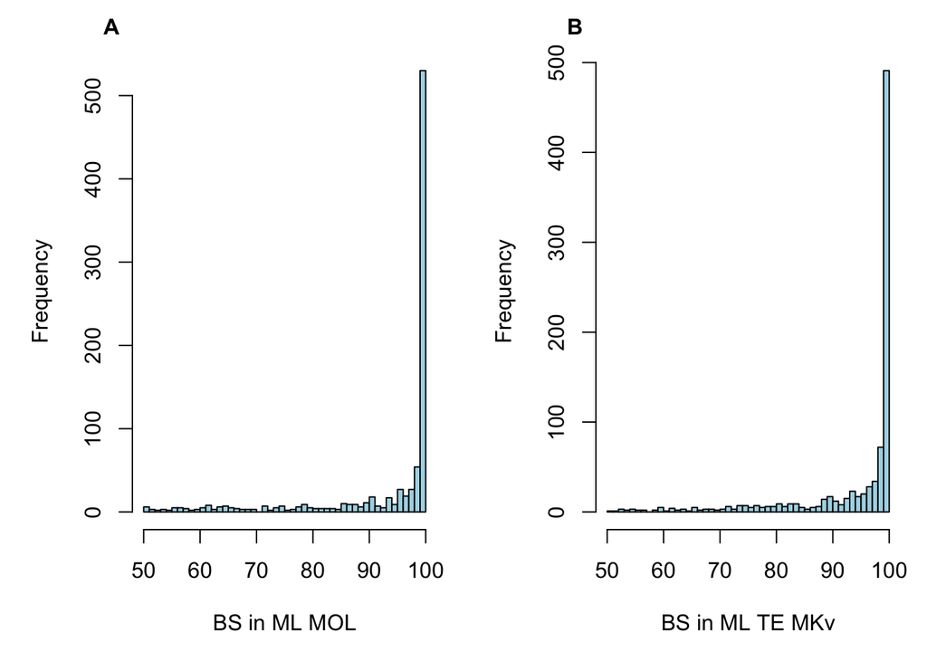

```r
# Histograms
par(mfrow = c(1, 2), mar = c(5, 5, 2, 1))  # adjust margins
# Histogram MP MOL
hist(df_MLASC$Support_Tree_1, breaks = 40, col = "lightblue", xlab = "BS in ML MOL", main="")
# A
mtext("A", side = 3, line = 0.5, adj = -0.1, font = 2)
# Histogram MP TE
hist(df_MLASC$Support_Tree_2, breaks = 40, col = "lightblue", xlab = "BS in ML TE MKv", main="")
# B
mtext("B", side = 3, line = 0.5, adj = -0.1, font = 2)
```

```r
# Shapiro-Wilk test for normality
shapiro.test(df_MLASC$Support_Tree_1) # P < 0.05, non-parametric
```

```
##
##  Shapiro-Wilk normality test
##
## data:  df_MLASC$Support_Tree_1
## W = 0.6015, p-value < 2.2e-16
```

```r
shapiro.test(df_MLASC$Support_Tree_2) # P < 0.05, non-parametric
```

```
##
##  Shapiro-Wilk normality test
##
## data:  df_MLASC$Support_Tree_2
## W = 0.61812, p-value < 2.2e-16
```

```r
# Perform the Wilcoxon signed-rank test for paired values
wilcox.test(as.numeric(df_MLASC$Support_Tree_1),
                       as.numeric(df_MLASC$Support_Tree_2),
                       paired = TRUE)
```

```
##
##  Wilcoxon signed rank test with continuity correction
##
## data:  as.numeric(df_MLASC$Support_Tree_1) and as.numeric(df_MLASC$Support_Tree_2)
## V = 56126, p-value = 0.09875
## alternative hypothesis: true location shift is not equal to 0
```

```r
# Dataset for GLMMs
df_MLASC_glmm_f <- data.frame(
  Node = c(df_MLASC$Node_Tree_1, df_MLASC$Node_Tree_2),
  Approach = c(df_MLASC$Approach1, df_MLASC$Approach2),
  Support = c(df_MLASC$Support_Tree_1, df_MLASC$Support_Tree_2),
  ID = c(df_MLASC$ID, df_MLASC$ID)
)

# GLMM Beta
# Step 1. Scale Support from 0–100 to 0–1
df_MLASC_glmm_f <- df_MLASC_glmm_f %>%
  mutate(Support_prop = Support / 100)
# Beta regression does not allow exact 0 or 1
n <- nrow(df_MLASC_glmm_f)
df_MLASC_glmm_f <- df_MLASC_glmm_f %>%
  mutate(Support_beta = (Support_prop * (n - 1) + 0.5) / n)
ml_asc_beta <- glmmTMB(Support_beta ~ Approach + (1 | ID),
                 family = beta_family(link = "logit"),
                 data = df_MLASC_glmm_f)
summary(ml_asc_beta)
```

```
##  Family: beta  ( logit )
## Formula:          Support_beta ~ Approach + (1 | ID)
## Data: df_MLASC_glmm_f
##
##      AIC      BIC   logLik deviance df.resid
## -11346.9 -11324.9   5677.5 -11354.9     1806
##
## Random effects:
##
## Conditional model:
##  Groups Name        Variance  Std.Dev.
##  ID     (Intercept) 1.942e-09 4.407e-05
## Number of obs: 1810, groups:  ID, 905
##
## Dispersion parameter for beta family (): 3.85
##
## Conditional model:
##             Estimate Std. Error z value Pr(>|z|)
## (Intercept)  2.75625    0.05035   54.74   <2e-16 ***
## ApproachTE  -0.02986    0.04807   -0.62    0.535
## ---
## Signif. codes:  0 '***' 0.001 '**' 0.01 '*' 0.05 '.' 0.1 ' ' 1
```

#### Q4.2.2.3 ML MOL vs ML TE noASC

```r
# Filter dataset keeping only ML noASC
df_MLnoASC <- df_q4[grepl("ML-noASC", df_q4$Optimality), ]

# Exploratory data analysis
print("Mean BS in ML MOL")
```

```
## [1] "Mean BS in ML MOL"
```

```r
mean(df_MLnoASC$Support_Tree_1) # MOL
```

```
## [1] 93.44114
```

```r
print("Standard deviation BS in MP MOL")
```

```
## [1] "Standard deviation BS in MP MOL"
```

```r
sd(df_MLnoASC$Support_Tree_1) # MOL
```

```
## [1] 12.23882
```

```r
print("Min BS in ML MOL")
```

```
## [1] "Min BS in ML MOL"
```

```r
min(df_MLnoASC$Support_Tree_1) # MOL
```

```
## [1] 50
```

```r
print("Max BS in ML MOL")
```

```
## [1] "Max BS in ML MOL"
```

```r
max(df_MLnoASC$Support_Tree_1) # MOL
```

```
## [1] 100
```

```r
print("Mean BS in ML TE noASC")
```

```
## [1] "Mean BS in ML TE noASC"
```

```r
mean(df_MLnoASC$Support_Tree_2) # TE
```

```
## [1] 93.9835
```

```r
print("Standard deviation BS in ML TE noASC")
```

```
## [1] "Standard deviation BS in ML TE noASC"
```

```r
sd(df_MLnoASC$Support_Tree_2) # TE
```

```
## [1] 10.56701
```

```r
print("Min BS in ML TE noASC")
```

```
## [1] "Min BS in ML TE noASC"
```

```r
min(df_MLnoASC$Support_Tree_2) # TE
```

```
## [1] 50
```

```r
print("Max BS in ML TE noASC")
```

```
## [1] "Max BS in ML TE noASC"
```

```r
max(df_MLnoASC$Support_Tree_2) # TE
```

```
## [1] 100
```

```r
print("Total no. shared clades between MOL and TE")
```

```
## [1] "Total no. shared clades between MOL and TE"
```

```r
nrow(df_MLnoASC)
```

```
## [1] 909
```

```r
print("No. shared clades with BS MOL == BS TE")
```

```
## [1] "No. shared clades with BS MOL == BS TE"
```

```r
sum(df_MLnoASC$Support_Tree_1 == df_MLnoASC$Support_Tree_2)
```

```
## [1] 393
```

```r
print("No. shared clades with BS MOL > BS TE")
```

```
## [1] "No. shared clades with BS MOL > BS TE"
```

```r
sum(df_MLnoASC$Support_Tree_1 > df_MLnoASC$Support_Tree_2)
```

```
## [1] 269
```

```r
print("No. shared clades with BS MOL < BS TE")
```

```
## [1] "No. shared clades with BS MOL < BS TE"
```

```r
sum(df_MLnoASC$Support_Tree_1 < df_MLnoASC$Support_Tree_2)
```

```
## [1] 247
```

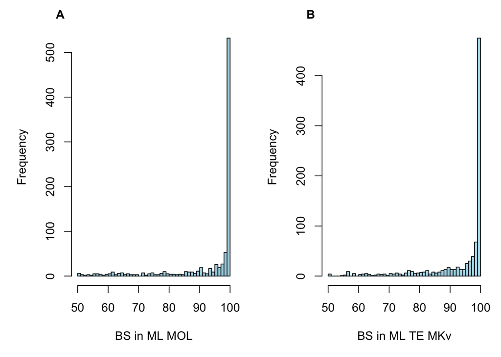

```r
# Histograms
par(mfrow = c(1, 2), mar = c(5, 5, 2, 1))  # adjust margins
# Histogram MP MOL
hist(df_MLnoASC$Support_Tree_1, breaks = 40, col = "lightblue", xlab = "BS in ML MOL", main="")
# A
mtext("A", side = 3, line = 0.5, adj = -0.1, font = 2)
# Histogram MP TE
hist(df_MLnoASC$Support_Tree_2, breaks = 40, col = "lightblue", xlab = "BS in ML TE MKv", main="")
# B
mtext("B", side = 3, line = 0.5, adj = -0.1, font = 2)
```

```r
# Shapiro-Wilk test for normality
shapiro.test(df_MLnoASC$Support_Tree_1) # P < 0.05, non-parametric
```

```
##
##  Shapiro-Wilk normality test
##
## data:  df_MLnoASC$Support_Tree_1
## W = 0.60476, p-value < 2.2e-16
```

```r
shapiro.test(df_MLnoASC$Support_Tree_2) # P < 0.05, non-parametric
```

```
##
##  Shapiro-Wilk normality test
##
## data:  df_MLnoASC$Support_Tree_2
## W = 0.63921, p-value < 2.2e-16
```

```r
# Perform the Wilcoxon signed-rank test for paired values
wilcox.test(as.numeric(df_MLnoASC$Support_Tree_1),
                       as.numeric(df_MLnoASC$Support_Tree_2),
                       paired = TRUE)
```

```
##
##  Wilcoxon signed rank test with continuity correction
##
## data:  as.numeric(df_MLnoASC$Support_Tree_1) and as.numeric(df_MLnoASC$Support_Tree_2)
## V = 65169, p-value = 0.6528
## alternative hypothesis: true location shift is not equal to 0
```

```r
# Dataset for GLMMs
df_MLnoASC_glmm_f <- data.frame(
  Node = c(df_MLnoASC$Node_Tree_1, df_MLnoASC$Node_Tree_2),
  Approach = c(df_MLnoASC$Approach1, df_MLnoASC$Approach2),
  Support = c(df_MLnoASC$Support_Tree_1, df_MLnoASC$Support_Tree_2),
  ID = c(df_MLnoASC$ID, df_MLnoASC$ID)
)

# GLMM Beta
# Step 1. Scale Support from 0–100 to 0–1
df_MLnoASC_glmm_f <- df_MLnoASC_glmm_f %>%
  mutate(Support_prop = Support / 100)
# Beta regression does not allow exact 0 or 1
n <- nrow(df_MLnoASC_glmm_f)
df_MLnoASC_glmm_f <- df_MLnoASC_glmm_f %>%
  mutate(Support_beta = (Support_prop * (n - 1) + 0.5) / n)
ml_noasc_beta <- glmmTMB(Support_beta ~ Approach + (1 | ID),
                 family = beta_family(link = "logit"),
                 data = df_MLnoASC_glmm_f)
summary(ml_noasc_beta)
```

```
##  Family: beta  ( logit )
## Formula:          Support_beta ~ Approach + (1 | ID)
## Data: df_MLnoASC_glmm_f
##
##      AIC      BIC   logLik deviance df.resid
## -11185.2 -11163.1   5596.6 -11193.2     1814
##
## Random effects:
##
## Conditional model:
##  Groups Name        Variance  Std.Dev.
##  ID     (Intercept) 2.696e-09 5.192e-05
## Number of obs: 1818, groups:  ID, 909
##
## Dispersion parameter for beta family (): 3.75
##
## Conditional model:
##             Estimate Std. Error z value Pr(>|z|)
## (Intercept)  2.73555    0.05010   54.60   <2e-16 ***
## ApproachTE  -0.05850    0.04803   -1.22    0.223
## ---
## Signif. codes:  0 '***' 0.001 '**' 0.01 '*' 0.05 '.' 0.1 ' ' 1
```

### Q4.2.3 Reduced

```r
# Load data (BS shared clades)
df_q4_reduced = read.csv("Dataset_R_q4_09-25_shared_extinct.csv")

# Set order of optimality criteria
df_q4_reduced$Optimality <- factor(df_q4_reduced$Optimality, levels = c("MP", "ML-ASC", "ML-noASC"))
df_q4_reduced$SupportDiff = df_q4_reduced$Support_Tree_1 - df_q4_reduced$Support_Tree_2

# Select reduced datasest (those with fossils available, albeit not used here)
df_q4_reduced <- df_q4_reduced[df_q4_reduced$Dataset %in% c(3, 7, 8, 9, 10, 11, 13, 17, 21, 24, 28, 29, 31, 38, 39, 40, 42, 46, 48, 52, 54, 57), ]
```

#### Q4.2.3.1 MP MOL vs MP TE

```r
# Filter dataset keeping only MP
df_MP <- df_q4_reduced[grepl("MP", df_q4_reduced$Optimality), ]

# Exploratory data analysis
print("Mean BS in MP MOL")
```

```
## [1] "Mean BS in MP MOL"
```

```r
mean(df_MP$Support_Tree_1) # MOL
```

```
## [1] 89.44898
```

```r
print("Standard deviation BS in MP MOL")
```

```
## [1] "Standard deviation BS in MP MOL"
```

```r
sd(df_MP$Support_Tree_1) # MOL
```

```
## [1] 14.66763
```

```r
print("Min BS in MP MOL")
```

```
## [1] "Min BS in MP MOL"
```

```r
min(df_MP$Support_Tree_1) # MOL
```

```
## [1] 51
```

```r
print("Max BS in MP MOL")
```

```
## [1] "Max BS in MP MOL"
```

```r
max(df_MP$Support_Tree_1) # MOL
```

```
## [1] 100
```

```r
print("Mean BS in MP TE")
```

```
## [1] "Mean BS in MP TE"
```

```r
mean(df_MP$Support_Tree_2) # TE
```

```
## [1] 82.38776
```

```r
print("Standard deviation BS in MP TE")
```

```
## [1] "Standard deviation BS in MP TE"
```

```r
sd(df_MP$Support_Tree_2) # TE
```

```
## [1] 16.31935
```

```r
print("Min BS in MP TE")
```

```
## [1] "Min BS in MP TE"
```

```r
min(df_MP$Support_Tree_2) # TE
```

```
## [1] 50
```

```r
print("Max BS in MP TE")
```

```
## [1] "Max BS in MP TE"
```

```r
max(df_MP$Support_Tree_2) # TE
```

```
## [1] 100
```

```r
print("Total no. shared clades between MOL and TE")
```

```
## [1] "Total no. shared clades between MOL and TE"
```

```r
nrow(df_MP)
```

```
## [1] 147
```

```r
print("No. shared clades with BS MOL == BS TE")
```

```
## [1] "No. shared clades with BS MOL == BS TE"
```

```r
sum(df_MP$Support_Tree_1 == df_MP$Support_Tree_2)
```

```
## [1] 30
```

```r
print("No. shared clades with BS MOL > BS TE")
```

```
## [1] "No. shared clades with BS MOL > BS TE"
```

```r
sum(df_MP$Support_Tree_1 > df_MP$Support_Tree_2)
```

```
## [1] 88
```

```r
print("No. shared clades with BS MOL < BS TE")
```

```
## [1] "No. shared clades with BS MOL < BS TE"
```

```r
sum(df_MP$Support_Tree_1 < df_MP$Support_Tree_2)
```

```
## [1] 29
```

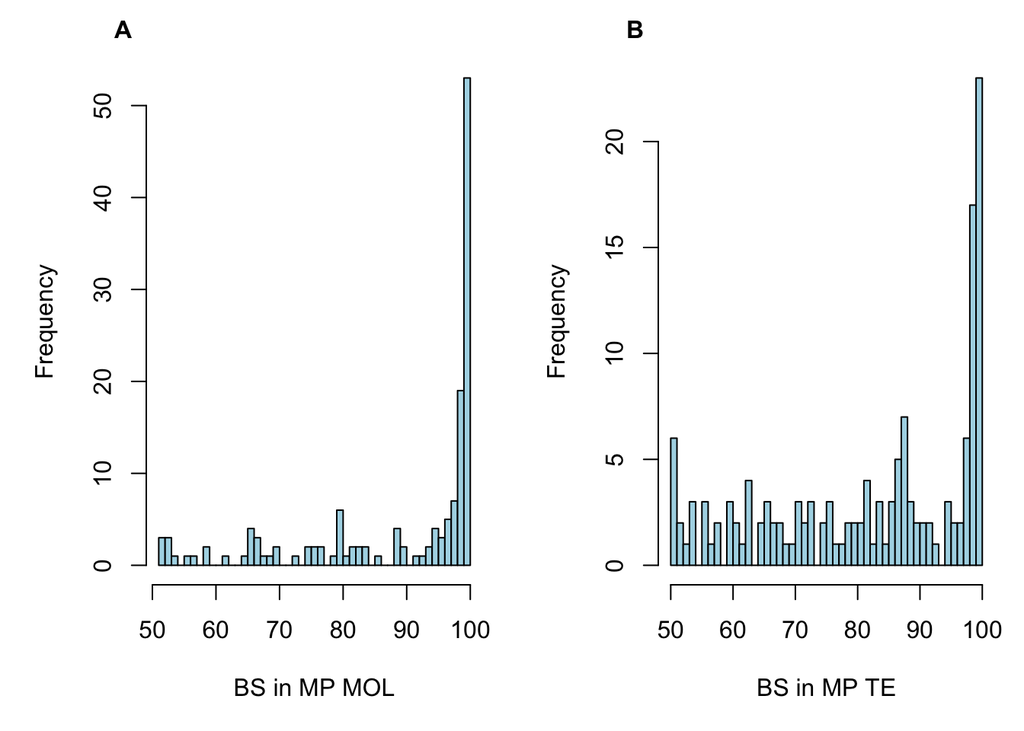

```r
# Histograms
par(mfrow = c(1, 2), mar = c(5, 5, 2, 1))  # adjust margins
# Histogram MP MOL
hist(df_MP$Support_Tree_1, breaks = 40, col = "lightblue", xlab = "BS in MP MOL", main="")
# A
mtext("A", side = 3, line = 0.5, adj = -0.1, font = 2)
# Histogram MP TE
hist(df_MP$Support_Tree_2, breaks = 40, col = "lightblue", xlab = "BS in MP TE", main="")
# B
mtext("B", side = 3, line = 0.5, adj = -0.1, font = 2)
```

```r
# Shapiro-Wilk test for normality
shapiro.test(df_MP$Support_Tree_1) # P < 0.05, non-parametric
```

```
##
##  Shapiro-Wilk normality test
##
## data:  df_MP$Support_Tree_1
## W = 0.74064, p-value = 8.161e-15
```

```r
shapiro.test(df_MP$Support_Tree_2) # P < 0.05, non-parametric
```

```
##
##  Shapiro-Wilk normality test
##
## data:  df_MP$Support_Tree_2
## W = 0.88388, p-value = 2.359e-09
```

```r
# Perform the Wilcoxon signed-rank test for paired values
wilcox.test(as.numeric(df_MP$Support_Tree_1),
                           as.numeric(df_MP$Support_Tree_2),
                           paired = TRUE)
```

```
##
##  Wilcoxon signed rank test with continuity correction
##
## data:  as.numeric(df_MP$Support_Tree_1) and as.numeric(df_MP$Support_Tree_2)
## V = 5522.5, p-value = 1.737e-08
## alternative hypothesis: true location shift is not equal to 0
```

```r
# Dataset for GLMMs
df_MP_glmm_f <- data.frame(
  Node = c(df_MP$Node_Tree_1, df_MP$Node_Tree_2),
  Approach = c(df_MP$Approach1, df_MP$Approach2),
  Support = c(df_MP$Support_Tree_1, df_MP$Support_Tree_2),
  ID = c(df_MP$ID, df_MP$ID)
)

# GLMM Beta
# Step 1. Scale Support from 0–100 to 0–1
df_MP_glmm_f <- df_MP_glmm_f %>%
  mutate(Support_prop = Support / 100)
# Beta regression does not allow exact 0 or 1
n <- nrow(df_MP_glmm_f)
df_MP_glmm_f <- df_MP_glmm_f %>%
  mutate(Support_beta = (Support_prop * (n - 1) + 0.5) / n)
mp_beta <- glmmTMB(Support_beta ~ Approach + (1 | ID),
                 family = beta_family(link = "logit"),
                 data = df_MP_glmm_f)
summary(mp_beta)
```

```
##  Family: beta  ( logit )
## Formula:          Support_beta ~ Approach + (1 | ID)
## Data: df_MP_glmm_f
##
##      AIC      BIC   logLik deviance df.resid
##   -767.2   -752.5    387.6   -775.2      290
##
## Random effects:
##
## Conditional model:
##  Groups Name        Variance Std.Dev.
##  ID     (Intercept) 0.5852   0.765
## Number of obs: 294, groups:  ID, 147
##
## Dispersion parameter for beta family (): 6.33
##
## Conditional model:
##             Estimate Std. Error z value Pr(>|z|)
## (Intercept)   2.3592     0.1201  19.648  < 2e-16 ***
## ApproachTE   -0.6017     0.1106  -5.442 5.26e-08 ***
## ---
## Signif. codes:  0 '***' 0.001 '**' 0.01 '*' 0.05 '.' 0.1 ' ' 1
```

#### Q4.2.3.2 ML MOL vs ML TE ASC

```r
# Filter dataset keeping only ML ASC
df_MLASC <- df_q4_reduced[grepl("ML-ASC", df_q4_reduced$Optimality), ]

# Exploratory data analysis
print("Mean BS in ML MOL")
```

```
## [1] "Mean BS in ML MOL"
```

```r
mean(df_MLASC$Support_Tree_1) # MOL
```

```
## [1] 93.27706
```

```r
print("Standard deviation BS in MP MOL")
```

```
## [1] "Standard deviation BS in MP MOL"
```

```r
sd(df_MLASC$Support_Tree_1) # MOL
```

```
## [1] 11.70066
```

```r
print("Min BS in ML MOL")
```

```
## [1] "Min BS in ML MOL"
```

```r
min(df_MLASC$Support_Tree_1) # MOL
```

```
## [1] 50
```

```r
print("Max BS in ML MOL")
```

```
## [1] "Max BS in ML MOL"
```

```r
max(df_MLASC$Support_Tree_1) # MOL
```

```
## [1] 100
```

```r
print("Mean BS in ML TE ASC")
```

```
## [1] "Mean BS in ML TE ASC"
```

```r
mean(df_MLASC$Support_Tree_2) # TE
```

```
## [1] 92.14286
```

```r
print("Standard deviation BS in ML TE ASC")
```

```
## [1] "Standard deviation BS in ML TE ASC"
```

```r
sd(df_MLASC$Support_Tree_2) # TE
```

```
## [1] 12.19413
```

```r
print("Min BS in ML TE ASC")
```

```
## [1] "Min BS in ML TE ASC"
```

```r
min(df_MLASC$Support_Tree_2) # TE
```

```
## [1] 52
```

```r
print("Max BS in ML TE ASC")
```

```
## [1] "Max BS in ML TE ASC"
```

```r
max(df_MLASC$Support_Tree_2) # TE
```

```
## [1] 100
```

```r
print("Total no. shared clades between MOL and TE")
```

```
## [1] "Total no. shared clades between MOL and TE"
```

```r
nrow(df_MLASC)
```

```
## [1] 231
```

```r
print("No. shared clades with BS MOL == BS TE")
```

```
## [1] "No. shared clades with BS MOL == BS TE"
```

```r
sum(df_MLASC$Support_Tree_1 == df_MLASC$Support_Tree_2)
```

```
## [1] 85
```

```r
print("No. shared clades with BS MOL > BS TE")
```

```
## [1] "No. shared clades with BS MOL > BS TE"
```

```r
sum(df_MLASC$Support_Tree_1 > df_MLASC$Support_Tree_2)
```

```
## [1] 82
```

```r
print("No. shared clades with BS MOL < BS TE")
```

```
## [1] "No. shared clades with BS MOL < BS TE"
```

```r
sum(df_MLASC$Support_Tree_1 < df_MLASC$Support_Tree_2)
```

```
## [1] 64
```

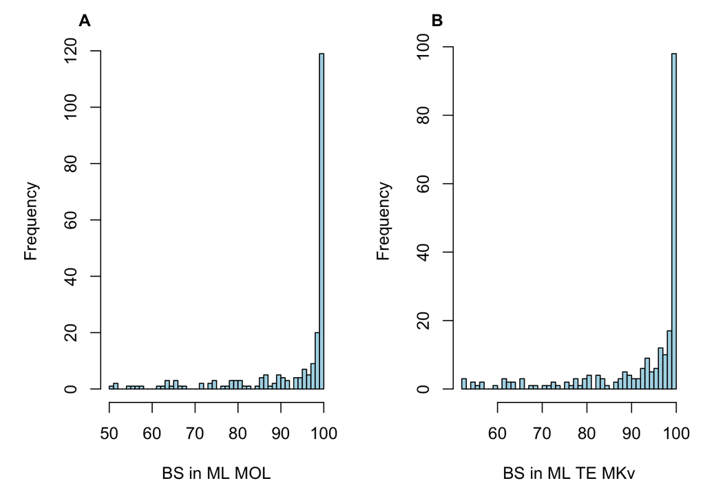

```r
# Histograms
par(mfrow = c(1, 2), mar = c(5, 5, 2, 1))  # adjust margins
# Histogram MP MOL
hist(df_MLASC$Support_Tree_1, breaks = 40, col = "lightblue", xlab = "BS in ML MOL", main="")
# A
mtext("A", side = 3, line = 0.5, adj = -0.1, font = 2)
# Histogram MP TE
hist(df_MLASC$Support_Tree_2, breaks = 40, col = "lightblue", xlab = "BS in ML TE MKv", main="")
# B
mtext("B", side = 3, line = 0.5, adj = -0.1, font = 2)
```

```r
# Shapiro-Wilk test for normality
shapiro.test(df_MLASC$Support_Tree_1) # P < 0.05, non-parametric
```

```
##
##  Shapiro-Wilk normality test
##
## data:  df_MLASC$Support_Tree_1
## W = 0.64312, p-value < 2.2e-16
```

```r
shapiro.test(df_MLASC$Support_Tree_2) # P < 0.05, non-parametric
```

```
##
##  Shapiro-Wilk normality test
##
## data:  df_MLASC$Support_Tree_2
## W = 0.69335, p-value < 2.2e-16
```

```r
# Perform the Wilcoxon signed-rank test for paired values
wilcox.test(as.numeric(df_MLASC$Support_Tree_1),
                       as.numeric(df_MLASC$Support_Tree_2),
                       paired = TRUE)
```

```
##
##  Wilcoxon signed rank test with continuity correction
##
## data:  as.numeric(df_MLASC$Support_Tree_1) and as.numeric(df_MLASC$Support_Tree_2)
## V = 5971, p-value = 0.2369
## alternative hypothesis: true location shift is not equal to 0
```

```r
# Dataset for GLMMs
df_MLASC_glmm <- data.frame(
  Node = c(df_MLASC$Node_Tree_1, df_MLASC$Node_Tree_2),
  Approach = c(df_MLASC$Approach1, df_MLASC$Approach2),
  Support = c(df_MLASC$Support_Tree_1, df_MLASC$Support_Tree_2),
  ID = c(df_MLASC$ID, df_MLASC$ID)
)

# GLMM Beta
# Step 1. Scale Support from 0–100 to 0–1
df_MLASC_glmm <- df_MLASC_glmm %>%
  mutate(Support_prop = Support / 100)
# Beta regression does not allow exact 0 or 1
n <- nrow(df_MLASC_glmm)
df_MLASC_glmm <- df_MLASC_glmm %>%
  mutate(Support_beta = (Support_prop * (n - 1) + 0.5) / n)
ml_asc_beta <- glmmTMB(Support_beta ~ Approach + (1 | ID),
                 family = beta_family(link = "logit"),
                 data = df_MLASC_glmm)
summary(ml_asc_beta)
```

```
##  Family: beta  ( logit )
## Formula:          Support_beta ~ Approach + (1 | ID)
## Data: df_MLASC_glmm
##
##      AIC      BIC   logLik deviance df.resid
##  -2059.7  -2043.2   1033.8  -2067.7      458
##
## Random effects:
##
## Conditional model:
##  Groups Name        Variance  Std.Dev.
##  ID     (Intercept) 2.513e-09 5.013e-05
## Number of obs: 462, groups:  ID, 231
##
## Dispersion parameter for beta family (): 4.42
##
## Conditional model:
##             Estimate Std. Error z value Pr(>|z|)
## (Intercept)  2.59088    0.08983  28.843   <2e-16 ***
## ApproachTE  -0.12873    0.09383  -1.372     0.17
## ---
## Signif. codes:  0 '***' 0.001 '**' 0.01 '*' 0.05 '.' 0.1 ' ' 1
```

#### Q4.2.3.3 ML MOL vs ML TE noASC

```r
# Filter dataset keeping only ML no ASC
df_MLnoASC <- df_q4_reduced[grepl("ML-noASC", df_q4_reduced$Optimality), ]

# Exploratory data analysis
print("Mean BS in ML MOL")
```

```
## [1] "Mean BS in ML MOL"
```

```r
mean(df_MLnoASC$Support_Tree_1) # MOL
```

```
## [1] 93.19565
```

```r
print("Standard deviation BS in MP MOL")
```

```
## [1] "Standard deviation BS in MP MOL"
```

```r
sd(df_MLnoASC$Support_Tree_1) # MOL
```

```
## [1] 11.83183
```

```r
print("Min BS in ML MOL")
```

```
## [1] "Min BS in ML MOL"
```

```r
min(df_MLnoASC$Support_Tree_1) # MOL
```

```
## [1] 50
```

```r
print("Max BS in ML MOL")
```

```
## [1] "Max BS in ML MOL"
```

```r
max(df_MLnoASC$Support_Tree_1) # MOL
```

```
## [1] 100
```

```r
print("Mean BS in ML TE noASC")
```

```
## [1] "Mean BS in ML TE noASC"
```

```r
mean(df_MLnoASC$Support_Tree_2) # TE
```

```
## [1] 92.07826
```

```r
print("Standard deviation BS in ML TE noASC")
```

```
## [1] "Standard deviation BS in ML TE noASC"
```

```r
sd(df_MLnoASC$Support_Tree_2) # TE
```

```
## [1] 11.59931
```

```r
print("Min BS in ML TE noASC")
```

```
## [1] "Min BS in ML TE noASC"
```

```r
min(df_MLnoASC$Support_Tree_2) # TE
```

```
## [1] 50
```

```r
print("Max BS in ML TE noASC")
```

```
## [1] "Max BS in ML TE noASC"
```

```r
max(df_MLnoASC$Support_Tree_2) # TE
```

```
## [1] 100
```

```r
print("Total no. shared clades between MOL and TE")
```

```
## [1] "Total no. shared clades between MOL and TE"
```

```r
nrow(df_MLnoASC)
```

```
## [1] 230
```

```r
print("No. shared clades with BS MOL == BS TE")
```

```
## [1] "No. shared clades with BS MOL == BS TE"
```

```r
sum(df_MLnoASC$Support_Tree_1 == df_MLnoASC$Support_Tree_2)
```

```
## [1] 81
```

```r
print("No. shared clades with BS MOL > BS TE")
```

```
## [1] "No. shared clades with BS MOL > BS TE"
```

```r
sum(df_MLnoASC$Support_Tree_1 > df_MLnoASC$Support_Tree_2)
```

```
## [1] 88
```

```r
print("No. shared clades with BS MOL < BS TE")
```

```
## [1] "No. shared clades with BS MOL < BS TE"
```

```r
sum(df_MLnoASC$Support_Tree_1 < df_MLnoASC$Support_Tree_2)
```

```
## [1] 61
```

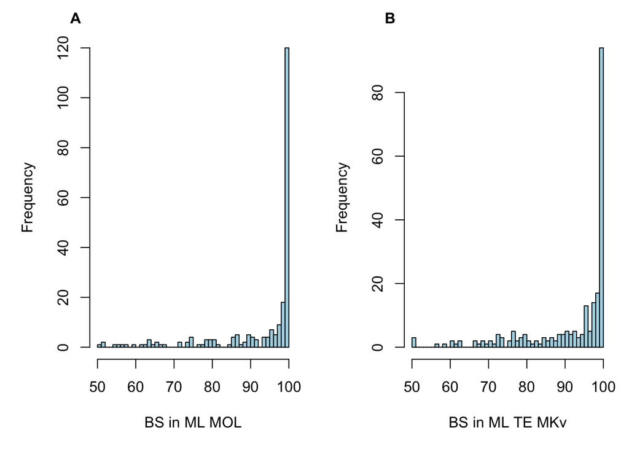

```r
# Histograms
par(mfrow = c(1, 2), mar = c(5, 5, 2, 1))  # adjust margins
# Histogram MP MOL
hist(df_MLnoASC$Support_Tree_1, breaks = 40, col = "lightblue", xlab = "BS in ML MOL", main="")
# A
mtext("A", side = 3, line = 0.5, adj = -0.1, font = 2)
# Histogram MP TE
hist(df_MLnoASC$Support_Tree_2, breaks = 40, col = "lightblue", xlab = "BS in ML TE MKv", main="")
# B
mtext("B", side = 3, line = 0.5, adj = -0.1, font = 2)
```

```r
# Shapiro-Wilk test for normality
shapiro.test(df_MLnoASC$Support_Tree_1) # P < 0.05, non-parametric
```

```
##
##  Shapiro-Wilk normality test
##
## data:  df_MLnoASC$Support_Tree_1
## W = 0.64347, p-value < 2.2e-16
```

```r
shapiro.test(df_MLnoASC$Support_Tree_2) # P < 0.05, non-parametric
```

```
##
##  Shapiro-Wilk normality test
##
## data:  df_MLnoASC$Support_Tree_2
## W = 0.72774, p-value < 2.2e-16
```

```r
# Perform the Wilcoxon signed-rank test for paired values
wilcox.test(as.numeric(df_MLnoASC$Support_Tree_1),
                       as.numeric(df_MLnoASC$Support_Tree_2),
                       paired = TRUE)
```

```
##
##  Wilcoxon signed rank test with continuity correction
##
## data:  as.numeric(df_MLnoASC$Support_Tree_1) and as.numeric(df_MLnoASC$Support_Tree_2)
## V = 6474, p-value = 0.09287
## alternative hypothesis: true location shift is not equal to 0
```

```r
# Dataset for GLMMs
df_MLnoASC_glmm <- data.frame(
  Node = c(df_MLnoASC$Node_Tree_1, df_MLnoASC$Node_Tree_2),
  Approach = c(df_MLnoASC$Approach1, df_MLnoASC$Approach2),
  Support = c(df_MLnoASC$Support_Tree_1, df_MLnoASC$Support_Tree_2),
  ID = c(df_MLnoASC$ID, df_MLnoASC$ID)
)

# GLMM Beta
# Step 1. Scale Support from 0–100 to 0–1
df_MLnoASC_glmm <- df_MLnoASC_glmm %>%
  mutate(Support_prop = Support / 100)
# Beta regression does not allow exact 0 or 1
n <- nrow(df_MLnoASC_glmm)
df_MLnoASC_glmm <- df_MLnoASC_glmm %>%
  mutate(Support_beta = (Support_prop * (n - 1) + 0.5) / n)
ml_noasc_beta <- glmmTMB(Support_beta ~ Approach + (1 | ID),
                 family = beta_family(link = "logit"),
                 data = df_MLnoASC_glmm)
summary(ml_noasc_beta)
```

```
##  Family: beta  ( logit )
## Formula:          Support_beta ~ Approach + (1 | ID)
## Data: df_MLnoASC_glmm
##
##      AIC      BIC   logLik deviance df.resid
##  -2030.1  -2013.5   1019.0  -2038.1      456
##
## Random effects:
##
## Conditional model:
##  Groups Name        Variance  Std.Dev.
##  ID     (Intercept) 3.086e-09 5.555e-05
## Number of obs: 460, groups:  ID, 230
##
## Dispersion parameter for beta family (): 4.46
##
## Conditional model:
##             Estimate Std. Error z value Pr(>|z|)
## (Intercept)  2.59973    0.08983  28.941   <2e-16 ***
## ApproachTE  -0.15452    0.09394  -1.645      0.1
## ---
## Signif. codes:  0 '***' 0.001 '**' 0.01 '*' 0.05 '.' 0.1 ' ' 1
```

## Q4.3 Plot (Figure 5)

First, we will plot the Figure 5A-C (without fossils).

```r
# Create a new column with the optimality criterion
df_MP_glmm$comparison = "MPmol_MPte"
df_MLASC_glmm$comparison = "MLmol_MLteAsc"
df_MLnoASC_glmm$comparison = "MLmol_MLteNoAsc"

# Merge all comparisons into the same dataset
df_plot = bind_rows(df_MP_glmm, df_MLASC_glmm, df_MLnoASC_glmm)
#View(df_plot)

# Set order of comparisons
df_plot$comparison <- factor(df_plot$comparison, levels = c("MPmol_MPte", "MLmol_MLteAsc", "MLmol_MLteNoAsc"))
df_plot = df_plot[!is.na(df_plot$comparison), ]

# Set colors
custom_palette <- c("MPmol_MPte" = "#339999", "MLmol_MLteAsc" = "#6f77b4", "MLmol_MLteNoAsc" = "#cccccc")
# Create custom legend labels
custom_labels <- c(
  "MPmol_MPte" = "MP-MOL vs MP-TE",
  "MLmol_MLteAsc" = "ML-MOL vs ML-TE (with ASC)",
  "MLmol_MLteNoAsc" = "ML-MOL vs ML-TE (without ASC)"
)

# Box Plot MP
plot_mp = ggplot(df_MP_glmm, aes(x = Approach, y = Support)) +
  geom_boxplot(outlier.shape = NA) +  # Create boxplot without default outliers
  geom_jitter(color = "#339999", alpha = .04, width = 0.2) +  # Add transparent dots
  labs(x = "", y = "\nBootstrap\n", tag="A") +
  theme_minimal() +
  #theme(axis.text.x = element_blank(), legend.position = "none") +  # Hide legend if not needed
  scale_color_manual(values = custom_palette, labels = custom_labels)
# Box Plot ML ASC
plot_ml_asc = ggplot(df_MLASC_glmm, aes(x = Approach, y = Support)) +
  geom_boxplot(outlier.shape = NA) +  # Create boxplot without default outliers
  geom_jitter(color = "#6f77b4", alpha = .04, width = 0.2) +  # Add transparent dots
  labs(x = "", y = "\nBootstrap\n", tag="B") +
  theme_minimal() +
  scale_y_continuous(limits = c(50, NA)) + # Define o mínimo para 50, o máximo será ajustado automaticamente
  #theme(axis.text.x = element_blank(), legend.position = "none") +  # Hide legend if not needed
  scale_color_manual(values = custom_palette, labels = custom_labels)
# Box Plot ML noASC
plot_ml_noasc = ggplot(df_MLnoASC_glmm, aes(x = Approach, y = Support)) +
  geom_boxplot(outlier.shape = NA) +  # Create boxplot without default outliers
  geom_jitter(color = "#cccccc", alpha = .07, width = 0.2) +  # Add transparent dots
  labs(x = "", y = "\nBootstrap\n", tag="C") +
  theme_minimal() +
  scale_y_continuous(limits = c(50, NA)) + # Define o mínimo para 50, o máximo será ajustado automaticamente
  #theme(axis.text.x = element_blank(), legend.position = "none") +  # Hide legend if not needed
  scale_color_manual(values = custom_palette, labels = custom_labels)

# Extract the legend as a separate ggplot object
legend <- ggplot(df_plot, aes(x = comparison, y = Support, color = comparison)) +
  geom_point() +
  scale_color_manual(values = custom_palette, labels = custom_labels) +
  theme_minimal() +
  theme(
    legend.position = "bottom",
    legend.title = element_blank(),
    panel.grid = element_blank(),
    panel.background = element_blank(),
    axis.title = element_blank(),
    axis.text = element_blank(),
    axis.ticks = element_blank(),
  )+
  guides(color = guide_legend(override.aes = list(size = 2, alpha=.7)))  # Increase dot size in legend
# Convert the plot to a grob
plot_grob <- ggplotGrob(legend)
# Extract the legend from the grob
legend_grob <- gtable::gtable_filter(plot_grob, "guide-box")

# Plot 2x2
jpeg("Figures/Fig5ABC.jpg", width = 2000, height = 1600, res = 300)
grid.arrange(arrangeGrob(plot_mp + theme(plot.margin = margin(1,1,1,.01)),
                         plot_ml_asc + theme(plot.margin = margin(1,1,1,.01)),
                         plot_ml_noasc + theme(plot.margin = margin(1,1,1,.01)),
                         nrow=1, ncol=3),
             legend_grob,
             nrow=2,
             heights= c(20,1))
dev.off()
```

```r
# Create a new column with the optimality criterion
df_MP_glmm_f$comparison = "MPmol_MPte"
df_MLASC_glmm_f$comparison = "MLmol_MLteAsc"
df_MLnoASC_glmm_f$comparison = "MLmol_MLteNoAsc"

# Merge all comparisons into the same dataset
df_plot = bind_rows(df_MP_glmm_f, df_MLASC_glmm_f, df_MLnoASC_glmm_f)
#View(df_plot)

# Set order of comparisons
df_plot$comparison <- factor(df_plot$comparison, levels = c("MPmol_MPte", "MLmol_MLteAsc", "MLmol_MLteNoAsc"))
df_plot = df_plot[!is.na(df_plot$comparison), ]

# Set colors
custom_palette <- c("MPmol_MPte" = "#339999", "MLmol_MLteAsc" = "#6f77b4", "MLmol_MLteNoAsc" = "#cccccc")
# Create custom legend labels
custom_labels <- c(
  "MPmol_MPte" = "MP-MOL vs MP-TE",
  "MLmol_MLteAsc" = "ML-MOL vs ML-TE (with ASC)",
  "MLmol_MLteNoAsc" = "ML-MOL vs ML-TE (without ASC)"
)

# Box Plot MP
plot_mp = ggplot(df_MP_glmm_f, aes(x = Approach, y = Support)) +
  geom_boxplot(outlier.shape = NA) +  # Create boxplot without default outliers
  geom_jitter(color = "#339999", alpha = .04, width = 0.2) +  # Add transparent dots
  labs(x = "", y = "\nBootstrap\n", tag="D") +
  theme_minimal() +
  #theme(axis.text.x = element_blank(), legend.position = "none") +  # Hide legend if not needed
  scale_color_manual(values = custom_palette, labels = custom_labels)
# Box Plot ML ASC
plot_ml_asc = ggplot(df_MLASC_glmm_f, aes(x = Approach, y = Support)) +
  geom_boxplot(outlier.shape = NA) +  # Create boxplot without default outliers
  geom_jitter(color = "#6f77b4", alpha = .04, width = 0.2) +  # Add transparent dots
  labs(x = "", y = "\nBootstrap\n", tag="E") +
  theme_minimal() +
  scale_y_continuous(limits = c(50, NA)) + # Define o mínimo para 50, o máximo será ajustado automaticamente
  #theme(axis.text.x = element_blank(), legend.position = "none") +  # Hide legend if not needed
  scale_color_manual(values = custom_palette, labels = custom_labels)
# Box Plot ML noASC
plot_ml_noasc = ggplot(df_MLnoASC_glmm_f, aes(x = Approach, y = Support)) +
  geom_boxplot(outlier.shape = NA) +  # Create boxplot without default outliers
  geom_jitter(color = "#cccccc", alpha = .07, width = 0.2) +  # Add transparent dots
  labs(x = "", y = "\nBootstrap\n", tag="F") +
  theme_minimal() +
  scale_y_continuous(limits = c(50, NA)) + # Define o mínimo para 50, o máximo será ajustado automaticamente
  #theme(axis.text.x = element_blank(), legend.position = "none") +  # Hide legend if not needed
  scale_color_manual(values = custom_palette, labels = custom_labels)

# Extract the legend as a separate ggplot object
legend <- ggplot(df_plot, aes(x = comparison, y = Support, color = comparison)) +
  geom_point() +
  scale_color_manual(values = custom_palette, labels = custom_labels) +
  theme_minimal() +
  theme(
    legend.position = "bottom",
    legend.title = element_blank(),
    panel.grid = element_blank(),
    panel.background = element_blank(),
    axis.title = element_blank(),
    axis.text = element_blank(),
    axis.ticks = element_blank(),
  )+
  guides(color = guide_legend(override.aes = list(size = 2, alpha=.7)))  # Increase dot size in legend
# Convert the plot to a grob
plot_grob <- ggplotGrob(legend)
# Extract the legend from the grob
legend_grob <- gtable::gtable_filter(plot_grob, "guide-box")

# Plot 2x2
jpeg("Figures/Fig5DEF.jpg", width = 2000, height = 1600, res = 300)
grid.arrange(arrangeGrob(plot_mp + theme(plot.margin = margin(1,1,1,.01)),
                         plot_ml_asc + theme(plot.margin = margin(1,1,1,.01)),
                         plot_ml_noasc + theme(plot.margin = margin(1,1,1,.01)),
                         nrow=1, ncol=3),
             legend_grob,
             nrow=2,
             heights= c(20,1))
dev.off()
```

# Q5. Can bootstrap from MOL clades retrodict the monophyly of TE groups?

The datasets used in the Q5 was prepared with the package RNODE using the script 3.

## Q5.1 Extant

```r
# Load data
df_q5 = read.csv("/Users/labanfibios/Desktop/Doutorado/Project/B2_TEvsMOL/GitHub/Dataset_R_q5_09-25.csv")
# Only keep >50% BS
df_q5 <- df_q5[df_q5$support_tree1 >= 50, ]

# Select MP
MPlogistic <- df_q5[df_q5$optimality == "MP", ]
# Select ML ASC
MLASClogistic <- df_q5[df_q5$optimality == "MLASC", ]
# Select ML no ASC
MLnoASClogistic <- df_q5[df_q5$optimality == "MLnoASC", ]
```

### Q5.1.1 Data exploration (Table S8)

```r
#############################
# EXPLORATORY DATA ANALYSES #
#############################

# A) MP
# Total number of MOL clades
nrow(MPlogistic)
```

```
## [1] 2426
```

```r
# Shared clades
nrow(subset(MPlogistic, occurrence_tree2 == 1)) # Number of shared clades
```

```
## [1] 2279
```

```r
nrow(subset(MPlogistic, occurrence_tree2 == 1))/nrow(MPlogistic) # Proportion shared/total
```

```
## [1] 0.9394064
```

```r
mean(subset(MPlogistic, occurrence_tree2 == 1)$support_tree1) # BS mean
```

```
## [1] 89.9706
```

```r
sd(subset(MPlogistic, occurrence_tree2 == 1)$support_tree1) # BS sd
```

```
## [1] 14.21655
```

```r
range(subset(MPlogistic, occurrence_tree2 == 1)$support_tree1) # BS range
```

```
## [1]  50 100
```

```r
# Unique clades for MOL
nrow(subset(MPlogistic, occurrence_tree2 == 0)) # Number of unique clades for MOL
```

```
## [1] 147
```

```r
nrow(subset(MPlogistic, occurrence_tree2 == 0))/nrow(MPlogistic) # Proportion uniqueMOL/total
```

```
## [1] 0.06059357
```

```r
mean(subset(MPlogistic, occurrence_tree2 == 0)$support_tree1) # BS mean
```

```
## [1] 62.7619
```

```r
sd(subset(MPlogistic, occurrence_tree2 == 0)$support_tree1) # BS sd
```

```
## [1] 12.314
```

```r
range(subset(MPlogistic, occurrence_tree2 == 0)$support_tree1) # BS range
```

```
## [1]  50 100
```

```r
# MOL clades with BS <75 present in TE
nrow(subset(MPlogistic, support_tree1 < 75 & occurrence_tree2 == 1)) # Number of MOL clades with BS <75 that occur in TE
```

```
## [1] 392
```

```r
nrow(subset(MPlogistic, support_tree1 < 75 & occurrence_tree2 == 1))/nrow(MPlogistic) # Proportion of MOL clades with BS <75 that occur in TE
```

```
## [1] 0.1615829
```

```r
# MOL clades with BS >90 absent in TE
nrow(subset(MPlogistic, support_tree1 > 90 & occurrence_tree2 == 0)) # Number of MOL lades with BS >90 absent in TE
```

```
## [1] 9
```

```r
nrow(subset(MPlogistic, support_tree1 > 90 & occurrence_tree2 == 0))/nrow(MPlogistic) # Proportion of MOL lades with BS >90 absent in TE
```

```
## [1] 0.00370981
```

```r
nrow(subset(MPlogistic, support_tree1 == 100 & occurrence_tree2 == 0)) # MOL clades with BS = 100 absent in TE
```

```
## [1] 1
```

```r
# B) ML ASC
# Total number of MOL clades
nrow(MLASClogistic)
```

```
## [1] 3042
```

```r
# Shared clades
nrow(subset(MLASClogistic, occurrence_tree2 == 1)) # Number of shared clades
```

```
## [1] 2707
```

```r
nrow(subset(MLASClogistic, occurrence_tree2 == 1))/nrow(MLASClogistic) # Proportion shared/total
```

```
## [1] 0.8898751
```

```r
mean(subset(MLASClogistic, occurrence_tree2 == 1)$support_tree1) # BS mean
```

```
## [1] 94.92353
```

```r
sd(subset(MLASClogistic, occurrence_tree2 == 1)$support_tree1) # BS sd
```

```
## [1] 10.60765
```

```r
range(subset(MLASClogistic, occurrence_tree2 == 1)$support_tree1) # BS range
```

```
## [1]  50 100
```

```r
# Unique clades for MOL
nrow(subset(MLASClogistic, occurrence_tree2 == 0)) # Number of unique clades for MOL
```

```
## [1] 335
```

```r
nrow(subset(MLASClogistic, occurrence_tree2 == 0))/nrow(MLASClogistic) # Proportion uniqueMOL/total
```

```
## [1] 0.1101249
```

```r
mean(subset(MLASClogistic, occurrence_tree2 == 0)$support_tree1) # BS mean
```

```
## [1] 78.12836
```

```r
sd(subset(MLASClogistic, occurrence_tree2 == 0)$support_tree1) # BS sd
```

```
## [1] 15.93263
```

```r
range(subset(MLASClogistic, occurrence_tree2 == 0)$support_tree1) # BS range
```

```
## [1]  50 100
```

```r
# MOL clades with BS <75 present in TE
nrow(subset(MLASClogistic, support_tree1 < 75 & occurrence_tree2 == 1)) # Number of MOL clades with BS <75 that occur in TE
```

```
## [1] 211
```

```r
nrow(subset(MLASClogistic, support_tree1 < 75 & occurrence_tree2 == 1))/nrow(MLASClogistic) # Proportion of MOL clades with BS <75 that occur in TE
```

```
## [1] 0.06936226
```

```r
# MOL clades with BS >90 absent in TE
nrow(subset(MLASClogistic, support_tree1 > 90 & occurrence_tree2 == 0)) # Number of MOL lades with BS >90 absent in TE
```

```
## [1] 95
```

```r
nrow(subset(MLASClogistic, support_tree1 > 90 & occurrence_tree2 == 0))/nrow(MLASClogistic) # Proportion of MOL lades with BS >90 absent in TE
```

```
## [1] 0.03122945
```

```r
nrow(subset(MLASClogistic, support_tree1 == 100 & occurrence_tree2 == 0)) # MOL clades with BS = 100 absent in TE
```

```
## [1] 26
```

```r
# C) ML noASC
# Total number of MOL clades
nrow(MLnoASClogistic)
```

```
## [1] 3042
```

```r
# Shared clades
nrow(subset(MLnoASClogistic, occurrence_tree2 == 1)) # Number of shared clades
```

```
## [1] 2696
```

```r
nrow(subset(MLnoASClogistic, occurrence_tree2 == 1))/nrow(MLnoASClogistic) # Proportion shared/total
```

```
## [1] 0.886259
```

```r
mean(subset(MLnoASClogistic, occurrence_tree2 == 1)$support_tree1) # BS mean
```

```
## [1] 94.96254
```

```r
sd(subset(MLnoASClogistic, occurrence_tree2 == 1)$support_tree1) # BS sd
```

```
## [1] 10.54949
```

```r
range(subset(MLnoASClogistic, occurrence_tree2 == 1)$support_tree1) # BS range
```

```
## [1]  50 100
```

```r
# Unique clades for MOL
nrow(subset(MLnoASClogistic, occurrence_tree2 == 0)) # Number of unique clades for MOL
```

```
## [1] 346
```

```r
nrow(subset(MLnoASClogistic, occurrence_tree2 == 0))/nrow(MLnoASClogistic) # Proportion uniqueMOL/total
```

```
## [1] 0.113741
```

```r
mean(subset(MLnoASClogistic, occurrence_tree2 == 0)$support_tree1) # BS mean
```

```
## [1] 78.35838
```

```r
sd(subset(MLnoASClogistic, occurrence_tree2 == 0)$support_tree1) # BS sd
```

```
## [1] 16.05133
```

```r
range(subset(MLnoASClogistic, occurrence_tree2 == 0)$support_tree1) # BS range
```

```
## [1]  50 100
```

```r
# MOL clades with BS <75 present in TE
nrow(subset(MLnoASClogistic, support_tree1 < 75 & occurrence_tree2 == 1)) # Number of MOL clades with BS <75 that occur in TE
```

```
## [1] 208
```

```r
nrow(subset(MLnoASClogistic, support_tree1 < 75 & occurrence_tree2 == 1))/nrow(MLnoASClogistic) # Proportion of MOL clades with BS <75 that occur in TE
```

```
## [1] 0.06837607
```

```r
# MOL clades with BS >90 absent in TE
nrow(subset(MLnoASClogistic, support_tree1 > 90 & occurrence_tree2 == 0)) # Number of MOL lades with BS >90 absent in TE
```

```
## [1] 103
```

```r
nrow(subset(MLnoASClogistic, support_tree1 > 90 & occurrence_tree2 == 0))/nrow(MLnoASClogistic) # Proportion of MOL lades with BS >90 absent in TE
```

```
## [1] 0.0338593
```

```r
nrow(subset(MLnoASClogistic, support_tree1 == 100 & occurrence_tree2 == 0)) # MOL clades with BS = 100 absent in TE
```

```
## [1] 30
```

### Q5.1.2 Logistic regressions (Table 5)

```r
#######################
# LOGISTIC REGRESSION #
#######################

# A) MP
# Perform logistic regression
mp_logistic_result <- glm(occurrence_tree2 ~ support_tree1, data = MPlogistic, family = binomial)
# Print a summary of the model
summary(mp_logistic_result)
```

```
##
## Call:
## glm(formula = occurrence_tree2 ~ support_tree1, family = binomial,
##     data = MPlogistic)
##
## Deviance Residuals:
##     Min       1Q   Median       3Q      Max
## -3.2261   0.1050   0.1105   0.2246   1.1373
##
## Coefficients:
##                Estimate Std. Error z value Pr(>|z|)
## (Intercept)   -5.008140   0.461737  -10.85   <2e-16 ***
## support_tree1  0.102066   0.006938   14.71   <2e-16 ***
## ---
## Signif. codes:  0 '***' 0.001 '**' 0.01 '*' 0.05 '.' 0.1 ' ' 1
##
## (Dispersion parameter for binomial family taken to be 1)
##
##     Null deviance: 1109.2  on 2425  degrees of freedom
## Residual deviance:  755.5  on 2424  degrees of freedom
## AIC: 759.5
##
## Number of Fisher Scoring iterations: 7
```

```r
# Calculate 95% confidence intervals for the coefficients
confint(mp_logistic_result)
```

```
##                     2.5 %     97.5 %
## (Intercept)   -5.94078492 -4.1264707
## support_tree1  0.08902776  0.1162953
```

```r
# Interpretation
exp(mp_logistic_result$coefficients[[2]]) # If coefficient is 0.09 and exp(0.09) is 1.1, then each unit of 1% bootstrap in MOL clade increases the chance of the occurrence of this clade in TE by 10%
```

```
## [1] 1.107457
```

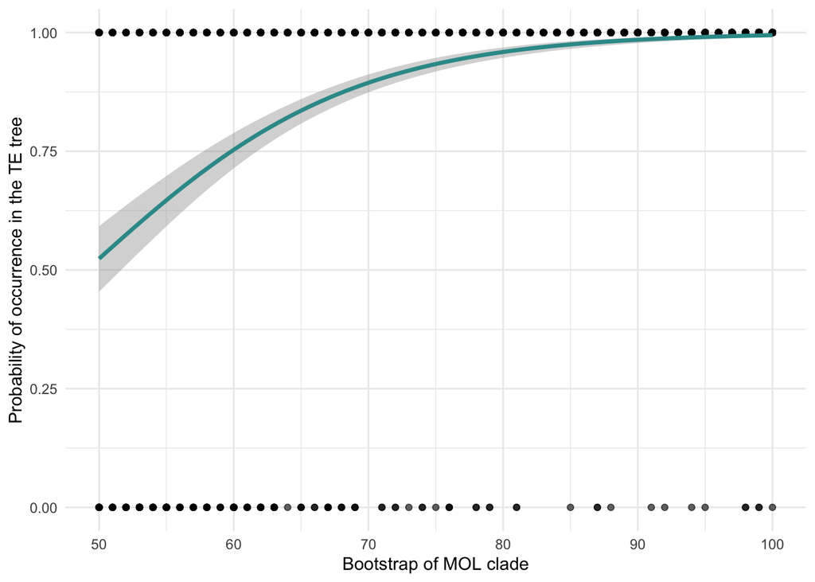

```r
# Plot the logistic regression curve with ggplot2
ggplot(MPlogistic, aes(x = support_tree1, y = occurrence_tree2)) +
  geom_point(alpha = 0.6) +  # Plot the data points
  geom_smooth(method = "glm", method.args = list(family = "binomial"),
              color = "#339999", size = 1.2) +  # Logistic regression curve
  labs(x = "Bootstrap of MOL clade", y = "Probability of occurrence in the TE tree") +
  theme_minimal()
```

```r
# B) ML ASC
# Perform logistic regression
mlasc_logistic_result <- glm(occurrence_tree2 ~ support_tree1, data = MLASClogistic, family = binomial)
# Print a summary of the model
summary(mlasc_logistic_result)
```

```
##
## Call:
## glm(formula = occurrence_tree2 ~ support_tree1, family = binomial,
##     data = MLASClogistic)
##
## Deviance Residuals:
##     Min       1Q   Median       3Q      Max
## -2.4572   0.3165   0.3165   0.3526   1.4992
##
## Coefficients:
##                Estimate Std. Error z value Pr(>|z|)
## (Intercept)   -4.430058   0.325259  -13.62   <2e-16 ***
## support_tree1  0.073989   0.003812   19.41   <2e-16 ***
## ---
## Signif. codes:  0 '***' 0.001 '**' 0.01 '*' 0.05 '.' 0.1 ' ' 1
##
## (Dispersion parameter for binomial family taken to be 1)
##
##     Null deviance: 2109.8  on 3041  degrees of freedom
## Residual deviance: 1717.1  on 3040  degrees of freedom
## AIC: 1721.1
##
## Number of Fisher Scoring iterations: 5
```

```r
# Calculate 95% confidence intervals for the coefficients
confint(mlasc_logistic_result)
```

```
##                     2.5 %      97.5 %
## (Intercept)   -5.07166824 -3.79573167
## support_tree1  0.06658111  0.08153574
```

```r
# Interpretation
exp(mlasc_logistic_result$coefficients[[2]]) # If coefficient is 0.06 and exp(0.09) is 1.06, then the each unit of 1% bootstrap in MOL clade increases the chance of the occurrence of this clade in TE by 6%
```

```
## [1] 1.076795
```

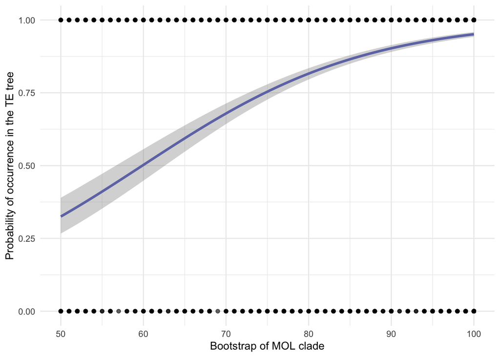

```r
# Plot the logistic regression curve with ggplot2
ggplot(MLASClogistic, aes(x = support_tree1, y = occurrence_tree2)) +
  geom_point(alpha = 0.6) +  # Plot the data points
  geom_smooth(method = "glm", method.args = list(family = "binomial"),
              color = "#6f77b4", size = 1.2) +  # Logistic regression curve
  labs(x = "Bootstrap of MOL clade", y = "Probability of occurrence in the TE tree") +
  theme_minimal()
```

```r
# C) ML noASC
# Perform logistic regression
mlnoasc_logistic_result <- glm(occurrence_tree2 ~ support_tree1, data = MLnoASClogistic, family = binomial)
# Print a summary of the model
summary(mlnoasc_logistic_result)
```

```
##
## Call:
## glm(formula = occurrence_tree2 ~ support_tree1, family = binomial,
##     data = MLnoASClogistic)
##
## Deviance Residuals:
##     Min       1Q   Median       3Q      Max
## -2.4383   0.3241   0.3241   0.3577   1.5155
##
## Coefficients:
##                Estimate Std. Error z value Pr(>|z|)
## (Intercept)   -4.453895   0.323737  -13.76   <2e-16 ***
## support_tree1  0.073739   0.003782   19.50   <2e-16 ***
## ---
## Signif. codes:  0 '***' 0.001 '**' 0.01 '*' 0.05 '.' 0.1 ' ' 1
##
## (Dispersion parameter for binomial family taken to be 1)
##
##     Null deviance: 2155.4  on 3041  degrees of freedom
## Residual deviance: 1758.1  on 3040  degrees of freedom
## AIC: 1762.1
##
## Number of Fisher Scoring iterations: 5
```

```r
# Calculate 95% confidence intervals for the coefficients
confint(mlnoasc_logistic_result)
```

```
##                     2.5 %      97.5 %
## (Intercept)   -5.09263535 -3.82268959
## support_tree1  0.06639067  0.08122553
```

```r
# Interpretation
exp(mlnoasc_logistic_result$coefficients[[2]]) # If coefficient is 0.06 and exp(0.09) is 1.06, then the each unit of 1% bootstrap in MOL clade increases the chance of the occurrence of this clade in TE by 6%
```

```
## [1] 1.076526
```

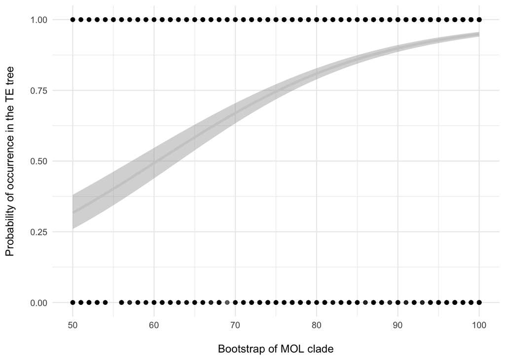

```r
# Plot the logistic regression curve with ggplot2
ggplot(MLnoASClogistic, aes(x = support_tree1, y = occurrence_tree2)) +
  geom_point(alpha = 0.6) +  # Plot the data points
  geom_smooth(method = "glm", method.args = list(family = "binomial"),
              color = "#cccccc", size = 1.2) +  # Logistic regression curve
  labs(x = "\nBootstrap of MOL clade", y = "Probability of occurrence in the TE tree\n") +
  theme_minimal()
```

## Q5.2 Extinct

```r
# Load data
df_q5 = read.csv("/Users/labanfibios/Desktop/Doutorado/Project/B2_TEvsMOL/GitHub/Dataset_R_q5_09-25_extinct.csv")
# Only keep >50% BS
df_q5 <- df_q5[df_q5$support_tree1 >= 50, ]

# Select MP
MPlogistic <- df_q5[df_q5$optimality == "MP", ]
# Select ML ASC
MLASClogistic <- df_q5[df_q5$optimality == "MLASC", ]
# Select ML no ASC
MLnoASClogistic <- df_q5[df_q5$optimality == "MLnoASC", ]
```

### Q5.2.1 Data exploration (Table S9)

```r
#############################
# EXPLORATORY DATA ANALYSES #
#############################

# A) MP
# Total number of MOL clades
nrow(MPlogistic)
```

```
## [1] 856
```

```r
# Shared clades
nrow(subset(MPlogistic, occurrence_tree2 == 1)) # Number of shared clades
```

```
## [1] 684
```

```r
nrow(subset(MPlogistic, occurrence_tree2 == 1))/nrow(MPlogistic) # Proportion shared/total
```

```
## [1] 0.7990654
```

```r
mean(subset(MPlogistic, occurrence_tree2 == 1)$support_tree1) # BS mean
```

```
## [1] 89.35234
```

```r
sd(subset(MPlogistic, occurrence_tree2 == 1)$support_tree1) # BS sd
```

```
## [1] 14.80839
```

```r
range(subset(MPlogistic, occurrence_tree2 == 1)$support_tree1) # BS range
```

```
## [1]  50 100
```

```r
# Unique clades for MOL
nrow(subset(MPlogistic, occurrence_tree2 == 0)) # Number of unique clades for MOL
```

```
## [1] 172
```

```r
nrow(subset(MPlogistic, occurrence_tree2 == 0))/nrow(MPlogistic) # Proportion uniqueMOL/total
```

```
## [1] 0.2009346
```

```r
mean(subset(MPlogistic, occurrence_tree2 == 0)$support_tree1) # BS mean
```

```
## [1] 81.45349
```

```r
sd(subset(MPlogistic, occurrence_tree2 == 0)$support_tree1) # BS sd
```

```
## [1] 18.88293
```

```r
range(subset(MPlogistic, occurrence_tree2 == 0)$support_tree1) # BS range
```

```
## [1]  50 100
```

```r
# MOL clades with BS <75 present in TE
nrow(subset(MPlogistic, support_tree1 < 75 & occurrence_tree2 == 1)) # Number of MOL clades with BS <75 that occur in TE
```

```
## [1] 128
```

```r
nrow(subset(MPlogistic, support_tree1 < 75 & occurrence_tree2 == 1))/nrow(MPlogistic) # Proportion of MOL clades with BS <75 that occur in TE
```

```
## [1] 0.1495327
```

```r
# MOL clades with BS >90 absent in TE
nrow(subset(MPlogistic, support_tree1 > 90 & occurrence_tree2 == 0)) # Number of MOL lades with BS >90 absent in TE
```

```
## [1] 83
```

```r
nrow(subset(MPlogistic, support_tree1 > 90 & occurrence_tree2 == 0))/nrow(MPlogistic) # Proportion of MOL lades with BS >90 absent in TE
```

```
## [1] 0.09696262
```

```r
nrow(subset(MPlogistic, support_tree1 == 100 & occurrence_tree2 == 0)) # MOL clades with BS = 100 absent in TE
```

```
## [1] 46
```

```r
# B) ML ASC
# Total number of MOL clades
nrow(MLASClogistic)
```

```
## [1] 1051
```

```r
# Shared clades
nrow(subset(MLASClogistic, occurrence_tree2 == 1)) # Number of shared clades
```

```
## [1] 922
```

```r
nrow(subset(MLASClogistic, occurrence_tree2 == 1))/nrow(MLASClogistic) # Proportion shared/total
```

```
## [1] 0.8772598
```

```r
mean(subset(MLASClogistic, occurrence_tree2 == 1)$support_tree1) # BS mean
```

```
## [1] 93.38069
```

```r
sd(subset(MLASClogistic, occurrence_tree2 == 1)$support_tree1) # BS sd
```

```
## [1] 12.28672
```

```r
range(subset(MLASClogistic, occurrence_tree2 == 1)$support_tree1) # BS range
```

```
## [1]  50 100
```

```r
# Unique clades for MOL
nrow(subset(MLASClogistic, occurrence_tree2 == 0)) # Number of unique clades for MOL
```

```
## [1] 129
```

```r
nrow(subset(MLASClogistic, occurrence_tree2 == 0))/nrow(MLASClogistic) # Proportion uniqueMOL/total
```

```
## [1] 0.1227402
```

```r
mean(subset(MLASClogistic, occurrence_tree2 == 0)$support_tree1) # BS mean
```

```
## [1] 81.31008
```

```r
sd(subset(MLASClogistic, occurrence_tree2 == 0)$support_tree1) # BS sd
```

```
## [1] 17.18184
```

```r
range(subset(MLASClogistic, occurrence_tree2 == 0)$support_tree1) # BS range
```

```
## [1]  50 100
```

```r
# MOL clades with BS <75 present in TE
nrow(subset(MLASClogistic, support_tree1 < 75 & occurrence_tree2 == 1)) # Number of MOL clades with BS <75 that occur in TE
```

```
## [1] 100
```

```r
nrow(subset(MLASClogistic, support_tree1 < 75 & occurrence_tree2 == 1))/nrow(MLASClogistic) # Proportion of MOL clades with BS <75 that occur in TE
```

```
## [1] 0.09514748
```

```r
# MOL clades with BS >90 absent in TE
nrow(subset(MLASClogistic, support_tree1 > 90 & occurrence_tree2 == 0)) # Number of MOL lades with BS >90 absent in TE
```

```
## [1] 51
```

```r
nrow(subset(MLASClogistic, support_tree1 > 90 & occurrence_tree2 == 0))/nrow(MLASClogistic) # Proportion of MOL lades with BS >90 absent in TE
```

```
## [1] 0.04852521
```

```r
nrow(subset(MLASClogistic, support_tree1 == 100 & occurrence_tree2 == 0)) # MOL clades with BS = 100 absent in TE
```

```
## [1] 28
```

```r
# C) ML noASC
# Total number of MOL clades
nrow(MLnoASClogistic)
```

```
## [1] 1051
```

```r
# Shared clades
nrow(subset(MLnoASClogistic, occurrence_tree2 == 1)) # Number of shared clades
```

```
## [1] 928
```

```r
nrow(subset(MLnoASClogistic, occurrence_tree2 == 1))/nrow(MLnoASClogistic) # Proportion shared/total
```

```
## [1] 0.8829686
```

```r
mean(subset(MLnoASClogistic, occurrence_tree2 == 1)$support_tree1) # BS mean
```

```
## [1] 93.41379
```

```r
sd(subset(MLnoASClogistic, occurrence_tree2 == 1)$support_tree1) # BS sd
```

```
## [1] 12.27363
```

```r
range(subset(MLnoASClogistic, occurrence_tree2 == 1)$support_tree1) # BS range
```

```
## [1]  50 100
```

```r
# Unique clades for MOL
nrow(subset(MLnoASClogistic, occurrence_tree2 == 0)) # Number of unique clades for MOL
```

```
## [1] 123
```

```r
nrow(subset(MLnoASClogistic, occurrence_tree2 == 0))/nrow(MLnoASClogistic) # Proportion uniqueMOL/total
```

```
## [1] 0.1170314
```

```r
mean(subset(MLnoASClogistic, occurrence_tree2 == 0)$support_tree1) # BS mean
```

```
## [1] 80.47154
```

```r
sd(subset(MLnoASClogistic, occurrence_tree2 == 0)$support_tree1) # BS sd
```

```
## [1] 17.05263
```

```r
range(subset(MLnoASClogistic, occurrence_tree2 == 0)$support_tree1) # BS range
```

```
## [1]  50 100
```

```r
# MOL clades with BS <75 present in TE
nrow(subset(MLnoASClogistic, support_tree1 < 75 & occurrence_tree2 == 1)) # Number of MOL clades with BS <75 that occur in TE
```

```
## [1] 101
```

```r
nrow(subset(MLnoASClogistic, support_tree1 < 75 & occurrence_tree2 == 1))/nrow(MLnoASClogistic) # Proportion of MOL clades with BS <75 that occur in TE
```

```
## [1] 0.09609895
```

```r
# MOL clades with BS >90 absent in TE
nrow(subset(MLnoASClogistic, support_tree1 > 90 & occurrence_tree2 == 0)) # Number of MOL lades with BS >90 absent in TE
```

```
## [1] 45
```

```r
nrow(subset(MLnoASClogistic, support_tree1 > 90 & occurrence_tree2 == 0))/nrow(MLnoASClogistic) # Proportion of MOL lades with BS >90 absent in TE
```

```
## [1] 0.04281637
```

```r
nrow(subset(MLnoASClogistic, support_tree1 == 100 & occurrence_tree2 == 0)) # MOL clades with BS = 100 absent in TE
```

```
## [1] 23
```

### Q5.2.2 Logistic regressions (Table 5)

```r
#######################
# LOGISTIC REGRESSION #
#######################

# A) MP
# Perform logistic regression
mp_logistic_result <- glm(occurrence_tree2 ~ support_tree1, data = MPlogistic, family = binomial)
# Print a summary of the model
summary(mp_logistic_result)
```

```
##
## Call:
## glm(formula = occurrence_tree2 ~ support_tree1, family = binomial,
##     data = MPlogistic)
##
## Deviance Residuals:
##     Min       1Q   Median       3Q      Max
## -1.9688   0.5576   0.5649   0.6585   1.0203
##
## Coefficients:
##                Estimate Std. Error z value Pr(>|z|)
## (Intercept)   -1.019656   0.424118  -2.404   0.0162 *
## support_tree1  0.028022   0.004964   5.645 1.65e-08 ***
## ---
## Signif. codes:  0 '***' 0.001 '**' 0.01 '*' 0.05 '.' 0.1 ' ' 1
##
## (Dispersion parameter for binomial family taken to be 1)
##
##     Null deviance: 858.90  on 855  degrees of freedom
## Residual deviance: 827.77  on 854  degrees of freedom
## AIC: 831.77
##
## Number of Fisher Scoring iterations: 4
```

```r
# Calculate 95% confidence intervals for the coefficients
confint(mp_logistic_result)
```

```
##                     2.5 %      97.5 %
## (Intercept)   -1.84633178 -0.18118881
## support_tree1  0.01827818  0.03776364
```

```r
# Interpretation
exp(mp_logistic_result$coefficients[[2]]) # If coefficient is 0.09 and exp(0.09) is 1.1, then each unit of 1% bootstrap in MOL clade increases the chance of the occurrence of this clade in TE by 10%
```

```
## [1] 1.028418
```

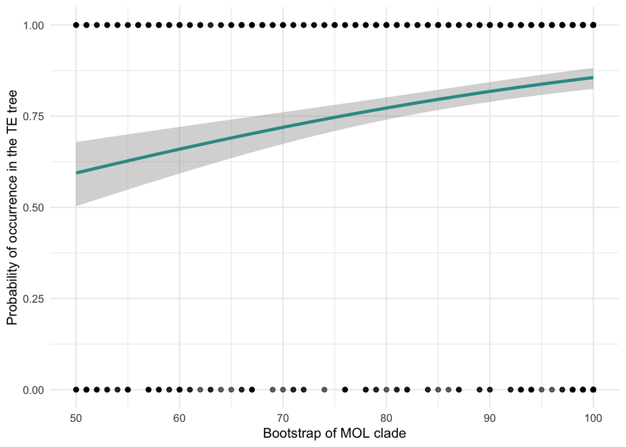

```r
# Plot the logistic regression curve with ggplot2
ggplot(MPlogistic, aes(x = support_tree1, y = occurrence_tree2)) +
  geom_point(alpha = 0.6) +  # Plot the data points
  geom_smooth(method = "glm", method.args = list(family = "binomial"),
              color = "#339999", size = 1.2) +  # Logistic regression curve
  labs(x = "Bootstrap of MOL clade", y = "Probability of occurrence in the TE tree") +
  theme_minimal()
```

```r
# B) ML ASC
# Perform logistic regression
mlasc_logistic_result <- glm(occurrence_tree2 ~ support_tree1, data = MLASClogistic, family = binomial)
# Print a summary of the model
summary(mlasc_logistic_result)
```

```
##
## Call:
## glm(formula = occurrence_tree2 ~ support_tree1, family = binomial,
##     data = MLASClogistic)
##
## Deviance Residuals:
##     Min       1Q   Median       3Q      Max
## -2.2918   0.3876   0.3876   0.4261   1.1437
##
## Coefficients:
##                Estimate Std. Error z value Pr(>|z|)
## (Intercept)   -2.391394   0.491268  -4.868 1.13e-06 ***
## support_tree1  0.049425   0.005696   8.677  < 2e-16 ***
## ---
## Signif. codes:  0 '***' 0.001 '**' 0.01 '*' 0.05 '.' 0.1 ' ' 1
##
## (Dispersion parameter for binomial family taken to be 1)
##
##     Null deviance: 782.68  on 1050  degrees of freedom
## Residual deviance: 710.88  on 1049  degrees of freedom
## AIC: 714.88
##
## Number of Fisher Scoring iterations: 5
```

```r
# Calculate 95% confidence intervals for the coefficients
confint(mlasc_logistic_result)
```

```
##                     2.5 %      97.5 %
## (Intercept)   -3.35182192 -1.42198247
## support_tree1  0.03827527  0.06064464
```

```r
# Interpretation
exp(mlasc_logistic_result$coefficients[[2]]) # If coefficient is 0.06 and exp(0.09) is 1.06, then the each unit of 1% bootstrap in MOL clade increases the chance of the occurrence of this clade in TE by 6%
```

```
## [1] 1.050667
```

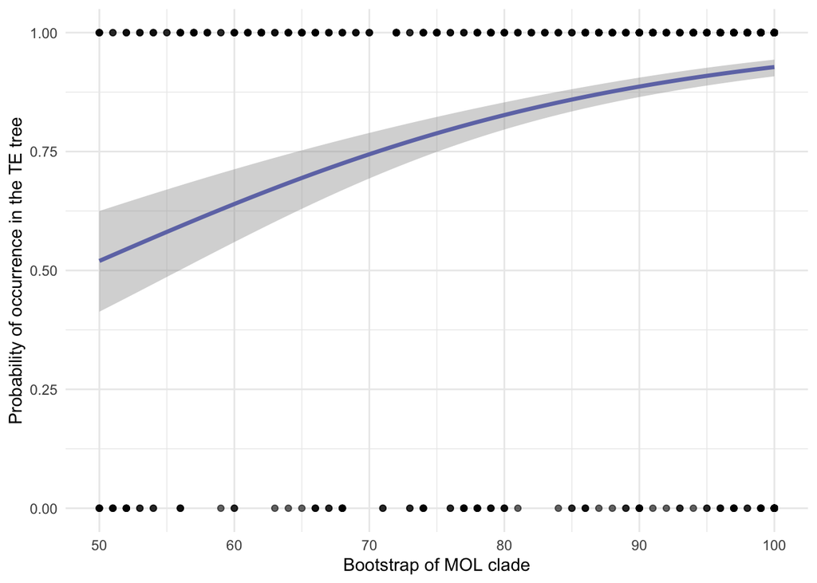

```r
# Plot the logistic regression curve with ggplot2
ggplot(MLASClogistic, aes(x = support_tree1, y = occurrence_tree2)) +
  geom_point(alpha = 0.6) +  # Plot the data points
  geom_smooth(method = "glm", method.args = list(family = "binomial"),
              color = "#6f77b4", size = 1.2) +  # Logistic regression curve
  labs(x = "Bootstrap of MOL clade", y = "Probability of occurrence in the TE tree") +
  theme_minimal()
```

```r
# C) ML noASC
# Perform logistic regression
mlnoasc_logistic_result <- glm(occurrence_tree2 ~ support_tree1, data = MLnoASClogistic, family = binomial)
# Print a summary of the model
summary(mlnoasc_logistic_result)
```

```
##
## Call:
## glm(formula = occurrence_tree2 ~ support_tree1, family = binomial,
##     data = MLnoASClogistic)
##
## Deviance Residuals:
##     Min       1Q   Median       3Q      Max
## -2.3339   0.3685   0.3685   0.4075   1.1594
##
## Coefficients:
##                Estimate Std. Error z value Pr(>|z|)
## (Intercept)   -2.570347   0.495902  -5.183 2.18e-07 ***
## support_tree1  0.052260   0.005791   9.024  < 2e-16 ***
## ---
## Signif. codes:  0 '***' 0.001 '**' 0.01 '*' 0.05 '.' 0.1 ' ' 1
##
## (Dispersion parameter for binomial family taken to be 1)
##
##     Null deviance: 758.76  on 1050  degrees of freedom
## Residual deviance: 680.57  on 1049  degrees of freedom
## AIC: 684.57
##
## Number of Fisher Scoring iterations: 5
```

```r
# Calculate 95% confidence intervals for the coefficients
confint(mlnoasc_logistic_result)
```

```
##                     2.5 %      97.5 %
## (Intercept)   -3.54088252 -1.59280955
## support_tree1  0.04094112  0.06368417
```

```r
# Interpretation
exp(mlnoasc_logistic_result$coefficients[[2]]) # If coefficient is 0.06 and exp(0.09) is 1.06, then the each unit of 1% bootstrap in MOL clade increases the chance of the occurrence of this clade in TE by 6%
```

```
## [1] 1.053649
```

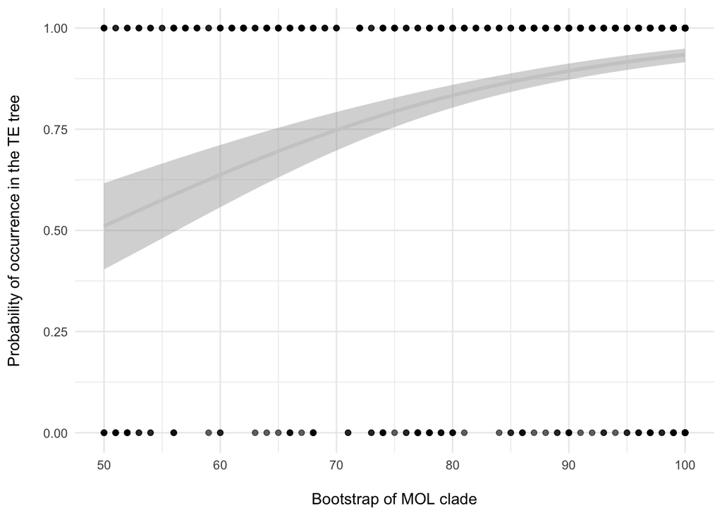

```r
# Plot the logistic regression curve with ggplot2
ggplot(MLnoASClogistic, aes(x = support_tree1, y = occurrence_tree2)) +
  geom_point(alpha = 0.6) +  # Plot the data points
  geom_smooth(method = "glm", method.args = list(family = "binomial"),
              color = "#cccccc", size = 1.2) +  # Logistic regression curve
  labs(x = "\nBootstrap of MOL clade", y = "Probability of occurrence in the TE tree\n") +
  theme_minimal()
```